# 语言学课堂 ——当哲学家遇到认知语言学

〔日〕西村义树 野矢茂树 著  
郑若曦 李菲 译 潘钧 审译

商务印书馆（The Commercial Press）  
2019年·北京

> **一位热爱语言学的哲学家，向一位认知语言学家学习语言学的奇妙旅程**

> 本书的两位作者，西村义树教授和野矢茂树教授，分别为日本第一学府东京大学的语言学教授和哲学教授。他们在各自的研究领域——认知语言学和语言哲学——均是享誉盛名的著名学者。本书采取的是哲学家作为学生向语言学家提问的形式，其实是一次认知语言学与语言哲学的亲密对话，特别是在语词的意义与指称、范畴理论、隐喻理论、因果关系等方面的对接与碰撞尤其引人注目。

## 图书在版编目（CIP）数据

语言学课堂：当哲学家遇到认知语言学／（日）西村义树，（日）野矢茂树著；郑若曦，李菲译．—北京：商务印书馆，2019  
ISBN 978-7-100-16649-2

权利保留，侵权必究。

语言学课堂  
——当哲学家遇到认知语言学  
〔日〕西村义树 野矢茂树 著  
郑若曦 李菲 译 潘钧 审译

## 中文版序

本书的日文原版，自2013年6月出版发行至今，受到了对语言感兴趣的很多日本读者的热情欢迎。这无论对于我们作者还是编辑来说，都是意料之外的惊喜。当然，这与本书采用的是容易让人亲近的对谈形式而非论文体有关。但毕竟这是一本以“语言学”为书名的、内容上高度专业的书，所以它能够如此受到关注还是很让人意外的。之所以会发生这样的奇迹（至少对于作者之一的我来说这真的是个奇迹），我想应该和“前言”和“后记”中提到的本书非常特别的成书过程有关。具体是怎样成书的，还望大家去阅读本书的“前言”和“后记”。总之，我想正是因为作者、编辑以及各位合作者都有着“无论如何都要做一本好书”的强烈信念，且为之付出了最大的努力，才共同创造了这样的奇迹吧。

中文版的两位译者，对我来说都是不可或缺的业界同行。读书期间，她们在东京大学和庆应义塾大学长年上我的课，我也全力指导了她们的论文和研究发表。而现在，她们都是活跃在认知语言学（也就是本书的主要内容）的第一线的学者。她们两位不光是出色的语言学研究者，在我从1993年以来指导过的无数以日语为研究对象的留学生中，她们的日语能力也是出类拔萃的。无论是在日常会话中，还是在学术研讨和论文写作中，她们的日语都达到了几近母语者的程度。因此，能够有这样两位译者来深入而准确地理解原书的思想并将其译成中文，对于我们作者来说，更准确地说是对于原书来说，真的是最大的幸运。两位译者在翻译的过程中，对原书的内容哪怕有一点点疑问，都会不厌其烦地逐一来向我确认，并和我探讨直到疑问解决。我从心里感谢她们的付出。同时，也非常感谢潘钧老师在翻译的每一个阶段认真、负责、专业、耐心的审译工作。我衷心希望他们的这份努力和付出能够使本书在中国再次缔造奇迹。

二〇一八年三月

作者代表：西村义树

## 前言

本书虽然采用的是对谈形式，但并非普通的对谈。西村义树先生是老师，而我（野矢）是学生。下面我们将会为大家带来六节有关“认知语言学”的课。在开始之前，我想先谈一谈我向西村先生提出这个出书计划的原因。

我的专业是哲学，主要从“他者”的角度去探讨各种问题，其中也不乏语言哲学式的考察。但我的研究，也常常会超出传统语言哲学的范畴。当我嘀咕着“这么解释能行吗？ ”或者安慰自己“这么解释自己也觉得还挺不错”的时候，我并不知道，在这个过程中我已经不知不觉间闯入了一个名为“认知语言学”的崭新的语言学领域中。

认知语言学——对于很多读者来说，或许还是一个少有耳闻的学术领域。本书正是为这样的读者编写的至于它到底是一个怎样的领域，还望读者们在后面的课程中去细细体会。在这里，我只预先透露一下它的研究方向：这是一门从我们对事物的认识、感受、思考方式以及生活、行为方式等角度来研究语言的学科。这么一说的话，大家恐怕都会觉得这个研究方向很合理。可迄今为止，还没有完全从这个方向来考察语义和语法的语言学研究。我所熟悉的传统的语言哲学，在这一点上也是一样的。而对于这种传统的语言哲学，我总是感到有些束手束脚。

后来，当我了解到原来还有认知语言学这样一个充满魅力的领域，并对它的兴趣愈发浓厚的时候，我有幸认识了认知语言学的专家西村义树先生。因为有时候要在一起工作，我们便开始对各种问题进行交流。在交流中，西村先生给我展示的有关认知语言学的课题，真的，每一个都实在太有趣了。虽然现在我就心里痒痒，恨不得马上告诉大家都有什么样的有趣的问题，不过具体内容还是请大家自己去看吧。一言以蔽之，认知语言学聚焦的是那些我们平常不太在意的日常生活中的语言现象。在它的聚焦下，那些习以为常的语言现象也看起来不可思议了，让人不禁想去一探究竟。估计有这种冲动的不光是我一个人吧。分析对象虽然不乏英语的例子，但基本上是以日语为主的。日语，我自认为已经很熟悉了，因此想要解开其中的谜，按理来说并不需要新的知识。想到可以重新认识和思考自己非常熟悉的日语，抱着胳臂绞尽脑汁地去寻找答案，真是兴奋得不得了。

记得有一次，我和国语学家尾上圭介先生<sup>1</sup>聊天。我说：“语言学多好啊！有那么多有意思的课题。”听了我的话，尾上先生只是淡淡地说：“那你就做呗。”——他的语气和表情我至今都无法忘记。他大概是想说：你说什么呢！觉得有意思就做，就开始呗，不是很简单的事儿吗？我并不了解尾上先生的经历，但却能感觉到他身上散发着一种光芒，好像在说“咱就是这么走过来的”。

我不算是精力旺盛的人，如果现在开始语言学的研究，我会觉得，嗯，恐怕有点儿力不从心。不过同时又觉得，学习认知语言学应该是很开心的。正在矛盾之际，我打听到西村先生正准备出一本“新书”<sup>2</sup>。于是,便主动提出“以我上您的课的形式出这本书怎么样？”本书就是这样诞生的。这本书其实是我以公谋私的产物。是因为我自己想学认知语言学，才有了这个出书计划的。

就这样，在中央公论新社借给我们的会议室里，西村义树先生与一个颇为老成的学生开始了他们的认知语言学课。谁知这个学生不仅脑子慢，还反驳老师、爱挑老师的毛病，最后还开始讲起了自己的观点，实在是不好对付。都怪这个学生，讨论总是无法顺顺当当地进行，一会儿拐进了岔道，一会儿又开起了小差，谈得很是起劲，早把出书的事抛到了脑后。我们倒是聊得很开心，只是遗憾的是，等把我们的谈话录音记录下来后,才发现稿子的篇幅太长，需要大量删减。如果拿日本酒打比方的话，因为本书已经精减了整体的60%,剩下的可是高浓缩的“大吟醸”<sup>3</sup>。（为了让大家感受到一点现场的气氛，在本书最后的附录里，我们加进了一小部分几乎无删减的谈话记录。希望大家能够从中一窥我们充满活力而又毫无章法的课堂氛围）

正因为有这样的成书过程，我们相信，本书比任何入门书都能更好地把认知语言学的精神和理念传递给大家。当然，如果单论讲解是否条理清晰，肯定有别的更好的认知语言学的入门书。可我们是，不懂就止步，有了疑问就提问或反驳，老师也是大汗淋漓地忙着解答。认知语言学的一些核心观点，如果只是一讲就过的话，您的理解不一定深入；但通过一起参与我们的课堂，相信您的理解会更加透彻。我们的书还有一个令我感到自豪的地方，就是不仅学生是哲学家，老师也非常喜欢哲学，这一点也增添了本书的独特性。另外,我们还有一个藏在心底的野心，就是希望本书不单是一本入门书，还能让那些已经开始学习认知语言学的人，甚至是认知语言学的专家们也能从中获得灵感、找到新的方向。固然，野矢我只是学生，老师是西村先生，不过我想本书应该可以称得上是一本哲学家和认知语言学家共同完成的认知语言学的入门书。

二〇一三年春

野矢茂树

## 第一讲认知语言学的诞生

### 间接被动

野矢：认知语言学的诞生，是在上个世纪八十年代，还是七十年代？

西村：1987年，有两部书相继问世，可以说是最早介绍认知语言学的两部书吧。一部是乔治•雷可夫（George Lakoff）的 *Women, Fire, and Dangerous Things: What Categories Reveal about the Mind* （有中译本，《女人、火与危险事物：范畴显示的心智》，李葆嘉等译，世界图书出版公司）,另一部是罗纳德•兰盖克（Ronald Langacker）的 *Foundations of Cognitive Grammar* （二卷本著作的第一本，有中译本，《认知语法基础（第一卷）理论前提》，牛保义等译，北京大学出版社）。认知语言学就此诞生了。

野矢：这还真是一个很新的领域啊。我个人知道认知语言学还要更晚一些。在认知语言学诞生之前，语言学研究的主流是生成语法。说实话，生成语法在我看来，总是缺少一点魅力。可当我了解到还有认知语言学这么一个领域的时候，一下子就预感到它一定十分有趣。为了让读者们也能感受到“认知语言学似乎是很有趣的”，您能不能先举一个特别能体现认知语言学特点的具体例子呢？

西村：“间接被动”的例子怎么样？

野矢：这个问题，以前听您讲过，当时就觉得特别有意思。那就请您再讲一讲吧。

西村：“被动”，也就是“被动语态”（或“被动句”），这种语言现象可见于很多语言。而“间接被动”，是被动句中较为特殊的一类。这种被动形式虽然并非只见于日语，但在其他语言中确实相对少见，可以说在日语中体现得尤为明显。例如，「雨に降られちゃった（被雨下了）」这个句子，在日语里应该挺自然的吧。它的特殊之处在于，虽是被动句，却没有与之直接对应的主动句。如果是「太郎は花子に叱られた（太郎被花子骂了）」这样的被动句的话，我们马上就能想到与之直接对应的主动句「花子は太郎を叱った（花子骂太郎了）」。而「太郎は雨に降られた（太郎被雨下了）」这句话，我们却造不出以太郎为宾语的主动句。像这种没有主动句与之直接对应的被动句，我们称之为“间接被动”。

不过，话说起来，「雨に降られた（被雨下了）」在日语里虽然很自然，可是「財布に落ちられた（被钱包掉了）」呢？是不是依然还成立呢？

野矢：这个被动句，日语应该没法说吧。

西村：可是我听说，学日语的外国人学会了「雨に降られた（被雨下了）」这样的被动句后，就会以此类推地造出「昨日財布に落ちられました（昨天被钱包掉了）」这样的句子。当我们告诉他们日语不这样说后，他们便会问“为什么不行？”为什么「雨に降られた（被雨下了）」很自然，而「財布に落ちられた（被钱包掉了）」却不自然？说起来还真不好回答。而认知语言学就是要给这样的问题一个解释。

野矢：直觉上好像明白是怎么回事，可又说不清楚到底是什么原因。我虽然不是专家，倒也很想努力给它一个合理的解释。

刚才您说间接被动在日语里体现得尤为明显。那么，在其他语言，比如英语里，就看不到这样的现象吗？

西村：如果是「雨に降られた（被雨下了）」，尚且可以译成“I was rained on.”；可如果是「彼女に泣かれた（被女朋友哭了）」这样的间接被动，就肯定没法译成英语的被动句了。为什么日语和英语之间会有这样的差异，诸如此类的问题也是认知语言学的课题。

野矢：能不能让我这个外行也说说自己的看法呢？

西村：好的，请讲。

野矢：「泣かれた（被哭了）」或者「雨に降られた（被雨下了）」这种表达方式，总给人一种很不如意的感觉。如果是一心期盼着下雨，结果如愿以偿下了雨的话，是不会说「雨に降られた（被雨下了）」的。另外，说「泣かれた（被哭了）」或者「雨に降られた（被雨下了）」的时候，总有一种自己已然无能为力的、“放弃”的感觉。是不是这种「受苦（不如意）」和「諦念（放弃）」的感觉，诱发了我们去使用被动句呢？

西村：没错，大概就是这样。

野矢：可是，光是「受苦（不如意）」和「諦念（放弃）」，我觉得还不够。比如，「おならに出られた（被屁放了）」这个句子肯定很别扭（笑）。虽然大家都不愿意在人前放屁，但如果放了也没办法。不是有句话叫「出もの腫れもの、所嫌わず（放屁生疮，不择地方）」嘛。我们也不能说「にきびに出られた（被粉刺长出来了）」。我认为这是因为，使用被动句的时候，我们需要从（造成「受苦（不如意）」和「諦念（放弃）」感的）事物中读取出一种「他者性（他异性）」。屁和粉刺都是自己的东西，没有「他者性（他异性）」。也就是说，使用间接被动句的条件有三个：1）「受苦（不如意）」2）「諦念（放弃）」3）「他者性（他异性）」。这些条件都满足了，我们就可以使用间接被动；如果其中有某个条件没有满足，使用间接被动就不自然。

西村：正因为如此，“间接被动”其实还被称作“受害被动”。之所以「財布に落ちられた（被钱包掉了）」这个句子让人觉得别扭，大概是因为一般人都会觉得自己的钱包自己应该是可以管理好的吧。

野矢：这算不算是认知语言学式的考察？

西村：对，这就是认知语言学式的考察。认知语言学的特点就是，不要把语言的问题仅仅狭隘地局限在语言范畴内，而要把语言和我们对事物的看法及态度联系起来考虑。

野矢：外行就是这点不好，我又忍不住想东想西了。我甚至在想，日语里频繁地使用间接被动是不是反映了日本人的某种精神特质。比如像「雨に降られた（被雨下了）」，就是从自然现象中感受到了「他者性（他异性）」，于是，用被动句来表达一种抱怨的情绪，我觉得这是非常符合日本人的特质的。

西村：或许是吧。只是，美国人也会给飓风起名字。那是不是可以说，美国人也从自然现象中感受到了「他者性（他异性）」呢？

野矢：哦，也对。看来还是不能轻易下结论。可是看了 “受害被动”的例子后，我还是觉得这似乎和日本人特有的某种心理有关。

西村：其实，认知语言学正在重新提倡语言相对主义的观点。语言相对主义认为，语言之间的差异也反映了说话人在思考方式、行为方式上的差异。

野矢：从哲学立场上来说，我继承的是相对主义。这也是认知语言学吸引我的原因之一。

### 语言学是一门怎样的学科

野矢：那，咱们进入正题吧。

在请教“什么是认知语言学”之前，能不能先请教一个更基本、更初级的问题——“什么是语言学”。

西村：还真是一个很基本的问题啊（笑）。说起来，现代语言学的历史应该可以追溯到1916年出版的索绪尔（Ferdinand de Saussure）的著作 *Cours de linguistique générale*（有中译本，《普通语言学教程》，高名凯译，商务印书馆）。虽然在索绪尔之前，也有过关于语言的研究，但那些研究都是以历史性研究为主的。当时的许多学者发现.欧洲的很多语言都与梵语存在着系统性的对应关系，于是搞清楚这些对应关系便成了当时语言研究的核心课题。比如，如果某个语言被认定为其他一系列语言共通的起源，那就要考察这些语言是如何从这个共通的起源派生出来的（包括语音层面的派生）。而派生的过程是有一定的规律的，因此还要弄清这些规律是什么。

索绪尔的出现大大地改变了这个潮流。他把之前语言学所采用的、按时间轴考察语言的研究方式称为“历时”。与此相对，把考察同一时期语言状态的研究方式称为“共时”，并提出应该先做共时的研究。他还指出，即使是历时的研究，也应该将其视作共时不断积淀的结果。这种研究潮流，从索绪尔开始一直持续到了现在。

野矢：为什么相比历时，要更注重共时呢？

西村：举例来说，即便是研究一个词的历史演变，也不能只看这个词本身，还应该关注语言整体。

野矢：是不是可以这样理解：比如“红”这个词，它的语义并不是独立存在的，而是在与“蓝”、“黄”等其他词的对比中获得的。另外，要想搞懂“红”这个词的语义，还必须关注它与所处的句子环境之间的关系。

西村：是的。所以说，单独一个词或短语还谈不上有没有语义，必须要先把整个语言作为一个体系或一个有机整体去把握才可以。也就是说，要想从历时的角度去研究“红”这个词，就要先从共时角度出发，在语言这个有机整体中去把握它。

野矢：即便是考察语言的历时特征，也要先从共时的角度对语言整体进行把握，这种研究思路在索绪尔以前没有出现过吗？

西村：虽然不能说完全没有，但可以说，真正让这种研究思路引领现代语言学发展方向的是索绪尔。

野矢：原来如此。继索绪尔之后，“语言”第一次作为一个有机整体，成为了语言学的研究对象。这就是为什么称其为“现代语言学鼻祖”的原因吧。简言之，语言学是一门“将语言作为一个有机整体进行研究的学科”。

西村：而乔姆斯基(Noam Chomsky )之后的现代语言学，在承认语言是一个有机整体的基础上又提出了下一个课题：我们使用语言时，需要凭借哪些知识？无论是乔姆斯基的生成语法，还是在反对生成语法的基础上建立的认知语言学，在这一点上都是相同的。

野矢：“认知语言学”在“语言学”前面又加上了“认知”二字。那么，认知语言学研究的是一种什么样的语言学呢？认知语言学和单纯的语言学有哪些不同？

西村：“认知”，在这里可以大体理解为“人的心理活动机制”。不过，光看这一点，认知语言学与生成语法的区别还不够清楚。认知语言学是在质疑和批判生成语法的过程中诞生的，所以要想说清楚认知语言学的特征，最好先简单介绍一下生成语法。

野矢：话虽如此，生成语法的很多东西还是太过晦涩难懂。您就简单介绍一下对于理解认知语言学有必要的那部分吧。

### 乔姆斯基的革命

西村：生成语法是乔姆斯基于上世纪五十年代建立的语言理论，可谓语言学界的一大变革。之所以说是一大变革，正是因为他把语言看作人类心理活动的一部分，并明确指出要把语言作为心理层面上的问题来考察。于是，像“我们使用语言时凭借的是哪些知识”、“语言习得依靠的是什么样的心理机制”等问题，便成为了重要的研究课题。

野矢：这场变革之前的语言学，应该就是索绪尔式的语言学，或者说是结构主义语言学了吧。而乔姆斯基彻底改变了这种局面，是这样吗？

西村：索绪尔自己并没有使用结构主义这个词，是后来的人将他的研究归类到结构主义语言学的。在索绪尔之后乔姆斯基之前的这一段时间，根据地域的不同出现了几个流派。除了以索绪尔所在的日内瓦大学为中心的日内瓦学派外，还有哥本哈根学派、布拉格学派<sup>4</sup>等。另外，还有一个美国结构主义语言学派，至于它与索绪尔的理论之间有什么联系，光这一个问题就可以写出很厚的一本书来。

我们现在只说美国结构主义语言学。当时美国的土著语言也就是美洲印第安人的语言中，有很多都正濒临灭种的危机，很多人都想把它们记录下来。可是，这些土著语言谁也没有研究过，它们和那些广为人知的语言相比差异很大，应该如何研究它们呢？应该设计一个什么样的理论框架呢？美国结构主义语言学就是在这样的探索中诞生的。

野矢：而乔姆斯基，正是和这个美国结构主义语言学发生了正面交锋。

西村：没错。美国结构主义语言学的核心人物是布龙菲尔德(Leonard Bloomfield),他于1933年发表的*Language*（有中译本，《语言论》，袁家骅等译，商务印书馆)，在当时的美国被视作语言学界的圣经。而这本书的理论基础，是行为主义心理学。

野矢：既然理论基础是行为主义，那么方法论上是“只研究可以观察到的行为”吗？也就是说，只考察从第三者的角度可以观察到的语言行为。

西村：是的。乔姆斯基的理论，就是从反驳这一点开始的。生成语法创立的初衷，正是因为与上述基于行为主义的语言理论在几个重要问题上出现了对立。

乔姆斯基曾写过一篇书评，强烈批评行为主义心理学的核心人物斯金纳（B. F. Skinner）的著作 *Verbal Behavior*（1957）。因为这篇书评发表在了美国语言学会的会刊*Language*上，也受到了来自语言学之外领域的关注。斯金纳的观点是，可以用“刺激-反应”模式来解释包括语言习得在内的各种语言行为；但乔姆斯基强烈反对这个观点，他认为用这种模式根本无法解释人类语言的创造性。毕竟对于乔姆斯基来说，创造性才是人类语言的特点嘛。

野矢：能不能再详细说说“语言的创造性” ？

西村：乔姆斯基特别注意到：只要是母语，我们总是可以新造出无限符合语法的句子；另外，只要在语法上正确，即使是第一次看到或听到的句子，我们也可以充分地理解句义。理论上讲，人们能够造出的句子和能理解的句子是无限的。而我们需要弄清的是，这种创造性得以产生的机制。乔姆斯基认为，在这个问题上行为主义无能为力，所以他就创建了生成语法。

野矢：对于斯金纳这一派来说，研究对象只限于刺激、反应，以及其中的规律。具体到语言研究，就是只考察在什么样的状况下有什么样的语言行为，并提取其中的规律。打个比方，就是只关心往自动售货机里放多少钱、按哪个按钮，就可以买到什么，而不关心自动售货机的内部构造，认为那就是一个黑匣子。这就是行为主义的思维方式吧。

而乔姆斯基却与之相反，认为必须要打开这个黑匣子。

西村：美国结构主义语言学认为，打开这个黑匣子、探索其中的机制是犯规的。因为他们觉得，这不是科学能够管辖的范畴，设立这样的课题本身就不科学。可是，乔姆斯基却指出，弄清其中的机制才是语言学家真正应该做的。

野矢：不过，乔姆斯基并不是要让语言学成为一个超越科学范畴的学科。他提倡的是要在科学研究的范畴内，弄清语言创造性的机制，对吧？

我想我基本弄清楚乔姆斯基的变革体现在哪些方面了。那么，接下来，认知语言学又与生成语法在哪些方面产生了对立呢？

### 生成语义学的失败

西村：认知语言学，是在继承乔姆斯基开创的这一潮流的基础上诞生的。生成语法的创始人只有乔姆斯基一人，可说起认知语言学的创始人，却可以举出三四个人的名字。认知语言学的创始人中最知名的，雷可夫可以算一位。我先介绍一下他的研究。雷可夫虽然最初做的是生成语法的研究，但因为对某段时期之后的乔姆斯基的生成语法产生了不满，于是从上世纪六十年代中期开始转而全力提倡“生成语义学”的思想。一般认为，“生成语义学”与生成语法是对立的，因此为了区别二者，乔姆斯基的理论有时又被称作“解释语义学”。

野矢：为什么特意把乔姆斯基这一派的生成语法改称为“解释语义学”呢？

西村：因为生成语法本来的研究重心是句法学。

野矢：句法学研究的是用单词和短语构建句子时的组合规则。比如，“花子特别喜欢太郎”是一个合法的句子，但“花子红太郎”、“最喜欢太郎花子”则都不是合法的句子。像这样对单词和短语的组合方式进行考察的领域，就是句法学。

西村：没错。相对于句法学，语义学探讨的是词、短语、句子的意思是怎样产生的。生成语法是很严格地区分句法学和语义学的。他们认为一个句子通过句法规则组建起来之后，要施加另外的规则，才能得到对这个句子的语义解释。大概就是因为这个，生成语法才被称作“解释语义学”的吧。

野矢：是生成语法只研究句法学，语义学另属别的研究领域呢？还是在生成语法的研究中，本来就有句法学和语义学这两部分呢？

西村：我再讲详细一点吧。一般认为，乔姆斯基于1957年发表的 *Syntactic Structures*（有中译本，《句法结构》，黄长著等译，中国社会科学出版社）宣告了生成语法的诞生。而这本书探讨的是句法结构，也就是语法结构。至于语义呢，至少在这本书提出的理论框架内并没有涉及。

可是到了1965年，他在*Aspects of the Theory of Syntax*（有中译本，《句法理论的若干问题》，黄长著等译，中国社会科学出版社）中改变了之前的观点，提出应该把语义中某些特定的部分（当然并不是全部）也纳入考察范围。虽然还是以句法学为中心，但除了句法部分、音系部分以外，理论框架中也加入了语义部分，这个理论当时被叫作“标准理论”。因为该理论主张，一个具有句法结构的句子，其语义解释是通过对其施加句法规则以外的其他规则后得到的，因此该理论又被叫作“解释语义学”。

野矢：原来如此。那么，雷可夫对乔姆斯基将语义学纳入生成语法的研究范畴这一点，其实是给予肯定的，对吗？他之所以抨击解释语义学，是质疑它的研究方法不能真正解决问题。

西村：估计是的。看到乔姆斯基把语义部分纳入了理论框架，雷可夫他们觉得这下总算可以探讨语义了，很是起劲。他们想，既然如此，还不如干脆就从语义出发，把语义作为研究的中心。就这样，他们创立了生成语义学。

野矢：认知语言学就是在生成语义学的基础上发展起来的，对吗？

西村：嗯，这个说起来有点复杂，恐怕不好这么说。我们先粗略地梳理一下。生成语义学起初曾试图在生成语法的理论框架内，把生成语法改造成以语义为中心的理论。可这个尝试并没有成功。于是，他们果断地跳出生成语法的框架，尝试在新的理论框架中建立一个新的理论。这就是认知语言学。

就像我刚才说的那样，乔姆斯基那一派的生成语法是以句法学为中心的，基本上认为句法学是独立于语义学而存在的。而生成语义学则以语义学为中心，认为分析所有现象都要和语义结构挂钩，句法学和语义学之间并没有什么界线。生成语义学这种认为句法学和语义学紧密相联、难以分割的观点，后来被认知语言学继承了下来。

野矢：但生成语义学本身，其实是半路夭折了。

西村：是啊。在生成语法的主流那一派看来，生成语义学确实败给了乔姆斯基。可据说，雷可夫本人并不这样认为。

野矢：雷可夫是不是觉得，生成语义学最终发展成了认知语言学，所以并不是以失败退出历史舞台的？

西村：大概是吧。关于谁胜谁负这一点，其实有很多不同的、而且是截然相反的看法，就算直接问当事人，恐怕也难有定论……。不过事实上，因为生成语义学在保留生成语法框架的同时，却总在尝试解决那些超出生成语法框架的问题，慢慢地就变得难以维系，最后可以说是自毁而亡了。到头来，只有选择和生成语法一刀两断，在新的理论框架下建立认知语言学。

野矢：这么说来，认知语言学也不能算是生成语义学的进化版了？

西村：这个嘛，有点复杂。雷可夫说自己设想的认知语言学就是生成语义学的进化版，在他看来，继承并发展了生成语义学优点的便是认知语言学。

可是，创建认知语言学的另外一个中心人物兰盖克却说，认知语言学与生成语义学并没有什么关联。如果非要说有关联的话，也只体现在重视语义这个方面。

野矢：兰盖克也曾是生成语义学的积极分子吗？

西村：不是。兰盖克比雷可夫要冷静，在生成语义学与解释语义学对立的时候，他虽然站在了生成语义学这一边，但他一直认为这场争论毫无意义，再这样下去的话就会越来越偏离真正的语言研究。他觉得应该脱离当前的争论，创立新的理论。

野矢：为什么说这场争论毫无意义？

西村：就是说，在兰盖克看来，这场争论其实并不存在本质上的对立。雷可夫虽然质疑乔姆斯基的学说,提出了很多针锋相对的意见，可这些质疑本身依旧是在生成语法的理论框架内提出的。所以只要稍微拉开一点距离看，就会发现这场争论并没有什么实际意义。兰盖克觉得，彻底改变生成语法的理论框架才是根本。

野矢：原来如此。刚才您说认知语言学的诞生与三四个人有重要关系。除了刚才提到的雷可夫和兰盖克，一定还有很多其他认知语言学诞生的故事吧。

西村：是啊。

野矢：接下来，让我们再一次回到生成语法。请您再详细讲一讲，相对于生成语法，认知语言学有哪些特点吧。

### 语言知识与心理活动

西村：首先，我们来复习一下认知语言学和生成语法的共同点，也就是认知语言学继承了生成语法的地方。首先，二者的研究目标，都是要探明我们在习得或使用一门语言时，凭借的是哪些语言知识。此外，二者都把上述语言知识看作心理活动机制的一环。

下面来看二者的不同点。生成语法认为，在诸多心理机制与心理活动中，语言知识是独立存在的。虽然它与知觉、记忆等其他心理活动联系密切，但归根到底它仍然是独立的。就好比，虽然心脏、脾、胃等身体器官彼此联系密切，但这不影响它们各自拥有着独立的功能。乔姆斯基就借助身体器官的比喻，把具有独立功能的心理机制比作“心理器官(mental organ )"o而生成语法，就是要搞清楚作为心理器官的语言知识具有什么样的特点。

与生成语法相反，认知语言学认为语言知识无法像乔姆斯基说的那样独立存在。语言能力是与其他心理活动无法分割地联结在一起的，因此要想弄清语言知识是什么，就要把那些我们一般认为与语言无关的心理活动也放在一■起考察。

野矢：语言知识是否是独立存在的，这恐怕很难判断吧。比如，既然没有记忆力就没法学习语言，那么记忆力和语言知识就不可能是相互独立的。生成语法指的应该不是这个意义上的独立吧。

西村：对，不是指这个。生成语法想说的是，我们并不需要搬出知觉、记忆这些心理活动来说明什么是语言知识。

野矢：那是不是可以这样理解？比如，“2+3=5”在数学上的正确性，我们并不需要借助知觉、记忆等心理机制来说明。同样，某个语言表达在语法上的正确性，也不需要我们诉诸知觉、记忆等心理机制。

西村：嗯，有道理。差不多就是这个意思。

野矢：这和生成语法以句法学为中心，认为句法独立于语义存在的观点明显是有联系的吧。

西村：我想是的。生成语法大概是觉得，一旦涉及语义，那么知觉、记忆、感情等各种各样的东西难免会掺杂进来；但如果只是句法学，语言的独立性就能得到保证了。

野矢：也就是说，生成语法认为“主语+谓语”、“及物动词+宾语”这类结构是语言独有的，独立于其他心理活动而存在的。

西村：是的。乔姆斯基还曾经这么说过：“探讨语义很麻烦。我们还没弄清语义是什么呢！把它作为语言研究的中心，会很令人烦恼的。”这应该是他在生成语法诞生前的1955年说的话。

野矢：可乔姆斯基为什么要把语言知识近乎洁癖地限定在一个那么狭小的范围内呢？以知觉为例，当我们看到某物以某种方式存在（比如看到“狗狗在睡觉”）的时候，我想我们的知觉中应该也存在“主语+谓语”结构吧。而“及物动词+宾语”这个结构的存在，应该也和我们日常生活的经验，比如批评别人、送礼物给别人等经验不无关系吧。语言渗透在生活和文化之中，而生活和文化也会反过来渗透到语言中来，说起来这么想是很自然的呀。

西村：认知语言学的研究方向正是如此。

野矢：关于生成语法的“洁癖性”，请让我这个外行也发表一下观点。为什么乔姆斯基会用一种近乎洁癖的方式来看待语言呢？

我猜，语言知识是独立存在的这一点，恐怕并没有在实际的研究中得到验证。它只是出于方法论上的考虑，在建立生成语法之初被设定成了研究的前提条件。

西村：您说得没错。不过，这种出于方法论的考虑，其实跟当时的背景不无关系。当时不只是语言学，但凡是有关人类心理的研究，都认为句法结构与语言以外的事情无关。因此，认为句法学只关乎语言本身，或许在当时并不是一个很离谱的想法。

野矢：乔姆斯基之所以认为语言是独立存在的，估计和他追求的普遍语法也不无关系吧。生成语法之前的语言学，特别是美国结构主义语言学，研究的是美洲印第安人的语言对吧？而乔姆斯基不满足于对这些“如此不同于英语的语言”仅仅进行描写，他还想进一步解释为什么会如此不同。地球上有各种各样的语言，乔姆斯基想要解释这种多样性；同时，每一种语言自身也会发生各种各样的变化，比如日语自身就因为地域、时代、年龄层的不同而发生了很多变化，因此乔姆斯基还想探求这种多样性背后唯一而普遍的机制是什么。

我是不是可以这样理解？构成语言的各种要素中，有普遍性的部分，也有带来多样性的部分。多样性会反映在表层的实际语言现象中，而普遍性的部分则是所有语言共通的。生成语法关注的是语言普遍性的那一部分；而文化、传统、个人的能力、技能、关注角度等，则作为带来语言多样性的要素，被搁置在生成语法的研究范畴之外。

想要抛开语言中可变的、流动性的那一部分，集中研究语言中普遍性的那一部分。如果乔姆斯基是这么想的，那我似乎也有点理解他为什么坚持强调语法要独立于语义而存在了。语义这种东西多变，且又多样化，所以先把语义放到一边，专心研究语法。……我推测可能是这样的。

西村：有道理。我虽然不知道乔姆斯基本人是怎么想的，但确实有这个可能。对于乔姆斯基来说，语言知识的独立存在，句法学和语义学的彼此独立，还有对普遍语法的追求，这些确实都是紧密相联的。

野矢：兴致来了，请容我再说一句。我觉得生成语法和认知语言学的不同也恰在于此。认知语言学并不追求多样性背后的普遍机制，而是尊重多样性本身。可以这么说吗？

西村：想集中突出认知语言学和生成语法的不同时，可以这么说。一般来讲，认知语言学与语言相对主义比较亲近。兰盖克刚开始创立认知语言学的时候，确实也写过关于语言相对主义的论文。他对美国土著语言也很了解，可以说是在语言调查当中，萌生了认知语言学式的观点。

不过，在指出语义结构因语言而异的同时，兰盖克也有追求语言共性的一面。在他看来,用来描写语义的方法是有普遍性的，应该可以运用到任何语言的语义结构上。也就是说，虽然不同的语言会有不同的语义结构，但这种不同并没有到不同语言的人之间不能互相理解的程度。我们常说要追求“受制约的多样性(constrained diversity )”,把握语义结构时也是如此啊。

野矢：哈哈，这就是一个成年人面对问题时的态度啊(笑)。

### 认知语言学特有的问题

野矢：通过与生成语法的对比，我基本上了解了认知语言学的基本特征。接下来，我想了解得再具体一点：既然认知语言学与生成语法如此不同，那有没有认知语言学特有的问题？也就是，有没有认知语言学可以解决、而生成语法解决不了的问题？还是说，二者需要解决的问题是共通的，只是解答的方式各有不同呢？

西村：解答方式当然也会不同。不过，在什么样的问题值得研究这一点上，生成语法和认知语言学也有很大的不同。因此我们时常会看到，有些在生成语法看来无足轻重的语言现象，在认知语言学这里却被视为非常重要的课题。

野矢：比如最开始提到的间接被动，就是认知语言学特有的问题吧。

西村：为什么「雨に降られた（被雨下了）」这句日语很自然，而「財布に落ちられた（被钱包掉了）」却不自然？估计生成语法是不会提出这样的问题的。

野矢：要想回答这个问题，估计只能给出类似我一开始的那种解释，比如“因为从该事件感受到了 ‘不如意‘、‘放弃‘、‘他异性'”。但这种说明方式完全超出了生成语法的范畴，也正因为如此，在生成语法中才看不到这样的研究课题吧。

西村：但认知语言学却恰恰倾向于做出这样的解释。比如，认知语言学会试图根据我们对下雨、掉钱包这些事件的把握方式、认知方式，来解释为什么「雨に降られた（被雨下了）」能说，而「財布に落ちられた（被钱包掉了 ）」不能说。

野矢：除此以外，还有哪些问题是认知语言学特有的问题？

西村：比如，还有一词多义的问题。我们很少看到某个常用的单词只有一个义项，一般来说，它都会拥有多个可互相区分的义项。如果这几个义项让你感觉不到有什么关联的话，就不是一词多义，而是同音异义。但大多数情况下，我们是能够感觉到义项之间的联系的。

野矢：「凧たこ（风筝）」和「蛸たこ（章鱼）」是同音异义词，而「お汁粉が甘い（红豆汤很甜）」和「性格が甘い（性格上对人对己过于宽容）」<sup>5</sup>中的「甘い（甜）」，则是一词多义。是这个意思吧。

西村：没错，当一个单词有几个可以区分的义项，并且我们还能感觉到义项间的联系时，就是一词多义。那么，产生一词多义的原理是什么？我们所感觉到的义项间的联系，比如「甘い（甜）」，具体来说又是什么？给这些问题一个合理的解释，不是生成语法的任务，而是认知语言学特有的课题。

野矢：一听到这样的问题，我就坐不住了，好想一探究竟。一词多义的问题，需要根据每一个多义词的具体情况进行具体分析，所以这里应该有很多可以做的课题。具体到「甘い（甜）」，我以前在读您的学生长谷川明香写的论文的时候，就对这个问题有自己的看法。为什么某种特定的性格会被称作「甘い（甜）」，并且这种「甘い（甜）」还往往是贬义的。我想这可能是和甜食是“女人和小孩”才喜欢的东西，而“女人和小孩”过去在地位上比较低有关系。当然，这么说有些失礼了。

西村：有道理,有这个可能。有意思的是，英语的“sweet”几乎没有这种贬义的用法。

野矢：看来这里也存在日本人独有的……（笑）。好了，这个问题就到这里，您再讲一个吧。

西村：还有，比如领属关系的问题。我下面要讲的内容，其实日语也在一定程度上符合，不过我们还是先用英语的例子吧。比如，在"John's car"、"Mary's mother", "the cat's tail"这些领属关系表达式中，真正表示领属关系的只有"John's car”。"John's car"的意思是属于约翰的车，而“Mary's mother”的意思不是说妈妈属于玛丽，它表示的是亲属关系。至于“the cat's tail”，它的意思与其他又不同。“猫的尾巴”，指的是一只猫，它身体的一部分是尾巴，因此这个短语表示的是猫与尾巴之间整体与局部的关系。

野矢：您这么一说还真是这样。这应该不是英语才有的现象吧。像日语的「太郎の車（太郎的车）」、「花子の母親（花子的母亲）」、「タマのしっぽ（小猫的尾巴）」也是一样的吧。还有，比如「漱石<sup>6</sup>の小説（漱石的小说）」，也不是领属关系，甚至也不是亲属关系或者整体局部关系。

西村：那么，把这些关系联系在一起的原理又是什么呢？为什么一个表达式可以表示这么多不同的关系？这些都是要回答的问题。这也是生成语法里没有的、认知语言学特有的问题。

兰盖克针对这个问题，做了一个非常有意思的，而且很重要的分析。刚才我用英语的例子做介绍，也是因为脑子里想的是他的那篇论文。关于兰盖克的分析，我在第五讲里再做介绍。

野矢：我来稍微回顾一下今天的内容吧。

如果把语言学的发展做一个简单概括的话，首先是索绪尔提出要把语言作为一个有机整体进行考察,这翻开了现代语言学研究的第一页。接下来是乔姆斯基，他强调语言学研究的目的不仅仅是描写语言，还要对语言为什么以这种方式存在进行解释。他指出，语言学应该关注“我们所使用的语言背后的知识”，研究语言背后的人脑活动机制。而认知语言学完全继承了这种发展趋势，并在这种发展趋势之上更进了一步。生成语法把语言知识看作独立于人类其他心理活动的自足体系，而认知语言学则大大扩展了视角，把语言知识看作人类心理活动机制中不可分割的一环。-大概是这样一个框架吧？

西村：完全正确。

野矢：多亏您的介绍，我对认知语言学的印象清晰多了。

1. 日内瓦学派、哥本哈根学派和布拉格学派，均继承了索绪尔的“语言是一个符号系统”的基本观点，注重分析语言的共时态和内在结构。但在实际的研究工作中，各个学派的侧重点又各有不同。日内瓦学派把索绪尔的语言理论发展成了一整套语言研究的基本概念;哥本哈根学派以其在语符学方面的研究著称；布拉格学派则在对音位的研究上做出了突出贡献。
2. 此处字面意思与实际意思有一定差异，字面意思是“性格很甜”，实际意思却是“性格上对人对己过于宽容”。考虑到读者阅读的流畅性，今后当字面意思与实际意思出现差异时，正文中将只标注实际意思。
3. 夏目激石（1867—1916）,日本近代著名小说家、评论家"代表作有《我是猫》《三四郎》《心》《哥儿》等。

## 第二讲语法是否独立于语义存在

野矢：接下来，我想请教的是语法和语义的关系。在“是否认为语法独立于语义存在”这一点上，生成语法认为语法是独立存在的,而认知语言学认为语法和语义是不可分割的，是这样吧？

西村：没错。

野矢：那么，我还是想先问一个比较初级、比较基本的问题：语法究竟是什么？

### 广义的语法与狭义的语法

西村：“语法”这个词其实有很多意思，语言学中的很多术语都是这样的。在这里，我们先区分一下广义的语法和狭义的语法吧。

广义的语法，比如“生成语法”中的“语法”，指的是我们使用语言时凭借的所有语言知识和与之相关的理论。这就是广义的语法。

与此相对，狭义的语法，是指将语言知识进一步划分为词汇知识和语法知识时，相对于词汇的“语法”。这更接近我们日常说的“语法”。以后如果不加说明，“语法”指的都是狭义的语法。

野矢：提到“语法”，外行应该不会想到它指的是广义的语法——即整个语言知识。的确，狭义的语法更接近我们日常说的“语法”。不过，“接近”未必“等同”，对吧？

西村：并不完全等同。

野矢：那我可要认真听您讲讲。其实，就连日常大家说的“语法”，我也不是很清楚它到底指什么。

### 词项

西村：那么，先来说说词汇吧。这里的“词汇”，也和我们日常说的“词汇”多少有些不同，需要注意。我们平时讲到某个具体的词时，有时会说“这个词汇好难”。但在语言学中，“词汇”指的是由“词项(lexical item )"组成的集合，因此讲到某个具体的词时，我们会说“这个词项好难”。这里的“词项”，指的是“作为一个整体储存在记忆中的、语义与形式的习惯性组合”。

野矢：这个，我不太明白。

西村：我来解释(笑)。所谓形式，这里指的是语音、文字、手语中的手形或各种各样的动作。当形式和语义的组合，作为一个整体储存在记忆中时，就成了“词项”。

野矢：“形式”这个说法，似乎很少听到啊。

西村：比如，「山」是一个词项，它是由「山」这个字和「山」的语义组合而成的。除此以外，「山」的语义，也可以通过日语“yama”的发音，或手语中某个特定的手的动作来表示。这些具有表示语义作用的文字、语音、动作，我们将它们统称为“形式”。

野矢：明白了。就好比是用来盛放语义的容器，语义是内容，与内容相对，所以就叫作“形式”。

西村：没错。索绪尔之后，这种语义与形式的组合，就被称作“符号”。

野矢：也就是说，“符号”不是一系列的文字、语音、动作，只有当它们具有语义的时候才能称其为符号，对吗？

西村：是的。因此我们可以说，“词项”就是作为一个整体储存在大脑中的符号。

野矢：那么，除了单个的词以外，惯用语也算词项吗？比如说「二の足を踏む（拿不定主意）<sup>7</sup>」。

西村：是的。因为「二の足を踏む」表示“拿不定主意”，我们应该是作为一个整体记忆在大脑中的。

野矢：像「全ての道はローマに通ず（条条大路通罗马）」这样的，也算词项吗？

西村：是的。只要是整体记忆在大脑中的符号，都是“词项”。所以极端地说，只要是作为一个整体储存在大脑中的，就连歌词也可以说是“词项”。

野矢：确实和我们一般的理解不太一样。

### 什么是语法

西村：不过，如果只有词项的话，我们的日常交流肯定会很受限制。熟练运用一门语言，可不能只掌握它的词汇，对吧？

野矢：什么「風呂（洗澡）」、「めし（饭）」、「寝る（睡觉）」，还有什么「全ての道はローマに通ず（条条大路通罗马）」，光会这些肯定不够（笑）。把出国旅游实用手册上的对话都背下来，也许还能管点用吧。

西村：但这样还是不能说已经熟练掌握了这门语言。我们还必须学会如何把几个词项组合在一起，构建出复合结构（典型的就是构建句子）。每一种语言，在组合词项的时候都有一定的模式。语法，可以说就是这些组合模式的集合。

野矢：词项的组合模式，一般指的是不是就是句型？比如〈主语+谓语＞。

西村：是的。比如，“花子批评太郎”、“狗狗咬太郎”，在组合模式上都是〈名词短语（主语）+动词+名词短语（宾语）＞。而构成该组合模式的几个概念，比如〈名词短语＞＜动词＞＜主语＞＜宾语＞，也都是语法单位。在这里，我们把词项的组合模式和各个组合模式的构成要素，统称为“语法项（grammatical item ）”。

野矢：也就是说，“花子批评太郎”和“狗狗咬太郎”，虽然在词项上不同，但在语法项上是相同的。想要探索人类使用语言时所凭借的机制，主要就是要从词汇和语法这两方面进行考察，对吧？

西村：对。

野矢：之所以需要考察语法，是不是因为需要靠它来说明“语言的创造性”，也就是语言表达的无限性呢？毕竟如果只有词项的话，即便它数量再庞大也是有限的。

西村：您说得没错。

野矢：对了，上一讲不是提到过“句法学”嘛。当时您说，“句法学”研究的是“用词和短语构建句子时的组合规则”。那句法学和语法是一回事吗？照您刚才所说的思路去想的话，我感觉它们好像是一回事。

西村：嗯……大体上差不多，但准确地说，二者其实不同。比如，英语里“dog”的复数形式是“dogs”。这个“s”很难说是一个词吧。再比如“work”的过去式"worked"中的“ed”，也很难说是一个词吧。像这种单位上比词小而又拥有语义的最小词项，我们叫它“语素”。研究语素组合成词时的组合模式的，是“形态学”。而句法学，研究的是比形态学更高一级的语言单位的组合模式。词组合在一起构成了短语，词或短语组合在一起又构成了句子。研究这些组合模式的领域，就是句法学。形态学和句法学，共同构成了语法学。

野矢：“组合模式”和“组合规则”是一个意思吗？

西村：是的，是一个意思。

野矢：明白了。这样说可能不太准确，不过可不可以粗略地说，凡是有关组合模式的研究都是语法学，其中研究比词还小的单位的组合模式的是形态学，研究比词大的单位的组合模式的是句法学。

西村：您这么理解没问题。

### 语法是否独立于语义存在

西村：重复一下之前讲的，语法项指的是，词项的组合模式和构成这些组合模式的要素（比如“名词短语”、“动词短语”，或者“主语”、“谓语”这些语法概念）。词项有语义，这是毋庸置疑的，那么语法项也是有语义的吗？换句话说，就是语法是否也具有语义基础。这个问题，语言学家们至今也没有达成共识，依然还是争论的焦点。

野矢：在探讨语法项有没有语义这个问题之前，我想先搞清楚，说一个语法项“有语义”或“没有语义”时指的到底是什么。

西村：我通常会用“schematic”这个词来说明。也就是说，语法项的语义，并不是具体性的语义，而是抽象性的语义。在这个意义上，我们认为组合模式本身是有语义的。

野矢："schematic”这个词，翻译过来是“图式性，吗？

西村：是的，或者说是“概括性”。

野矢：“图式性语义”，也还是不太好懂。是不是可以这么理解？“太郎跑步了”、“花子笑了”、“琵琶湖<sup>8</sup>很大”、“富士山很高”这些句子，它们的意思都不同。但我们可以说，这些句子都包含着一个图式性的、抽象性的语义——“主语+谓语”。对吗？

西村：没错。进一步说，“琵琶湖很大”中的“琵琶湖”，不仅具体指代了某个特定的湖泊，还肩负了身为句子主语时的图式性语义。

野矢：您说的这个身为主语时的图式性语义，到底指的是什么呢？我还是不太明白。

西村：举主动句和被动句的例子可能比较好理解。“大卫杀死了歌利亚<sup>9</sup>”和“歌利亚被大卫杀死了”，表示的是同一个事件。但“大卫杀死了歌利亚”，是把整个事件作为大卫的行为、以大卫为中心来进行描写。与之相对，“歌利亚被大卫杀死了”，则是以歌利亚为中心来描写同一个事件。二者在“把什么视为事件的核心”这一点上不同，而这就是主语所具有的一种图式性语义。

野矢：您这么一说，我渐渐明白了。那么，如果持相反的观点，认为“语法项不具有语义”的话，“大卫”的语义又是什么呢……说起来，真有大卫这个人吗？

西村：谁知道呢。

野矢：算了。总之，在他们看来，“大卫”指的就是某个特定的人物，仅此而已。不管是做主语，还是做宾语，在他们看来，“大卫”的语义都是一样的，对吧？

西村：生成语法就是这么看的。这也正是生成语法和认知语言学的对立之处。

野矢：估计不光是生成语法，一般人都会这么想吧。做主语的“大卫”和做宾语的“大卫”，说的虽是同一个“大卫”，但二者的语义却不同。这种观点，不只挑战了生成语法，也挑战了我们一般人的常识。

西村：或许是这样的。

野矢：针对“语法项具有语义”这个认知语言学的观点，我想了一个别的例子，您看看该怎么分析？「赤い（红）」是形容词，它的名词形式是「赤さ（红）」。从语法词项上看，这两个词一个是形容词，一个是名词。那么，「赤い（红）」和「赤さ（红）」，在语义上是不是等同的呢？不太好判断吧。而在认知语言学看来，「赤い（红）」和「赤さ（红）」，作为形容词时的语义和作为名词时的语义是有区别的，是不是？

西村：关于这个问题，池上嘉彦先生在他的《语义的世界》（原书名『意味の世界』，1987年）这本书里恰好给出了分析。说起来，我就是看了这本书，才下决心要好好学习语义学的。

野矢：关于「赤い（红）」和「赤さ（红）」的不同，这本书是怎么说的呢？

西村：池上先生认为，我们应该关注概念的“呈现方式”的不同。比如，说「赤い（红）」的时候，我们会想到一些具体对象，比如西红柿，我们感觉「赤い（红）」的是这些对象。而说到「赤さ（红）」，我们会觉得这是一种脱离了具体对象独立存在的属性。他说，像这种“呈现方式”的不同，也应被视为语义的不同。

野矢：说「そのトマトは赤い（那个西红柿很红）」时，人们的注意力全在西红柿上，「赤い（红）」这个词只是限定了西红柿的存在方式或属性。而「赤さ（红）」说的却是颜色本身。这大概就是二者在语义上的差别，是这样吗？

西村：就是这样。

而生成语法和认知语言学——特别是认知语言学中专门研究语法的“认知语法”理论——正是在“语法项是否具有语义”这个问题上形成了巨大对立。

生成语法认为，构成语法知识的要素和原理，也就是语法项，是不可能具有语义基础的。固然，某种特定的语法结构确实可以帮助我们表达某种特定的语义，但这并不影响语法规则独立于语义存在的事实。这个观点被称作“句法自治说”，是生成语法初期的一大特征。

野矢：为什么不是“语法自治”而是“句法自治”呢？

西村：生成语法里一般都说“句法自治”。这应该与生成语法在狭义的语法中尤其关注句法学有关。但其实说“语法自治”也是可以的。

而认知语言学则认为，构成语法知识的要素，和词项一样，也是符号的一种。语法知识也是符号系统中的一部分，语法知识和词汇知识共同构成了一个符号系统。正是基于这样的观点，认知语言学才会说“语法是符号系统的一环”。

野矢：太抽象了，我有点儿听不懂，您说的符号,指的是“形式和语义的组合”吧。那么，语法项所具有的“形式”又是什么呢？

西村：和词项不同，语法知识往往没有语音、文字这些具体的形式，但把“主语+谓语”（或者“名词短语+动词”）这样的语序叫作形式，应该也没有什么不自然的吧。

野矢：也就是说，“主语+谓语”这样的形式，和之前讲过的“图式性语义”相结合后，语法项便也可以称之为“符号” 了。

西村：没错。

野矢：认知语言学认为语法项也是一种符号，大概是觉得语义也是语法的一个重要组成部分……。不过，对不起，我想我还是不太明白。

对于“语法项有没有语义”这个问题，生成语法回答说“没有”，而认知语法回答说“有:我想恐怕这是因为，二者在何谓“语义”这一点上的理解就大不相同。看来，我们有必要先把这一点弄清楚。

### 客观主义的语义观

西村：您说的对。那我就先来讲一讲生成语法是如何看待“语义”的。生成语法的语义观，一般被称作“客观主义的语义观”。简言之，就是“某个语言表达的语义，就是其所指称的对象”。这里的“语言表达”，既可以是词，也可以是句子。如果是句子的话，其指称对象就是一个事件。

野矢：比如“太郎在公园摔倒了”这个句子，说的是一个叫太郎的人在公园这个地点摔倒了，这样一个事件。乍一听，会觉得这还用说吗，太理所当然了。

西村：是啊。客观主义的语义观就是这样认为的，可认知语言学并不认为这是理所当然的。

野矢：在客观主义的语义观看来，“太郎”这个词的语义就是它的指称对象，也就是一个特定的人物。像这样的专有名词，指称对象自然是很明了的；可是普通名词的指称对象呢？比如“猫”。

西村：大概就是“猫”这个词可以指称的所有对象构成的集合吧。

野矢：非常粗略地总结一下的话，把语义等同于外部世界和指称对象的语义观，就是“客观主义”。之所以说它是“客观”主义，是因为外部世界和指称对象都是客观存在的事物。是这样吧？

西村：没错。

### 认知主义的语义观

西村：与之相对，认知语言学的“语义”观，其实并没有一个特定的名称，我们暂且称之为“认知主义”吧。我们还是举主动句和被动句的例子，一边和客观主义的语义观进行对比，一边介绍“认知主义”的语义观。

生成语法，虽然根据时期的不同在具体的分析方法上有很多不同，但始终不变的，是认为被动句和（与之对应的）主动句在语义上等同。也就是说，因为主动句和被动句表达的是同一个事件，所以它们在语义上也是等同的，这可以说完全是客观主义的语义观。一个句子为真的条件，我们通常叫作“真值条件”。如果“大卫杀死了歌利亚”这个句子为真，那么“歌利亚被大卫杀死了”也一定为真，反之亦然。因此从“真值条件”的角度来说，主动句和被动句的真值条件等同，所以它们的语义也就等同。考虑到主动句和被动句语义相同，语法结构却不同,由此又自然推导出了语法独立于语义存在的结论。

而认知语言学，则与上述观点相对。其实主动句和被动句这个问题由来已久，很有探讨价值。在认知语法刚刚问世的时候，创始人兰盖克最早考察过的问题之一，就是英语的主动句和被动句的对应关系。兰盖克指出，主动句和被动句确实很多时候表达的是同一个事件，但即便两个句子表达的是同一个事件，也不代表它们的语义等同。从刚才提到的“真值条件”的角度来说，就是即使真值条件等同，语义也未必等同。因为语义当中，有真值条件涵盖不到的地方。

野矢：如果向完全不懂语言学的人提问说，你们觉得“大卫杀死了歌利亚”和“歌利亚被大卫杀死了”是不是一个意思，“太郎被花子骂了一通”和“花子骂了太郎一通”是不是一个意思，他们会怎么回答呢？

西村：我想他们应该会回答“意思不同”吧。

野矢：您的回答没有说服力。因为您已经被认知语言学给洗脑了(笑)。我想肯定会有不少人回答“意思一样”吧。不管怎么说，认知语言学的观点是，“大卫杀死了歌利亚”和“歌利亚被大卫杀死了”的意思不同，对吧。那到底是哪里不同呢？

西村：用一句话概括，就是对同一个事件的“识解<sup>10</sup>方式”不同。“大卫杀死了歌利亚”这个句子，是从大卫做了什么事情这个角度来识解事件的。也就是把这个事件，看作是大卫行为的一种。而与之相对，“歌利亚被大卫杀死了”这个句子，则主要是从歌利亚身上发生了什么事这个角度来识解事件的。

野矢：我这儿还有一个例子，您看看怎么样？假设一个叫凸山的相扑力士和一个叫凹里的相扑力士比赛（对不起，我最近没看相扑，随便想了两个名字），然后凸山赢了。那么，“凸山赢了凹里”和“凹里输给了凸山”这两个句子，表示的虽然都是同一个比赛，但可以说二者对比赛的识解方式不同。

西村：您举的这个例子也很恰当。

野矢：如果是刚才的主动句和被动句的例子，我还在想肯定会有不少人觉得两者意思差不多。可是，如果是这个“赢/输”的例子，我想应该会有不少人觉得两者意思不同吧。

其实这样的例子，客观主义也未尝不可以将其纳入考查范围。不过对于单纯的客观主义来说，可能确实很难。

西村：类似的例子还有很多很多。兰盖克在最开始创建认知语法理论时曾写过一篇论文，里面有这样一组例子，我觉得也很有代表性。

(1 ) The clock is on the table.

(2 ) The clock is sitting on the table.

(3 ) The clock is standing on the table.

用来描写下图中表和桌子的位置关系时，上述三个句子都是自然的。

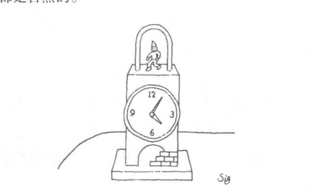

但因为这三个句子对于该位置关系的识解方式不同，所以它们的意思也并不相同。

野矢：不同之处在哪里呢？（1）的话，只要表在桌子上就可以吧。（2）（3）嘛，应该分别表示的是表的“坐像”和“站像”吧。

西村：是啊。这种拟人或者说比喻，说话人一般并不是有意识地进行的。将这种位置关系识解为"sitting"的人，就用（2）；识解为,*standing"的人，就用（3 ）;而（1）嘛，正像您说的那样，只要表在桌子上就可以。极端的情况下，哪怕只是桌面上画着表的图案也可以表达为（1 ）。

野矢：不过，如果表是被装在表盒里后放在桌子上的呢？这时，因为表确实在桌子上，所以（1）是可以用的；但又因为表不是被直接放在桌子上的，所以（2）（3）是不可以用的。既然（1）和（2）（3）可以描写的事件不同，那么可不可以说，从客观主义的角度看它们的语义也是不同的呢？还有，我虽然暂时不知道（2）和（3 ）的区别在哪儿，但应该也存在（2 ）为真而（3 ）却为假（或者相反）的情况吧。总之，如果（1）（2）（3）的真值条件不同，那么它们就是在客观上存在语义对立了。这样一来，不就也可以用客观主义的语义观来分析了吗？

西村：客观主义也不是不可以。但兰盖克想说的是，就算（1）（2）（3）表达的是同一个事件，它们对事件的识解方式也是不同的。因此，它们在语义上也应该是对立的。

野矢：嗯，不好意思。可能有点儿对不起兰盖克的苦心，不过在我看来，用这个例子来说明认知主义的语义观，恐怕效果一般。

西村：啊？是吗？

野矢：因为这个例子，即便能从认知主义的角度解释得很清楚，可从客观主义的角度也未必就不行啊。所以，要想击败客观主义的语义观，我觉得这个例子还差点儿意思。

### 「てくる（“来”）」的语义分析

西村：那我就再举一个例子吧。「太郎が花子に話しかけた（太郎和花子搭话了）」和「太郎が花子に話しかけてきた（太郎来和花子搭话了）」这两个句子，可以说表达的事件是相同的,但它们的意思其实并不相同。

野矢：感觉是有点儿不同。什么地方不同呢？

西村：「昨日、知らない人が私に話しかけました（昨天，一个陌生人和我搭话了）」，这句日语挺不自然的吧？我记得有一个英国人，他的发音很完美，几乎和日本人没有区别，但我总觉得他说的日语哪里有点奇怪。仔细一听，才发现原来就是他说的「知らない人が私に話しかけました（一个陌生人和我搭话了）」这句话奇怪。这时，如果是日本人的话，一般会说「知らない人が私に話しかけてきました（一个陌生人来和我搭话了）」。这是因为，日本人把事件识解成了 “对自己的接近”，所以才不能只说「話しかける（搭话）」，而要说「話しかけてくる（来搭话）」才自然。

野矢：「てくる（来）」还真和「来る（来）」有点关系啊。

西村：是的。这么一想，「太郎が花子に話しかけた（太郎和花子搭话了）」和「太郎が花子に話しかけてきた（太郎来和花子搭话了）」的区别就不难找到了。「太郎が花子に話しかけてきた（太郎来和花子搭话了）」，是说话人把自己当作花子，站在花子的立场来识解事件。而与此相对，「太郎が花子に話しかけた（太郎和花子搭话了）」，可以说至少不是站在花子的立场来识解事件的。虽然也有站在太郎的立场的时候，但大多数时候是既不站在花子的立场，也不站在太郎的立场,只是中立地来叙述事件。

野矢：明白了。所以，如果有个人特别喜欢花子，太郎是他的情敌，当太郎过来跟花子搭话时，他就会在心里想“少和花子搭话！”这时，说「太郎が花子に話しかけた（太郎和花子搭话了）」，是不足够的；得说「太郎が花子に話しかけてきた！（太郎来和花子搭话了！）」，才足以表达他此时的心情。

西村：应该是这样的（笑）。

野矢：我又有点儿坐不住了。能不能再发表一下外行的看法？

西村：好的。

野矢：「てくる（来）」的「来る（来）」，虽然表示的是接近，但这种接近不一定是空间上的。比如「電話をかけてくる（打来电话）」，虽然对方在空间上还停留在电话那边，可在心理上却感到对方好像来到了自己身边。也就是说，「てくる（来）」的「来る（来）」，与其说是物理上的接近，不如说是心理上的接近。

西村：是的。

野矢：「てくる（来）」既然表达的是心理上的接近，那被接近的就不能只是一个物体。比如，「柱にしがみついてきた（往柱子上扑过来了）」，是不是有点别扭？可「私にしがみついてきた（往我身上扑过来了）」就没问题。“我”可以被“扑过来”，“柱子”就不能被“扑过来”。

西村：有道理。我以前还真没想过这个问题。

野矢：啊，我又发现了更有意思的一点！就算被接近的是一个物体，可加上「私の（我的）」以后，就会产生一种心理上的亲近感，这时就也能用「てくる（来）」了。「私の枕に抱きついてくる（往我的枕头上扑过来）」，是不是就挺自然的？

西村：确实。

野矢：「西村さんが公園の猫に話しかけてきた（西村先生来和公园的小猫搭话了）」这句话，总觉得有点变扭；可是，「西村さんが私の猫に話しかけてきた（西村先生来和我的小猫搭话了）」，就一点儿问题也没有。还有呢，以「私（我）」为主语的时候，「私は私の猫に話しかけた（我和我的小猫搭话了）」可以说；可「私は私の猫に話しかけてきた（我来和我的小猫搭话了）」就不自然了。这些现象，都可以用“对自己的心理亲近感”来解释。真是太有意思了（笑）。

西村：还有一个关于「てくる（来）」比较有意思的地方，就是英语里没有与「てくる（来）」对应的表达方式。这是因为……。

野矢：这不正说明了（笑），至少日本人在感受人际关系的心理距离方面比美国人要敏感得多嘛。当然，我这是有点儿信口开河了，不过我想我说到关键了吧？

西村：是的。在日语里，当我们感觉到对方在接近自己的领域时，总是忍不住要将这一点表现在语言中。但英语在这方面就比较随意。无论是我给太郎打电话.还是太郎给我打电话，动词的形态都是一样的。我觉得这是日语和英语的一个很有意思的区别。这样的问题,也属于认知语言学的考察范围。

野矢：「てくる（来）」的例子这么有意思，我差点儿都忘了正题了。总而言之，「太郎が花子に話しかけた（太郎和花子搭话了）」和「太郎が花子に話しかけてきた（太郎来和花子搭话了）」，虽然在客观上表达的可能是同一个事件，但二者在语义上并不等同。对于这种语义上的对立，客观主义无能为力。我们只有把认知主体对事物的识解方式，也就是人们的认知方式，也作为语义的一部分来进行考察才可以。语言并不单单描述客观事实，它同样也传达了我们对事物的看法和识解方式。这就是认知语言学所依据的认知主义的语义观吧。

### 语法化

西村：我再来介绍一个相关的话题——“语法化”吧。我们通常认为，词汇和语法这两个部分相互补充，共同构成了语言知识。但其实我们经常会看到，一个本来属于词汇的要素慢慢演变成了语法要素。这个变化的过程，我们就称之为“语法化”。

野矢：我先确认一下，这里的“语法”，自然指的是狭义的语法，也就是相对于词汇的语法吧。

西村：没错。一般我们认为语法与词汇是相对立的，但“语法化”要考察的，却是从词汇演变过来的语法要素。比如，「てくる（来）」就是一个语法化的例子。「てくる（来）」源于动词「来る（来）」，但它已然没有动词「来る（来）」所具备的空间移动义了，只作为一个“补助动词”承担一定的语法功能。也就是说,从「来る（来）」这样一个词项，演变成了「てくる（来）」这样一个语法项，从而实现了语法化。当然，就像之前分析过的那样，「てくる（来）」还是表达出了一种对心理距离的识解，因此也并不是完全失去了原有动词的语义。可以说，「てくる（来）」这样的语法项，对整个句子的语义理解来说是不可或缺的。

野矢：我还是不太明白，为什么说「てくる（来）」是一个语法项？

西村：那我再举一个别的例子吧。在英语里，有一种用来表达“准备要……”或者"即将要……”的句型。例如"I'm going to open the door."或者"It's going to rain."o这里的"be going to",就属于语法项。这个您理解吧？

野矢：理解。英语语法书上也写着这是一种将来时态嘛。

西村：与其说它是一种“时态”，不如说它是像完成时或进行时一样的一种表达时间的“体（aspect）<sup>11</sup>”。“be going to",本来的意思是“为了……正在向某处移动中”。它其实只是在表示“去”的动词“go”的进行时后面,加上了表示目的的不定式短语。但后来“g。”的语义逐渐虚化，到最后“be going to”就只剩下了 “……将会发生”这层意思，这就是现在英语里的助动词“be going t。”。像这样的现象，就是典型的“语法化”。

野矢：明白了。不过，我还是想再确认一下。比如，像“be good at (擅长～)”这样的惯用语，应该算词项吧？那它与"be going to”的区别是什么呢？

西村：我们一般认为“be going t。”是助动词，就像表示完了的助动词“have” 一样，表示的是“体(aspect)"这样一种语法意义。因此，"be going to” 一直以来都被看作是一个语法项。但说到底，“语法化”这种现象的存在本身，就说明词汇和语法之间的界线并非泾渭分明。而很多认知语言学家也都认为，词汇和语法其实是一个连续统。

野矢：噢，那像我这样抱怨分不清语法项和惯用语的人呢？

西村：认知语言学其实是很欢迎的。

### 认知语法与生成语法是不是对立的

野矢：我有一个问题，还是跟一开始讨论的“语法是什么"有关系。我总觉得，认知语法和生成语法，不但对语义的理解不一样，就连对语法的理解好像也不一样。

西村：怎么讲？

野矢：比如，「知らない人が私に話しかけました（一个陌生人和我搭话了）」这句日语之所以别扭，是因为这句话在词语的组合方式上有问题，因此是语法上的偏误。这里的“语法”，按照您之前讲过的，指的是词项的组合模式或规则的集合，对吧？

西村：是的。

野矢：可是，生成语法的人大概会觉得，「知らない人が私に話しかけました（一个陌生人和我搭话了）」这句话在语法上没有问题吧？

西村：这个不好判断吧……。因为生成语法根本就不会考察这样的句子，所以我也只能靠想象猜测了。我想他们应该会认为这个句子没有问题吧。就算认为它有问题，估计也是觉得它受到了语法以外的因素的影响。

野矢：我想起了那个很有名的例子，“Colorless green ideas sleep furiously （无色的绿色念头狂怒地在睡觉）”。就连这样的句子，生成语法也认为它“虽然在语义上不通，但在语法上并没有问题”。可这样一来，不就说明认知语法和生成语法在对“语法”的理解上也有分歧吗？

西村：是啊。

野矢：「知らない人が私に話しかけました（一个陌生人和我搭话了）」这句话，在词语的组合方式上有问题。这一点，说日语的人一般谁都能感觉到，自然也包括生成语法的人。但是，从生成语法的角度上看，这并不属于语法上的偏误。也就是说，他们认为「知らない人が私に話しかけました（一个陌生人和我搭话了 ）」虽然在词语的组合方式上有问题，但在语法上并没有问题。

而认知语法则认为，这句话在语法上是有问题的。同样，刚才那句“无色的绿色念头狂怒地在睡觉”，在认知语法看来在语法上也是有问题的。

需要注意的是，并不存在相反的情况，即认知语法认为在语法上无误而生成语法却认为该句子在语法上有误的情况。这说明，认知语法的“语法”要比生成语法的“语法”，在涵盖范围上更广。

在生成语法看来，并非所有的词语的组合规则都能被称之为语法。既有属于语法范畴的组合规则，也有不属于语法范畴的组合规则。而与之相对，在认知语法看来，只要是词项的组合规则，都一律属于语法范畴。可以这么概括吗？

西村：有道理，您的观点很有价值。不过，生成语法的“语法”，有时指的是广义的语法，所以我想在这里稍微整理一下。就像我在这一讲最开始讲到的那样，“生成语法”这个专有名词中的“语法”，指的是“我们使用语言时凭借的所有语言知识”，这是广义的语法。与之相对，我们这一讲讨论的“语法”，是狭义的语法，即“词项的组合模式及规则，仅就狭义的语法来看的话，生成语法确实比认知语法的“语法”涵盖面更窄一些。

野矢：对吧。

西村：生成语法认为，语法（当然是狭义的语法）只局限于那些抽象度高、适用面广的组合模式。比如，〈名词短语+动词+名词短语〉这样的组合模式，就属于抽象度高的模式。与此相对，认知语法认为，即使是那些抽象度不高、适用面有限的组合模式，比如像〈名词短语+give+me＞这样内含了具体词项的组合模式，也属于语法。

进一步说，认知语法认为，抽象程度高的组合模式和具体程度高的组合模式之间，并没有严格的界线。而且，无论是对于语言习得,还是实际的语言使用来说,其实反而是后者这样具体程度高的组合模式才更基本，也更典型。而抽象程度高的组合模式，则不如说是由具体程度高的组合模式派生出来的，典型程度自然也就很低。

上述观点其实可以从“语法和语义不可分割”这一认知语言学的观点推导出来。既然认知语法认为语法和语义不可分割、紧密相连，那么对内含具体词项的组合模式也就自然不会排斥了。认知语法甚至认为，比起抽象程度高的情况，在有具体词项的情况下去理解一个组合模式反而是更常见的。

野矢：认知语法主张“语法和语义不可分割”，生成语法主张“语法独立于语义存在”。于是，认知语法为了证明语法和语义的不可分割，便会尽可能地去放宽语法和语义的范围。而生成语法为了证明语法独立于语义存在，便会尽可能（洁癖性地）去缩窄语法和语义的范围。是这样吧。

西村：可以这么说。

野矢：这么一想的话，生成语法和认知语言学的对立，其实应该也算不上是针锋相对。毕竟，二者对“语法”和“语义”这些重要概念的定义不同嘛。就好比两个人摔跤，却没在同一块场地上较量，他们各自给自己预设的根本就不是同一块场地。因此，在“语法是否独立于语义存在”这个问题上，二者虽然意见相反，但如果他们对“语义”和“语法”的定义本身就不同的话，也很难单纯说他们是在同一个问题上给出了相对立的答案。

认知语言学的人都认为“生成语法是错的”吗？

西村：认知语言学刚问世的时候，应该是很想说“生成语法是错的”吧。因为那时认知语言学急于想要证明自己的存在意义，于是便会尤其去关注那些生成语法没法解释但认知语言学可以解释的语言现象。

野矢：但那并不代表生成语法是错的，对吧？举个极端的例子，虽然“动物学研究不了植物”，可你并不能因此苛责说动物学是错的。当然，我这个例子可能举得不太恰当啊。总之，我想说的大概就是这个意思。生成语法和认知语法，其实也是可以友好相处的嘛。

西村：我也认为完全可以友好相处。不过……，哦对了，说到这里我想起来一件事。大约十五年前，在学会上曾经召开过一个以认知语言学和生成语法的对话为主旨的研讨会。在那个会上，我就举了一些生成语法特别擅长分析的语言现象，然后指出“生成语法虽然是这样分析的，但其实认知语言学的分析方法更好”。但最后就变成了刚才您说的那样，不是谁对谁错的问题，而只是个人喜好的问题。

野矢：怎么又成了个人喜好的问题了呢？

西村：也不知道怎么回事，讨论就变成了这样。当场还有一个搞生成语法的老师，他很爱喝酒。在他看来：“认知语法的解释方式也很不错，但对于爱喝酒的我来说，总觉得力度还不够。”（笑）

野矢：善于用数理方式思考问题的人，肯定还是倾向于生成语法吧。

西村：是啊。

野矢：搞认知语言学的人，大概不太擅长用数理方式来思考问题吧？

西村：是啊。……不过，比如兰盖克，他本来是研究生成语法的，因此他其实是喜欢数理式的研究方式的。他曾经说过：“如果可以的话，我也想做得更严谨一点。但因为语言的特质不是那样的，所以我也没有办法。”他还说：“因为语言的特质不是那样的，所以我只好改变研究方法。其实，我是喜欢更严谨的研究方式的。”他其实真的是个很严谨的人。

野矢：我不是一个严谨的人，所以请原谅我随便讲几句啊。生成语法，试图从多样性中找出普遍性的、核心性的东西，因此可以说是“柏拉图”式的视角。而认知语言学，则偏向于尽可能挖掘并保留语言的多样性,因此可以说是“亚里土多德”式的视角。这么一说，我也慢慢开始觉得，选择哪一种视角也许确实只是个人喜好的问题了（笑）。

1. 字面意思为“迟迟不迈出第二步”。
2. 位于日本列岛中部的滋贺县，是日本最大的湖泊，面积为670平方公里，储水量达275吨。
3. 取自圣经故事。传说以色列人和非利土人打仗时,非利土人的阵营中出现了一个巨人.名叫歌利亚。正当以色列人不知如何是好的时候，一个名叫大卫的少年自告奋勇,并最终杀死了歌利亚。
4. 识解（construal），日语里一般叫作「捉え方」「事態把握」，指的是说话人对同一事件采取的各种不同的认知方式，是认知语言学的基本概念之一。
5. 动词的体，指的是对事件内部的时间结构的把握方式，具体来说就是关注的是事件的开始、持续，还是完结。而这种对事件的关注方式的不同，往往反应在动词形态的变化上。

## 第三讲原型与百科知识语义观

### 范畴化

西村：作为我们这一讲内容的理论前提，我想先来介绍一下“范畴化”。“范畴化”，其实并不是什么难懂或特别的概念，指的就是我们在日常生活中有意无意进行的“分类”或“归类”。也许你会觉得，我们只在某些特定的时候才会进行“范畴化”。但其实，当我们选择坐到一张椅子上时，也是因为将其识别、归类为椅子了，我们才会选择坐上去。也就是说，我们把它归进了椅子这个范畴。

“范畴化”和语言现象密切相关。试想一下，当我们说我们知道“狗”这个词的意思时，实际上指的到底是什么呢？其实指的就是，当我们看到一个对象时，我们可以判断出那是不是一只狗，对吧。也就是说，知道一个词的语义，比如“狗”，指的就是知道该词涵盖的是怎样一个范畴。

野矢：说到分类，名词应该是最典型的。那有没有名词以外的例子？

西村：比如“跑”这个词。当我们说我们知道“跑”这个词的语义时，其实指的是当我们看到某个动作时，能够判断那个动作到底是“跑”，是“走”还是“爬”。

野矢：虽然不能说语言的功能仅限于分类，但应该可以肯定地说，分类是语言的基本功能。

### 古典范畴观

西村：“范畴”这个概念本身，当然并不是只有认知语言学才有。在认知语言学诞生之前，“范畴”这个术语就已经在被使用了。为了与认知语言学进行对比,我们把认知语言学以前的范畴观称作“古典范畴观”。“古典范畴观”的基本观点是：属于某一范畴的成员，应该具备见之于该范畴所有成员的共通特征。

野矢：有关这一点，我觉得您还得再定义得严谨一些。因为只说应具备见之于所有成员的共通特征是不够的。比如，“狗”的特征之一是它们都是动物，但仅凭这一点我们还是界定不了狗这个范畴。

西村：没错.属于同一范畴的对象，一般被称作“成员”。“古典范畴观”的观点是，属于同一范畴的成员之间，应该存在一个所有成员都有且只有这些成员才有的特征。也就是说，在“古典范畴观”看来，范畴的界定需要的是充分必要条件个可以不多不少恰好筛选出所有成员的条件。

野矢：这和语言哲学的传统概念“内涵”和“外延”是不是一回事？举个数学的例子，应该比较好懂。比如，自然数可以分为奇数和偶数。“能被2整除的自然数”，就是界定偶数的充分必要条件。而奇数呢，就是“不能被2整除的自然数”。像“能被2整除的自然数”或“不能被2整除的自然数”这样的界定，就是内涵。而把“能被2整除的自然数”全部聚到一起后，所形成的偶数的无限集合，就是偶数的外延。像这种以内涵和外延来界定范畴的范畴观，可以说就是古典范畴观吧。

西村：如果范畴可以像刚才说的那样通过充分必要条件来界定，那么范畴的界线，也就是成员和非成员之间的界线，也应该像您所举的偶数和奇数的例子那样非常明确才对。也就是说，任何一个对象，它都只能是或者不是某一范畴的成员。不存在身份不确定的成员。因此，范畴的界线也就不会出现模糊不清的情况。

野矢：在语言哲学里，模糊性是一个非常复杂的问题。这个问题我很少涉足，但给我的印象是，研究语义的时候大家似乎都是先从没有模糊性的问题入手，然后再去考虑有模糊性的问题。也是因为这个原因，传统上才一直都是古典范畴观占据主导地位的吧。

但其实，界线模糊的概念是数不胜数的。比如，“跑”和“走”这两个概念就是一个连续统，从哪儿开始是“跑”，从哪儿开始是“走”，其实都是很模糊的。同样，“红色”和“橘红色”之间，也并没有一个明确的界线。

西村：雷可夫在认知语言学诞生之前，在探讨“个子高/矮”的例子时，就曾提出过“模糊(fuzzy)范畴”的观点。他还一度提出，应该把数学家扎德(Lotfi A. Zadeh )在上世纪六十年代提出的“模糊集合理论”应用到语言学当中来，这也成为认知语言学“原型”理论的一个源头。该集合理论认为，对于一个集合来说，并非只存在属于该集合的要素和不属于该集合的要素，要素之间其实是一个连续统，属不属于该集合只是程度上的差异而已。

野矢：这就好比，在所有「丼（海碗）」构成的集合中，有的碗虽然称不上是100%的「丼（海碗）」，但可以算得上是75%的「丼（海碗）」（笑）。

西村：没错。在雷可夫看来，对于像「丼（海碗）」这样的范畴，“古典范畴观”就是不适用的，应该从模糊范畴的角度来分析它。

野矢：我懂了。我这才明白，为什么您一开始不是问“‘狗’这个词是什么意思？",而是问"知道‘狗'这个词的意思指的是什么？”

西村：这样啊（笑）。

野矢：就是这样啊。

### 新范畴观

西村：接下来，在上世纪七十年代中期，出现了一系列认知心理学的研究。这些研究，站在了与“古典范畴观”相对立的立场，试图从“原型”的角度来对范畴进行重新思考。

野矢：说起上世纪七十年代中期，那时候认知语言学还没有问世吧？也就是说，认知心理学早在认知语言学诞生之前，就已经在倡导新的范畴观了，是吗？

西村：是的。雷可夫在1987年的 *Women, Fire, andDangerous Things* 一书中，介绍了“原型”理论的几个源头。其中之一，就是认知心理学家伊莲娜•罗施(Eleanor Rosch )的范畴研究。"原型”这个术语，就是在罗施的研究中出现的。

野矢：“原型(prototype)”，是不是就是“典型”的意思？

西村：差不多。认知语言学说“原型”的时候，所指范围其实更广一些，不过这里姑且先理解成“典型”也没有问题。

野矢：范围更广指的是……？

西村：就是“原型”不光包括“典型”，还包括“范例”或者“常例”等。这些我们之后再介绍吧。

刚才说雷可夫举出了 “原型”理论的几个源头，一个是罗施的研究，一个是刚才提到的模糊集合理论。还有一个源头，就是维特根斯坦(Ludwig Wittgenstein )的“家族相似性”理论。

野矢：维特根斯坦的“家族相似性”理论的提出，就是为了要瓦解古典范畴观。关于这个理论，还是让我来说明一下吧。

让我们以“游戏”这个概念为例。大家常常会问“游戏的本质是什么？ ”要想回答这个问题，就需要我们对“游戏”这个概念下个定义。而维特根斯坦却指出，其实根本不存在什么“游戏的本质”。我们能够称之为“游戏”的活动，有的是几个人一起玩儿的，有的是一个人玩儿的；有的有规则，有的没有规则；有的有胜负之分，有的不分胜负。维特根斯坦做了一个很巧妙的比喻，说这就好比我们把纤维捻成线的时候，应该不会有哪根纤维是始终贯穿在线的两端的，这些大量的纤维都只不过是以彼此部分重叠的方式拧在一起的。而“游戏”这个概念，也是把各种游戏之间彼此部分重叠的那些共通点拧在一起形成的。这种情况，就被维特根斯坦称作“家族相似性”。这就好比在一个家庭中，父亲和孩子的脸有一部分很像，而孩子和母亲的脸也有一部分很像。虽然父亲和母亲长得并不像，可因为他们都和孩子有相似点，所以他们才会被视为同一个家庭的成员。

西村：认知语言学的“新范畴观”，正是在这种观点的基础上发展出来的。认知语言学还进一步指出，除了范畴界线的模糊性以外，范畴成员往往在“典型性”上也存在差异。就是说，即便同属一个范畴，也会存在某一成员比其他成员更具代表性的情况。有特别典型的「丼（海碗）」，也有和一般的饭碗很难区分的「丼（海碗）」。有非常典型的游戏，也有比较特殊的游戏。还有一个经常举的例子是鸟类。就鸟类这种动物而言，我们通常认为比起企鹅和鸵鸟，麻雀和燕子是更典型的鸟。

即使是最符合“古典范畴观”的“偶数”的例子,其实也出现过意见上的分歧，我也不知道最后的结论是什么。反正就是好像有人提出，偶数里也有更典型的偶数。然后就立刻有人出来反驳说，这也太奇怪了。

野矢：这确实太奇怪了。

西村：比如，2、4这样的偶数，相比36496,是更典型的偶数。

野矢：这个……我完全不能接受。

西村：这样啊（笑）。算了，反正这也不是我说的。

野矢：不过，我想即使是持“古典范畴观”立场的人，也应该能意识到同属一个范畴的成员在“典型性”上的差异吧。企鹅虽然被归类为鸟，但不是典型的鸟，这应该是不言而喻的啊。

西村：是啊。不过意见的分歧点在于，这种“典型性”的差异是否也反映在语义中。在“古典范畴观”看来，在鸟当中企鹅固然不如麻雀和燕子典型，但这种差异和我们对于“鸟”这个词的语义理解并没有什么关系。而认知语言学则认为，什么是典型的鸟、什么是非典型的鸟这种认识本身，恰恰才是我们对“鸟”这个词的语义理解的核心。范畴，其实是以范畴的核心成员——也就是“原型”——为中心，通过相似性等原理扩展到其他周边成员而形成的。这就是认知语言学提出的“新范畴观”。因此，“鸟”这个范畴并非仅仅是鸟的集合，我们还应看到它是以典型的鸟为中心、以企鹅和鸵鸟为周边成员的这样一个集合。

野矢：也就是说，认知语言学认为，仅仅能够判断某个对象是不是鸟还不够，还要能够判断麻雀是“特别典型的鸟”，而企鹅是“有点奇怪的非典型的鸟”。只有这样，才算真正理解了 “鸟”这个词的意思。

### 原型语义学

西村：以原型理论为理论基础的语义学，我们称之为“原型语义学”。以“说谎”这个词为例，什么样的行为才能被称之为“说谎”呢？其实有三个典型特征。

①说了不符合事实的话。

②说了说话者认为不符合事实的话。

③有欺骗听话者的意图。

当上述三个特征都满足的时候，就是典型的说谎行为。

野矢：这三个条件，应该不是界定“说谎”的充分必要条件吧。

西村：界定“说谎”这个范畴时，“古典范畴观”认为我们需要找到充分必要条件，而原型语义学则认为我们只要找到典型条件就可以。

我们可以造出满足上述三个条件的句子，满足两个条件的句子，只满足一个条件的句子，然后问“你觉得这算不算说谎？ ”在美国，针对“lie”这个词，的确就有过这样的研究。研究的结果是，三个条件都满足的时候确实被认为是最典型的说谎。但只有一个或两个条件满足的时候，被判断为说谎的情况也是有的。虽然没有那么典型，但对很多人来说，不管怎么说它们还是一种说谎。另外，通过研究还弄清了三个条件中哪个条件缺失最容易降低说谎的典型性。研究显示，三个条件中“说了不符合事实的话”这一条即便缺失，对谎话的典型性的降低也十分有限。也就是说，即便我们并没有说不符合事实的话，其实很多时候也会被判定为在“说谎”。

可奇怪的是，当我们改问“什么是说谎？ ”的时候，大多数人的回答却都是“说了不符合事实的话”。也就是说，在什么是更典型的说谎这一问题上，看实例时给出的答案和在被询问“说谎”这个词的定义时给出的答案是有分歧的。

野矢：我以前想过这样一个例子。有一个人，他认定自己得了胃癌，为了不让周围的人担心，便撒谎说自己得的是胃溃疡。结果，这个人后来才知道自己得的真的是胃溃疡。这个情况，按照刚才的三个条件判断，应该是不符合条件①，但满足条件②和③，对吧。

西村：这就是所谓的“弄假成真”吧。虽然刚好说的话成了真，但一个本来认为自己是胃癌的人对别人说自己是胃溃疡的时候，他应该还是说了谎的吧。

野矢：您看，《广辞苑》上写的是，“说谎——不符合事实的事情”。

西村：这个定义，本身就是在“说谎”吧（笑）。

野矢：毕竟有的谎话，只是碰巧弄假成真而已嘛。还有，关于“有欺骗的意图”这一点，其实也存在“本来并没有欺骗的意图，但从结果上看却说了谎话”的情况。给“说谎”下定义，真的好难啊。这时，用原型的观点来理解语义，就会非常有效，而且我觉得恐怕也只有这个办法可行。

西村：是的。而且，原型语义学的观点，也更符合我们在理解语义时的真实情况。

### 样本在语言习得中的重要性

野矢：在有关范畴的模糊性问题上，原型语义学要比古典范畴观有效得多。那原型语义学还有没有其他的优势，或者独到之处呢？比如，让我们对语言习得的理解变得更符合实际情况？

西村：您说得没错。比如在教小孩“鸟”这个词的意思时，我们可以指着一个具体的鸟（也就是鸟的样本）说“那就是鸟”，或者画一个鸟给他看。这时我们指的或者画的鸟，通常都是以麻雀或燕子为样本的，应该不会有人一开始就拿企鹅举例。

野矢：也不是吧。麻雀、燕子多难画啊。正常情况下，一般人最多也就能画个四不像吧。

西村：不管画成什么样，我们画的一般都是有喙和翅膀的、可以在空中飞的鸟吧。我们总不会画鸵鸟和企鹅吧。孩子总是先识别麻雀、燕子这样的鸟的原型（典型的鸟）以及它们具有的几个特征（有喙，可以用翅膀在空中飞等），然后才开始习得鸟这个范畴。企鹅和鸵鸟，因为不能飞翔，确实和鸟的原型有一定的距离；但它们在拥有喙和翅膀（虽然不能用于飞翔）这一点上和麻雀、燕子又是共通的。于是，孩子到了后来也会慢慢学习到它们原来也是鸟。

野矢：如果是古典范畴观的话，我们一开始就得突兀地教给孩子界定鸟类的充分必要条件是什么。可我想大部分人不仅不知道该怎么教，恐怕也不知道这个充分必要条件到底是什么吧。

西村：我们日常使用的语言，几乎都没有严格的定义，就更别提什么是界定它们的充分必要条件了。

野矢：对吧。比如刚才提到的“游戏”，还有“走”、“早饭”、“家具”什么的，在这一点上也是一样的。什么叫“游戏”，什么叫“走”，我们都无法用充分必要条件来界定它们。这时，只有依靠呈现样本，语言习得才能成为可能。

刚才在探讨家族相似性时，我提到了维特根斯坦的名字。他的语言观，在由前期转入后期的过程中，发生了很大的变化。这个变化，其实就是由古典范畴观向接近原型语义学的范畴观的转变。另外，托马斯•库恩(Thomas Kuhn)在他的 *The Structure of Scientific Revolutions* (有中译本，《科学革命的结构》，金吾伦、胡新和译，北京大学出版社)一书中，提出了 “范式”的概念。这个概念，对之后的学术界影响非常大，而它的提出，其实也是受了维特根斯坦的影响。当我们被问到“科学是什么？科学应该是怎样的？ ”时，我们无法说出界定科学的充分必要条件或本质是什么，我们能够做的只有展示研究的样本。这就是库恩所讲的范式。有很多人认为范式类似于世界观，但我觉得它的意思其实更接近于“样本”。

西村：原来如此。说维特根斯坦是认知语言学范畴理论的源头之一，应该就是基于这个原因吧。

野矢：生成语法试图从规则的角度分析语言，而认知语言学则试图从样本的角度来把握语言。我想这种对立，大概与刚才讲到的哲学理论的变迁也是有关系的。雷可夫他们，是不是也在一定程度上意识到了这一点呢？

西村：我想应该是的。

### 关东和关西<sup>12</sup>的“土豆炖肉”意思不同

野矢：我认为，原型语义学至少还有一个非常重要的优势，就是让我们可以更容易把握语义的多样性、可塑性。

西村：“语义的可塑性”指的是？

野矢：概念的外延——也就是某个概念所涵盖的所有成员——虽然是比较固定的，但其中哪个是典型成员，却有可能因时代或地域的不同而发生变化。这种变化，往往会演化为语义上的差异或变化。

比如，“女人”这个词，它的外延是“所有可以被称之为女人的人”，这一点古今应该都是一样的。但在什么是典型的女人这一点上，从古至今却变化了不少。那么“女人”这个词的语义，就可以说从古至今发生了变化。

西村：有道理，还真是这样。不过，除了历时的变化，还有地域的差异。比如，因为关东和关西的饮食文化不同，同一个语言表达的原型也有可能不同。「肉じゃが（土豆炖肉）」的“肉”，在关东指的主要是猪肉，而在关西据说指的却是牛肉。

野矢：我听说，在关西一说到“肉”，一般大家默认就是牛肉。所以，关东的「肉まん（肉包子）」，到了关西就得叫「豚まん（猪肉包子）」了。语义的差异，在和外语对比的时候会更明显，有时也会成为翻译时的棘手问题。比如“sweets”和日语的「甘味」，指的虽然都是甜点，可二者的“原型”却大相径庭。对我来说，「甘味」的原型应该是「大福<sup>13</sup>（糯米团子）」和「あんみつ<sup>14</sup>（豆沙水果凉粉）」吧。还有像“castle”和日语的「城」，虽然从外延上看差异不大，可原型却非常不一样。对于日本人来说，「城」的原型应该是姬路城<sup>15</sup>那样的城堡；而对欧洲人来说，大概是新天鹅堡那样的城堡才是原型吧。美国人的原型是什么呢？

西村：大概是“灰姑娘城堡”吧。

野矢：哈哈，可能真是这样。我们还可以再细分一点。即使在同一个国家，因所处年龄层或团体的不同，对什么是原型的看法也会有所不同。进一步说，个人经验的不同，也会造成语义理解的不同。这一点发展到一定程度，就会出现每个人对语义的理解都不同的情况，到最后连沟通交流可能都无法进行了。对于研究哲学的人来说，这是个复杂而又有趣的、具有挑战性的课题。

西村：有道理。这么一来，我们恐怕得好好想想，大家平时说的是不是“同一个日语” 了。

### 原型是什么

野矢：关于原型，我还想进一步向您请教一下。首先，为什么要叫它“原型”呢？换句话说，“原型”到底指的是什么呢？是不是可以把它理解为一个原始的模型，由此可以衍生出其他东西？

西村：原型其实也有很多种。“常例”就是其中的一种。比如“日本人很勤勉”、“政治家很腹黑”这种对某对象定格式的刻板印象，就是“常例”。不过刚才说的麻雀，并不是鸟的常例，它只是鸟的典型。另外，雷可夫指出原型中还有一种，叫"paragon" —~•范例。比如，父亲的范例。

野矢：「男らしい（有男人味）」，与其说表示的是男人的典型，不如说是那些被认为（或是曾经被认为）值得大家模仿的男人的模范吧。所以，我们说「らしさ（有～味）」的时候，指的往往并不是典型。

西村：是啊。

野矢：那「子どもらしい（孩子气）」呢？是典型还是范例？

西村：这可不好说。可如果说一个人「子どもっぽい（幼稚）」，就是贬义了吧。

野矢：我觉得「子どもらしい（孩子气）」指的是孩子的典型，而不是范例。「子どもらしい（孩子气）」，指的是一个典型的孩子较为积极的那一面；而「子どもっぽい（幼稚）」，则指的是较为消极的那一面。

西村：差不多是这样的。

野矢：我才发现，鸟是不存在范例的，因为不会有模范的鸟。这还挺有意思的。

西村：总之，典型、常例、范例等等，这些被统称为“原型”。也就是说，当范畴内成员性质不一、分布不均，既有典型成员又有周边成员的时候，我们就把前者统称为“原型”。

### 百科知识语义观

野矢：是不是原型，我们是怎么知道的呢？我们怎么知道麻雀和燕子是鸟的原型，而企鹅、鸵鸟就不是呢？

西村：看我们怎么使用“鸟”这个词就知道了吧。说“我想变成一只鸟”的时候，我们心里想的肯定不是企鹅，对吧。

野矢：说到鸟的典型.我最先想到的是图鉴里的图片。可典型指的应该不光是外在特征吧。

西村：肯定不光是外在特征。以“虫子”为例，不管是锹形甲虫还是独角仙，城市里的孩子一般都只在图鉴上看到过这些虫子。因此,他们与实际捕过虫子或者玩过虫子的孩子，对“虫子”这个词的理解肯定不同。“鸟”也是一样的。除了它的外在特征，我们还要了解它所处的生态、栖居的环境，这样才算真正了解了“鸟”这个词的意思。这一点，和“百科知识语义观”有密切的联系。也就是说，有关鸟的一系列事实，会作用于“鸟”这个词的语义。

野矢：一般来说，我们都会把有关语义的知识和有关事实的知识区分开吧。我想，无论是从学术上还是从常识上来说，应该都是这样的。也就是说，知道“鸟”这个词是什么意思，和了解关于鸟的很多事实，是两码事。

西村：是的。认知语言学之前的所有语言理论，包括生成语法在内，都会区分语义知识和语义以外的知识（后者我们叫它“百科知识”）。但认知语言学却不同于传统观点，认为我们根本无法区分这两种知识，所谓的语义知识，其实正是因为有了百科知识才得以存在的。这就是百科知识语义观。

野矢：词典里记录的知识与百科辞典里记录的知识不同，这不仅是一般常识，也是语言学界的传统观点。这样看来，《广辞苑》还是很有前瞻性的嘛（笑）。

西村：因为《广辞苑》既是词典又是事典（百科辞典）嘛。

野矢：那么，对于百科知识语义观来说，什么样的事实是与语义相关的事实呢？比如，关于鸟的事实数不胜数，可其中哪些是与语义有关的呢？我估计不是所有的事实都与语义有关吧。而且，与语义有关的事实和与语义无关的事实之间的界线，应该是很模糊的吧。

西村：只要是众所周知的有关鸟的事实，应该都是与鸟的语义有关的。

野矢：也就是说，是一种“共识”？

西村：差不多吧。不过也不可以一概而论。“共识”中，有一些是一说到“鸟”这个词就会被激活的，而另一些则是偶尔才会被激活的。而在某些情况下，那些一般认为与鸟的语义无关的知识，也有可能被激活。所以，硬要划出一个界线也是不太现实的。如果非要那样做的话，就不符合我们使用语言时的实际情况了。

野矢：总之，就是某个语言的使用者间（或者说是某个语言共同体内）达成的“共识”，会反映在对这个语言的语义理解上，是这样吗？

西村：是的。

野矢：可这样一来，我们就会发现“日语”内部也存在很多差异性。我承认，肯定会有一部分知识是所有日本人共有的。可是，比如当我们在说“鸟”的时候，根据说话的场合是宠物店还是烤鸡肉串店<sup>16</sup>，说话人是猎人、学者还是其他行业的人，“鸟”的意思都会有所不同。也就是说，语义依存于“是什么样的人对什么样的人，在哪种场合下说的话"。这样一来，语义学与语用学之间的界线也要开始变得模糊了。

西村：正是这样。“语义学”，研究的是脱离上下文、语境的那部分语义知识；“语用学”，研究的是依赖于上下文、语境的那部分语义知识。而认知语言学认为，“语义学”和“语用学”的研究之间，不可能划分出严格的界线。因为本来就不存在脱离上下文、语境而独立存在的语义。

野矢：百科知识语义观与原型语义学，名字不同，乍一听好像没有什么关联。可是，百科知识语义观提出的“语义会受事实影响”中的“事实”，并不是随便什么事实都可以，而是那些已经成为共识的事实。也就是说，是“原型”性的事实。所以到头来，无论是百科知识语义观还是原型语义学，在我看来都是一回事。一个是从事实与语义的关系出发，另一个则是从典型性与语义的关系出发，但二者的目标其实是一样的。我这么理解对吗？

西村：对，可以这么理解。

野矢：这些与语义相关的事实，我想叫它们“典型故事”。比如，与“狗”的语义相关的典型故事是：四条腿，汪汪叫，一般是被饲养的（虽然也有野狗），饲养时一般也都是普通人用普通的方式在饲养，等等。另外，在关于狗的典型故事中，狗的饲养人也必须是典型的饲养人，喂的食物也应该是典型的狗粮（我小的时候，一般是喂浇了味噌汤的米饭，现在应该是喂宠物食品吧），如果在室外饲养的话，还得有一间典型的小狗窝。您看，“狗”这个词，竟然蕴藏着这么一个充满了典型事物的典型世界。而我认为，要想理解“狗”这个词的语义，就也要对这个典型世界进行了解。这个观点和原型语义学其实很接近吧？

西村：这是您在您的那本《言说那些无法言说之事》（原书名『語りえぬものを語る』，野矢茂树）里提到过的观点吧。我当时读了之后，感觉这真的是对原型理论最好的说明了。您所说的“典型故事”，正是认知语言学的“百科知识”。雷可夫还提出过一个“理想认知模型”，也是和“百科知识”差不多的意思，不过雷可夫本人并没有对它做出一个很清楚的说明。

### 各种各样的“读”

野矢：关于原型语义学与百科知识语义观，您已经大致做了介绍。还有什么要补充的吗？

西村：原型语义学与百科知识语义观，在说明“鸟”的例子时虽然很顺利，但在说明别的例子时也会遇到一些困难。比如，关于「読む（读）」这个词的语义……。

野矢：对“读”这个词的语义，看看能否从原型语义学的角度做出说明，是吧？

西村：是的。「読む（读）」是一个很基本的词，几乎任何一个国家的语言里都会有这个词，但分析起来却很复杂。让我们来思考一下，「読む（读）」包含了几个要素。比较常见的是「本を読む（读书）」。这里的「読む（读）」，指的是通过文字信息来理解它所表达的内容。很多情况下，这个「読む（读）」也包含了出声朗读的意思。我记得柴田元幸<sup>17</sup>先生在一本书上写到过，对于古希腊人来说，出声朗读才是常态。日语里，当语文课上我们被老师要求「そこ読んで（读一下这个地方）」时，我们一般也是会出声朗读的吧。

野矢：要是不出声地默读，老师肯定得说你（笑）。

西村：另外，当孩子对妈妈说「この本読んで（给我读读这本书）」时，妈妈如果只是自己默读，肯定也挺奇怪的吧……。孩子肯定不会满足的。我们应该怎么看待这些例子呢？在古希腊，如果偶而看到默读的人，大家肯定都会奇怪他在干什么……。毕竟在古希腊，典型的「読む（读）」是要出声的。而现在我们说「読む（读）」的时候，一般都是指默读。当然，一些特殊场合，还是会需要我们出声朗读的。从原型理论的角度去把握这些「読む（读）」，其实是有困难的。更别说「地図を読む（读地图）」或者「この漢字は何と読みますか（这个汉字怎么读）」里的「読む（读）」了。

野矢：还真是。这么一说，我又想到一些例子。比如，挂轴上的字太龙飞凤舞，我们看不出上面写的是什么字的时候，我们可以说「何て読むんだろう（怎么读啊）」、「読めない（我不会读）」之类的。另外，我们还会说「人の気持ちを読む（读人的心理）」，下围棋或将棋<sup>18</sup>的时候会说「手を読む（读对手的棋路）」，就算不是下围棋或将棋的时候我们也会说「先を読む（读出下一步）」。

西村：是的。这么多各式各样的「読む（读）」，应该怎样从原型的角度去把握它们呢？

野矢：确实引人思考。可是，在这个问题上，认知语言学的课题到底是什么呢？现代日语中，默读是「読む（读）」的典型，出声朗读是「読む（读）」的周边事例，而「地図を読む（读地图）」、「先を読む（读出下一步）」则是「読む（读）」更周边的事例。像这样把现代日语的使用习惯记录下来，难道还不够吗？认知语言学是不是觉得，还需要进一步弄清由原型扩展到周边事例的“机制”？

西村：如果只是想弄清一个普通的现代日语使用者拥有的语义知识的话，只要正确记录“读”这个词的使用习惯也就足够了。但如果还想说明这些各式各样的「読む（读）」产生的途径，那就需要从原型（也就是语义扩展的原点）出发，一步步探寻语义扩展的机制。

野矢：对这种机制的研究，我想已经超越了狭义的语言学的研究范畴。简言之，对于原型到周边事例的扩展机制，仅从语言规则的角度去分析是远远不够的，还要考察心理因素以及文化、社会、生活方式等因素（也可以说是文化人类学的因素）的影响。

西村：用一句话概括，就是语言的使用方式之所以是这样的，是因为语言使用者的认知方式就是这样的。

野矢：这不就是认知语言学嘛。

### 典型的狗的跑法

野矢：我们刚才讲的都是概念，也就是词或短语。那么，原型语义学在对句子的分析上是不是也同样有效呢？比如，除了 “狗”和“跑”有原型外，“狗在跑”这个句子是不是也有原型呢？

西村：应该是有的，但我还真没往这儿想过。试想一下，能够被归类为“狗在跑”的事件有很多，那么其中自然也会有典型和非典型之分。典型的“狗在跑”，指的是典型的狗，用典型的狗的跑法在跑。当然，这个跑法肯定不是“跑”这个词的典型，它只是狗的跑法的典型。

野矢：没错。“狗在跑”的“跑”的原型，并不一定是“跑”这个词的原型。“跑”的原型，应该还是人的跑步方式，比如人在跑短跑或马拉松时的跑步方式。而运动员的跑步方式，与其说是典型，倒不如说是范例。反正，至少狗的跑法并非“跑”这个词的典型。我感觉这里似乎可以挖掘出不少有趣的问题。

西村：我也这么觉得。

野矢：啊，不过这样一来，就牵扯到合成性的问题了……。请让我整理一下思路。

古典范畴观在分析“狗在跑”这类句子的语义时，主要关注的是这个句子在什么情况下为真。而原型语义学，则不仅考察“狗在跑”在什么情况下为真，还在这些使其为真的事件中区分典型性事件和周边性事件。比如，是最常见的典型的狗的跑法，还是一条受了伤的狗的有些奇特的跑法，这些都与“狗在跑”这句话的语义有密切联系。

如此一来，词和短语的原型，与由词和短语组建而成的句子的原型，它们之间到底是什么关系就成了一个问题。这个问题，在语言哲学里被称作“合成性(compositionality )",讲的就是如何由词和短语的语义组建出句子的语义。可在原型语义学看来，二者的关系可没那么简单。比如，说“一架飞机在飞”时的原型,和说“一只鸟在飞”时的原型所指的飞行方式就大不相同。如果仅仅考虑“飞”这个词的原型，是得不出这些句子的原型的。同样，把“狗”的原型和“跑”的原型组合在一起，也得不出“狗在跑”的原型。像这样的问题，认知语言学是不是涉及得比较少？

西村：原型理论在分析句子的时候能够发挥什么样的效果，目前探讨得还很少。但当然，这种探讨是很有必要的。就句义的合成性和原型的关系来说，认知语言学认为，我们看到一个句子后直观理解到的句义——即原型句义，大多都在不同程度上偏离合成性原则推导出的句义。我们日常生活中遇到的句子大多都如此。

野矢：在语言哲学中，合成性的问题很受关注。因为合成性原则认为只要句子的构成要素（即词的语义和句式）确定下来了，句子的语义也就确定下来了。生成语法应该也是这个观点。但认知语言学却认为“合成性原则不成立的时候其实很多”，对吧？

西村：正是如此。简单地说，词和句式，作为句子的构成要素，它们的语义确实在一定程度上决定了整个句子的语义。但同时，它们的语义也为契合整个句子的语义而做出了一定程度的调整。在分析语言习得和语义变化的时候，我们也会发现这样的语义观其实更适用。

### 语法项的原型

野矢：我觉得原型理论还可以向另一个方向扩展。一些语法概念，是不是也可以从原型这个角度来分析呢？

西村：没错。确实有人主张，把〈名词＞＜动词＞〈主语〉＜宾语＞这些语法范畴，也都看作是以原型为中心的范畴。

野矢：别看这个问题是我先问您的，但具体该怎么分析其实我也不太明白。您的意思是说，名词中也有典型和非典型之分。比如，有的成员虽然是名词却不太像名词。是这样吗？

西村：是的。典型的名词，指的是「犬（狗）」「猫（猫）」这样的名词。而非典型的名词，则指的是抽象名词或从动词派生出来的名词等，比如像「爆発（爆炸）」这样表示事件的名词。

野矢：跟「犬（狗）」「猫（猫）」这些名词相比，「怒り（愤怒）」「走り（跑）」这些词确实不太像名词。在英语里也是一样，动名词在名词里的地位可是非常边缘的。

我之所以问您这个，其实还是想和生成语法做一下对比。在生成语法看来，像〈名词X主语〉这样的语法概念，我们都可以给出.或者说应该都可以给出明确的定义。也就是说，生成语法认为，对语法概念的分析，我们应该站在古典范畴观的角度来进行。如果连语法概念我们都要从原型的角度进行分析，我想生成语法的人一定很郁闷吧。不过，我想从原型的角度分析语法范畴的时候，语法很可能会呈现出一种完全不同于生成语法的面貌。我刚才之所以问您语法概念是不是也可以从原型的角度进行分析，就是因为想到了这种可能性。对了，像主语这样的语法范畴，也存在“更典型的主语”吗？

西村：其实是存在的。当然，有的语言本身就被认为没有主语（关于日语也有过这样的争论）。但即使是英语这样公认的有主语的语言，也会有典型的主语和不规则的主语之分。

野矢：不规则的主语，是指“形式主语<sup>19</sup>”或“非人称主语<sup>20</sup>”之类的吗？

西村：是的。还有“There is a vase on the table.",它的主语也是很特殊的。

野矢：这句话里，主语不是“a vase”吗？

西村：其实“there”和“a vase”都是主语。英语里判断主语的标准有：①与谓语动词在人称和数上保持一致；②在陈述句中作为必有要素位于句首；③由陈述句变为是非疑问句的时候，要和动词或者助动词交换位置,等等。"There is a vase on the table.",如果按标准①的话，“a vase”是主语；如果按标准②和③的话，“there”是主语。也就是说，主语分裂成了两个。在这个意义上，和原型主语相比，"there”和“a vase”都是不规则的主语。

野矢：明白了。

西村：说得再抽象一点，典型的主语有两个特征。一个是指出句子中行为动作的主体，另一个则是作为被阐述的对象（相当于我们常说的以某个对象为“主题”,并对它进行“评论”）。因此，最典型的主语，是在“～在做“～做了～”这种描述行为的句子中表示行为主体的词或短语。而主语这个范畴可以由此发生多大程度的偏离，则每个语言各有不同。

野矢：看来真不是一句两句就能讲完的啊（笑）。关于这个问题就先谈到这儿吧

1. 是对日本的本州岛的一种地域划分方式。关东地区包括东京都、神奈川县、千叶县等，关西地区包括大阪府、京都府、兵库县等。一般认为关东和关西的地理界线在岐阜县的原（关之原），
2. 一种日式点心，用糯米包裹馅料，口感软糯爽滑。
3. 一种日式点心，是夏天非常受欢迎的一种甜品。
4. 姬路城，是一座位于日本兵库县姬路市姬山的古城堡，是世界文化遗产，被称为“日本第一大名城”。
5. 日语的「鳥」，比汉语的“鸟”涵盖范围要广，还包括“鸡”。因此，日语的烤鸡肉串店一般叫「焼き鳥屋」。
6. 柴田元幸，1954年生于东京，日本著名美国文学研究家、翻译家、东京大学名誉教授。因翻译保罗•奥斯特、斯蒂文•米尔豪瑟、斯图尔特•迪贝克等人的小说而享誉盛名。他还与村上春树合著有《翻译夜话》。
7. 将棋，也叫本将棋或日本象棋，一种流行于日本的棋类活动。
8. 形式主语，指的是像“It would be difficult for you to understand this book.”的“It”这样，没有具体语义，只在形式上占据主语位置的主语。
9. 非人称主语，一般指的是“A terrible thought suddenly struck me.”这样,主语为无生命物（a terrible thought）,而谓语动词却是有生命物的动作行为（strike ）的情况。

## 第四讲致使句的家族相似性

### 语言学里的“致使”

野矢：这一讲，我希望您能更具体地、或者说更专题性地去介绍一些认知语言学的课题。比如，特别有认知语言学特色的课题，您个人特别关心的课题，或者二者兼具的课题。您看可以吗？

西村：好的。那我们就谈谈“致使句”这种语法现象吧，看看从认知语言学的角度能有什么新的发现。在分析致使句时，我们上一讲讲到的原型理论会起到非常重要的作用。

我事先声明一下，语言学家研究致使句的历史可谓相当之长。

野矢：要追溯到认知语言学诞生之前？

西村：是的，认知语言学诞生之前。生成语法也是从初期开始，就非常关注致使句。我们这一讲要讲的是广义的致使句，它是一种极其常见的语言现象，说它几乎可见于所有语言也不为过。针对致使句，语言学界可谓理论迭出，我们今天就一起来看看认知语言学是怎么分析它的。

“致使句”（或者简称“致使”）在语言学里的所指，和在学校学习日语语法或英语语法时的所指有很大的出入，需要注意。在学校学习的“致使”，通常指的是「太郎は花子に本を読ませた（太郎让花子读书了）」这样的句子。而在语言学里，「太郎は窓を開けた（太郎打开了窗户）」这样的句子也叫“致使”。「開ける（打开）」也因此被认为是“致使动词"<sup>21</sup>。

野矢：这个，可真有点难以置信（笑）。「太郎は窓を開けた（太郎打开了窗户）」也能算是“致使”吗？不光是认知语言学，语言学界普遍都这么看，是吗？

西村：是的。

野矢：“致使”这个词英语怎么说？

西村：“causation”。

野矢：哦，是“因果关系”啊.就是指对某个对象施加的作用力引发了某种结果，对吧。我们在学校学习的“致使”，一般指的是通过对某个人施加作用力而让其去做某事；而在语言学里，一个人通过对窗户施加作用力导致窗户的状态由闭到开也叫“致使”，是这样吗？

西村：没错。哎呀，其实习惯了就好了。

野矢：这个嘛，一时半会儿，还真习惯不了（笑）。不过我会努力的。可是，使用及物动词的句子也不都是致使句吧？比如，「太郎は本を読んだ（太郎读书了）」也算致使句吗？

西村：这个句子一般不算致使句。

野矢：因为“书”自身没有发生任何变化嘛。不过，应该也有很多不太好判断是不是致使句的例子吧？关于这一点，我觉得好像还不够清晰。

西村：致使句其实是种类繁多的。因此，要想很自然地去把握这种多样性，就不能用充分必要条件，即古典范畴观来界定致使句；而应该采取另一种策略，即先把握致使句的原型语义，提取出其中的特征，然后再根据这些特征来定位致使句的周边事例。

野矢：有道理。的确，如果例外太多，那么从“家族相似性”的角度，即原型及其家族成员的角度去分析，应该比从充分必要条件的角度去分析来得更有效。看来，原型语义学对语法研究也有帮助。

西村：没错。

### 自他对应<sup>22</sup>

野矢：那典型的致使句，是只限于「太郎は花子に本を読ませた（太郎让花子读书了）」这样的句子吗？「太郎は窓を開けた（太郎打开了窗户）」这样的句子，是不是也可以算作典型的致使句？

西村：说哪个是典型其实都可以，如果非要选一个的话，我倒觉得应该是「太郎は窓を開けた（太郎打开了窗户）」。

野矢：您选后者啊。为什么？

西村：因为比起「太郎は花子に本を読ませた（太郎让花子读书了）」，「太郎は窓を開けた（太郎打开了窗户）」的谓语形式更单纯。但现阶段我们把二者都看作原型也无妨。这两种致使句的共通点，您知道是什么吗？

野矢：应该是都包含因果关系吧。前一个，是太郎对花子施加的作用力导致了花子看书这件事的发生。后一个，是太郎对窗户施加的作用力导致了窗户由闭到开。两个句子，都是对对象施加的作用力导致了某种结果。

西村：是的。但如果只是因果关系的话，它们之间的联系还是太弱了。首先，这个结果不能是一个偶然的结果，而必须是太郎有意想要达到的结果。另外，还有很重要的一点，「太郎は花子に本を読ませた（太郎让花子读书了）」这句话里包含的结果事件，是〈花子が本を読んだ（花子读书了）〉；而「太郎は窓を開けた（太郎打开了窗户）」这句话里包含的结果事件，是〈窓が開いた（窗户开了）〉。换句话说，「読ませる（让……读）」这个致使表达式，其结果事件对应的是「読む（读）」这个动词；而「開ける（打开）」这个致使动词，其结果事件对应的是「開あく（开）」这个动词。这里存在着整齐的对应关系。

野矢：原来您的关注点在这里啊。哦，我明白了。从这一点来看的话，刚才我说的「本を読む（读书）」是不存在这种对应关系的。「太郎が本を読んだ（太郎读书了）」，对应的只能是「本が太郎に読まれた（书被太郎读了）」这样的被动形式。

西村：是的是的，您说得没错。「太郎は窓を開けた（太郎打开了窗户）」，指的是太郎通过推等动作对门施加作用力，结果门开了。其中的结果事件，是可以用被动句以外的形式（「窓が開あく（门开）」）去表达的。

野矢：真有意思！不过，我虽然觉得很有意思，但又说不清楚到底是什么地方吸引了我。您倒是说说，到底是什么地方有意思啊（笑）？

西村：「開あく（开）－開ける（打开）」这样的不及物动词和及物动词的对应关系，一般被称作“自他对应"<sup>23</sup>。这种语言现象广泛存在于世界的很多语言，可以说是一种很普遍的语言现象。因此，语言学家对于这种现象的关注由来已久。日语里的“自他对应”现象还有很多，比如「沸く（沸）－沸かす（煮沸）」「焼ける（熟）－焼く（烧熟）」「壊れる（坏）－壊す（弄坏）」「砕ける（碎）－砕く（弄碎）」<sup>24</sup>，等等，不胜枚举。像这样形式上和语义上都存在对应关系的一对不及物动词和及物动词，我们就称之为“自他对应”。而自他对应的及物动词一方，就是典型的致使动词。

### “太郎打开了窗户”的原因事件是什么

野矢：的确，自他对应的及物动词一方，表示的是对对象施加的作用力，也就是原因事件，比如「窓を開ける（打开窗户）」。而与之对应的不及物动词，比如「窓が開あいた（窗户开了）」，则表示的是结果事件。

西村：嗯，其实不完全是这样的。这里有一点复杂。

西村：太郎对窗户施加了某种作用力（原因事件）,结果窗户开了（结果事件），「太郎は窓を開けた（太郎打开了窗户）」表示的应该是由这两个事件构成的整体。画成图的话应该是这样的（下一页）。

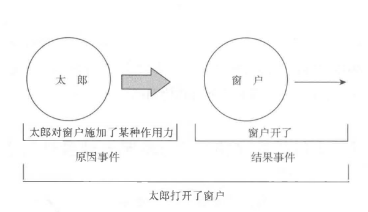

野矢：啊，原来如此。也就是说，「窓を開ける（打开窗户）」这个行为中已经包含了结果。这和现代行为学理论的观点是一致的。太郎胳膊一用力，结果窗户开了，「窓を開ける（打开窗户）」指的就是这整个过程。

西村：您不喜欢这种分析方式吧。

野矢：也不是。不过，这确实和我反对的哲学观点有些接近，但现在我还不想与之针锋相对。可我还是想说，比如「手を挙げる（把手举起来）」的「挙げる（举起来）」，不是也有「手が挙がる（手举起来了）」的「挙がる（举起来）」这样的不及物动词与之对应吗？

西村：这个嘛……

野矢：您看，不好办了吧。「手を挙げる（把手举起来）」，也可以算作致使吗？还有，我虽然承认「蓋を閉じる（合上盖子）」是典型的致使，可「目蓋を閉じる（合上眼睑）」呢？如果连这些也可以算作致使的话，那我们就得说「手を挙げた（把手举起来了）」表示的是“对手施加了某种作用力，结果手举起来了”。可是，这么分析实在有些荒唐，至少我不想这么分析。

西村：确实，您这么说也有道理。不过……，嗯……，确实不太好分析啊。

野矢：至少可以说，「手を挙げる（把手举起来）」「目蓋を閉じる（合上眼睑）」这些句子不是典型的致使吧。要是让我说的话，这些根本就不是什么致使句。只是因为「目蓋を閉じる（合上眼睑）」和「蓋を閉じる（合上盖子）」在形式上是一样的，我们便试图从「目蓋を閉じる（合上眼睑）」中也找出某种因果关系来，由此就产生了一个哲学上的误读。这个误读就是，把肢体动作看成是我们对自己的身体施加作用力后产生的结果。哦.对不起，我跑题了。咱们还是回到正题上来吧。

### 英语与日语的自他对应

西村：反观英语的自他对应，我们就会发现，英语里同一个动词既可以做不及物动词又可以做及物动词的情况极为多见，做及物动词的时候它就是致使动词。比如，“open”既可表示「開あく（开）」也可表示「開ける（打开）」，而表示「沸く（沸）」和「沸かす（煮沸）」的则都是“boil”。

野矢：的确，英语的动词一般都是既能做不及物动词，又能做及物动词。那日语呢？

西村：不及物动词和及物动词完全同形的情况应该说是极为少见的。除了「開ひらく（开）<sup>25</sup>」和「閉じる（合±）」以外，其他基本上都是不同形的。

野矢：原来如此。我「閉じる（合上）」书的结果是书「閉じる（合上）」了。原来日语里也有自他同形的动词啊。

西村：既有自他同形的情况，也有自他对应的不及物动词和及物动词（其中一方在形态上更简单）的情况。不同的语言在这一点上也会有所不同，可谓纷繁复杂。关于这个问题，也确实有人在进行相关的研究。

### 词汇型致使和迂说型致使

野矢：「読む（读）」和「読ませる（让……读）」应该不是自他对应吧？

西村：不是的。「太郎は花子に本を読ませた（太郎让花子读书了）」和「太郎は窓を開けた（太郎打开了窗户）」的一个主要区别也正是在这里。

野矢：「読む（读）」是及物动词，对吧？「読ませる（让……读）」也是及物动词吗？

西村：不，不是及物动词。

野矢：哦。那是？

西村：「読ませる（让……读）」是「読む（读）」和助动词「せる（让）」的组合。「太郎は窓を開けた（太郎打开了窗户）」这个句子里，「開ける（打开）」与「開あく（开）」是自他对应，致使义可由「開ける（打开）」这个致使动词来表示，因此我们把它叫作“词汇型致使动词”，把使用了 “词汇型致使动词”的致使句叫作“词汇型致使”。与之相对，「太郎は花子に本を読ませた（太郎让花子读书了）」这个句子里，「読ませる（让……读）」不是一个词，而是「読む（读）」和助动词「せる（让）」的组合，我们把这样的致使句叫作“迂说型致使”。

野矢：这个术语感觉好晦涩啊。“迂说型致使”这个术语，不只是认知语言学，普通语言学中也会使用吗？

西村:是的。英语里本来就有"periphrastic"这么个词，“迂说”应该是把它直译过来了。

野矢："periphrastic" ?就是"periphery”（周边）的“peri”加上“phrase”，表示“婉转间接的表达"，是吧?

西村：之所以、说它“迂说”，是因为仅靠一个词语无法表达“致使义”，要靠几个词语的组合才能表达“致使义”。

野矢：与之相对，用自他对应的及物动词造出的致使句就是“词汇型致使”。

西村：是的。我想在这里补充一个值得思考的话题。在很多语言里，都没有表达「笑わせる（让……笑）」的词汇型致使动词。英语里没有，日语里也没有。必须要通过「笑う（笑）」和助动词「せる（让）」的组合来表达。

野矢：也就是说，当太郎的一些行为引起了 “花子发笑”这个结果时，并不存在一个可以表示这整个过程的词。你只能“迂说”地去表达。哎呀，什么“迂说”啊，我怎么也开始用起这种词了，真不喜欢自己这样（笑）。

西村：「泣く（哭）」也是一样的，只能像「泣か-せる（让……哭）」这样迂说地去表达。

野矢：英语也一样。

西村：英语和日语之所以都是这样，应该是有原因的。当结果事件是「読む（读）」「歩く（走路）」「食べる（吃饭）」这样的行为时，往往不存在与之对应的词汇型致使动词，这种倾向性是很明显的。而「泣く（哭）」啊，「笑う（笑）」啊什么的，也基本可以算作一种准行为，与这一类动词相对应的词汇型致使动词在很多语言中同样很难成立。

野矢：嗯，这到底是为什么呢……是不是因为觉得「太郎は花子を歩かせた（太郎让花子走路了）」这个句子中，虽然太郎也在对花子施加作用力，但实际走路的却是花子，所以花子才应该是走的主体呢？这样一来，就有必要把「歩く（走路）」这个动词保留下来，那么它的致使结构就需要「歩く（走路）」和「せる（让）」的组合，即「歩かせる（让……走路）」来表达了。与之相对，如果是「太郎はお湯を沸かす（太郎把水煮沸）」这个句子的话，谁也不会觉得水在沸的时候是一个行为主体，只会觉得太郎是一个行为主体。于是，「沸く（沸）」这个动词就被「沸かす（煮沸）」这个以太郎为主体的动词所取代了。您看我说的对不对？

西村：您说得没错。我再说一个相关的话题。在英语里说遛狗的时候可以把“walk”当及物动词来用；而日语里即使对象是狗，应该也不能把「歩く（走路）」当及物动词来用。

野矢：日语要迂说地说「犬を散歩させる（让狗散步）」，而英语只要说“I *walked* my dog.”。按照我的理论，这说明日本人更看重狗的主体性。

西村：应该是这样的（笑）。

野矢：啊，还有这样一个句子。"Walk your dog, do not let your dog walk you.（是你遛狗，不要让狗遛你）”，还挺逗的吧。

### “死” “杀” “致死”

西村：还有一个值得思考的课题。「死ぬ（死）」和「殺す（杀）」虽然完全不同形，但一般却被视作自他对应，好像在很多语言中都是这样的。而与「沸く（沸）－沸かす（煮沸）」「焼ける（熟）－焼く（烧熟）」对应的，在很多语言中则往往都是同一个词；即便对应的是两个词，也往往是以其中一个词为基准，通过对其添加语素而得到另一个词。可是，与「死ぬ（死）－殺す（杀）」对应的，却往往是两个完全不同的词，英语的“die”和“kill”就是如此。我记得史蒂芬•平克（Steven Pinker）在他的*The Stuff of Thought* （ 2007 ）（有中译本，《思想本质：语言是洞察人类天性之窗》，张旭红、梅德明译，浙江人民出版社）中曾讲道，因为关乎杀人，所以要用和“死”完全不同的词去表达。

野矢：是因为“杀人”这件事本身的严重性吗？

西村：是的，因为杀人这个行为，不仅仅是造成“死”这个结果这么简单，还包含了很多别的因素，例如道义上的谴责。所以要用「殺す（杀）」这个与「死ぬ（死）」完全不同的词来表达这种行为。

野矢：「殺す（杀）」一定都会受到道义上的谴责吗？比如，你不会因为杀死了一个蚊子就受到谴责吧？还有，如果你杀死一个暴君的话，反而能成为英雄。

西村：其实啊，这里也需要思考一下「殺す（杀）」的原型是什么。「殺す（杀）」的原型，应该是有杀死对方的意图，且在杀死对方后既会受到道义上的谴责、也会受到刑事上的处罚的这样一种行为吧。

野矢：嗯，对。有道理。

西村：另外，除了「殺す（杀）」，我们还可以说「死なせる（致死）」。「殺す（杀）」可以说是词汇型致使动词，而「死なせる（致死）」就是迂说型的表达方式了。因为谓语「死なせる（致死）」，是由「死ぬ（死）」和「せる（致使）」两部分组合而成的。以英语为例的话，“kill”是词汇型的，“cause to die”就是迂说型的。

野矢：「死なせる（致死）」和「殺す（杀）」的意思可不一样。

西村：没错。比起「殺す（杀）」，说「死なせる（致死）」的时候，与“死”的因果关系更松散，或者说更间接。

野矢：比如，如果把「為すすべもなく死なせてしまった（是我的无能为力导致了他的死亡）」说成「殺してしまった（是我把他给杀了）」，这就太过了，对吧。因为不是我直接导致他的死亡的，虽然我也负有一定的责任。

西村：就是这样。相反，如果是「殺す（杀）」的话，则表示正是其行为导致了对方的死亡，可以说与“死”的因果关系更直接也更紧密。正因为如此，才可以用单个词语去表示这种因果关系。

野矢：明白了。表达方式上迂说的时候，因果关系上也更间接。而仅用一个单一的词的时候，因果关系上也是直接的，对吧？有意思。也就是说人们在认知方式上的直接与否，和语言表达上的简洁与否是连动的。这种连动性，除了「死なせる（致死）」，是不是也适用于其他迂说型致使呢？

西村：我认为可以这样说。前面提到过当结果事件是「読む（读）」「笑う（笑）」这样的行为或准行为的时候，词汇型致使动词往往很难成立，常常只能像「読ませる（让……读）」「笑わせる（让……笑）」这样用迂说的方式去表达因果关系，这其实也和这种连动性相关。「太郎は窓を開けた（太郎打开了窗户）」，是太郎施加的作用力直接导致了窗户的打开，而「太郎は花子に本を読ませた（太郎让花子读书了）」，则还需要花子对太郎施加的作用力做出反应。

野矢：按我刚才的说法就是，「太郎は花子に本を読ませた（太郎让花子读书了）」这句话里，花子还保留着主体性。

西村：是的。也因为如此，太郎施加的作用力和结果之间的关系也就变得间接了。

野矢：我突然又想起了一个例子。即使结果事件不是一种行为，也有可能没有对应的词汇型致使动词，比如「腐る（腐坏）」，就只能说「腐ら-せる（使……腐坏）」。这是因为，当某件事的结果我们不能百分之百控制的时候，即便施加了作用力，最后的结果也并不以我们自己的意志为转移，这时就只能用迂说的方式去表达。您看我说得对吗？

西村：我觉得可以这么说。

### “这个药应该可以让你觉得舒服一点”

西村：我们刚才讲到的可以说都是致使句的原型,接下来我们来看看致使句的周边事例。这些句子因为在形式上和我们之前看到的致使句没有什么不同，一般都被归类为致使句，但从语义上看却和我们之前看到的致使句很不一样。这样的句子数量很多。换句话说，这些句子，虽然表达的事件和我们之前看到的致使句完全不同，但在形式上却采用了致使句的句式。哪些周边事例会使用致使句，不同的语言也会有所不同。

比如无生命物做主语的致使句，在日语里很少，但在英语里却很多。我们之前看到的致使句，表达的都是人通过自己施加的作用力来有意图地引发结果事件。与此相对，当主语不是人，而是连生物都算不上的无生命物的时候，自然就谈不上“有意图地引发” 了，但在形式上有时却可以采用致使句的句式。比如，经常会举的一个例子，"This medicine will make you feel better.",这个例子直译过来就是“这个药应该可以让你觉得舒服一点”。日语一般是不会这么说的，但这种表达方式在英语里却很平常。

野矢：使你感觉舒服的虽然是药，可这并不是药有意为之的。这一点不符合原型致使句的特征，可它也是致使句。是这个意思吧。

西村：没错。

野矢：日语这个时候应该怎么说呢？大概会说「この薬を飲むと気分がよくなるよ（喝了这个药您会感到很舒服）」什么的吧。可有的时候，日语里无生命物好像也可以做主语，比如「この薬はひどい下痢でも止めてくれるよ（这个药连严重的腹泻也可以止住）」。

西村：这倒是。但无论如何，"What makes you think so ?"这个句子，日语肯定没法说吧。但这种表达方式在英语里却很平常。这句话的意思，无外乎“你为什么会这么想呢？ ”但英语里却压倒性地倾向于使用致使句来表达这个意思。

再举个例子，“This book gives you some idea of life in ancient Greece.",意思是“读了这本书，你就可以大体了解古希腊人的生活了"。英语里这个时候使用致使句也是很自然的。

野矢：这个句子，结果事件是什么呢？

西村：嗯，大概是“可以大体了解古希腊人的生活”吧。

野矢：那，「先生が生徒に教える（老师教学生）」呢？是致使句吗？虽然这个句子的主语并不是无生命物，我还是想问问。

西村：啊，这个例子可不太好判断。因为有的时候即使你教了，对方也未必能理解嘛。

野矢：这个，我深有体会啊（笑）。也就是说，只有引发了结果才能叫致使，这里不包括你为了引发该结果而做出努力的过程。

西村：关于这一"点，"That explains it."这个句子特别值得思考。“That”可以指对方说的话，当你借助对方说的话，搞清楚了一件自己以前不理解的事情的时候，就可以这么说。意思大概相当于“因为你的话我明白了”，是日常生活中经常使用的表达方式。可同样的意思，日语就没法通过无生命物做主语来表达。

野矢："That explains it.”确实是致使句。不过，如果我们把主语从无生命物换成人，比如「西村先生が野矢に認知言語学を説明した（西村先生向野矢讲解了认知语言学）」，恐怕就不好判断它是不是致使句了，对吧。

西村：确实不好判断。

野矢：那是因为不管西村先生下了多大功夫讲解，野矢他有时就是不明白啊（笑）。可“That explains it.”的主语既然没有生命，也就根本谈不上努不努力，所以这个句子只有在确实通过对方的话理解了一件事的时候才可以说。也就是说,说"That explains it."的时候，一定是伴随着相应的结果的，所以我们可以很肯定地说它是一个致使句。有意思。

西村：再举个例子。表达"Cancer kills thousands of people every year."这个句子的意思时，日语里一般也不说「がんが毎年、数十万人の人々を殺している（癌症每年都会杀死数十万人）」，对吧。

### 日语里有没有无生命物做主语的致使句

野矢：的确，您说的这些句子很难直译成日语。可日语应该也有不少无生命物做主语的致使句吧？比如谈到无障碍设施的时候，对方如果说「段差が小さいからだいじょうぶでしょう？（台阶挺矮的，应该不会有危险吧？）」，我们是不是可以回答「いや、むしろ小さな段差の方が年寄りをつまずかせるんですよ（矮台阶才更容易绊倒老年人呢）」?

西村：嗯，您这么一说.我也觉得未尝不可……。但，这个句子和「年寄りは小さな段差につまずくんですよ（老年人更容易绊倒在矮台阶上）」的不同之处在哪儿呢？

野矢：说「小さな段差が年寄りをつまずかせる（矮台阶绊倒老年人）」时，比起「小さな段差につまずく（绊倒在矮台阶上）」，是不是更让人感觉到对台阶的敌意呢？另外，我预先还准备了一些例子，像是「紫外線が肌を老化させる（紫外线会使肌肤老化）」「塩酸は鉄を溶かす（盐酸可以使铁溶化）」「トラックが塀を壊した（卡车撞坏了墙）」，您看这不是有一大堆例子吗？当我们想特别聚焦事件的原因部分时，就会很自然地这么说。还有比如「トカレフが男の頭を撃ち抜いた（托卡列夫手枪击穿了男子的头部）」。

西村：小说里才会这么说吧。

野矢：而且是硬汉派小说。这种表达方式可能多少还是有点翻译的味道吧。不过，虽说有点翻译腔，但至少可以说这种表达方式已经大量渗透进了日语的书面语。我想，今后这种以无生命物为主语的致使句也会越来越多吧。当然，我承认一般我们不这么说。

西村：有一个叫张伯伦（Basil Hall Chamberlain ）的英国人，当时任教于东京大学博言学科（语言学当时叫博言学），他是第一个在日本教授语言学的外国人。他曾经提到过一个句子，好像原文的大意是“暑热让我感到很疲乏”吧，因为日语没法表达出英语原文的意思，他就说这体现了日语表达力的缺失。而夏目漱石后来也举过很多英语的例子，这些例子直译成日语后很像拟人句，夏目漱石认为“日语这样表达给人感觉很做作，很不好”。不过，其实夏目漱石自己是经常使用这种拟人句的。

野矢：哈哈（笑）。如今，像村上春树这样的作家，应该很喜欢使用这种无生命物做主语的致使句吧。

西村：嗯，村上春树确实经常使用无生命物做主语的致使句。

野矢：如果不限于致使句的话.日语里无生命物做主语的句子应该也有很多吧？

西村：是的。无生命物做主语的句子，比如「財布が落ちてる（钱包掉了）」「雨が降ってる（下雨了）」「塀が倒れてる（墙倒了）」，日语里也是应有尽有的。并不是说“日语相比于英语缺少无生命物做主语的句子”，我们想说的是，当谓语动词具有像「せる」「させる」这样的致使义时，英语普遍可以以无生命物做主语，而日语这种情况很少见。一般比较严谨的书都会这样注明。

野矢：无生命物做主语并不难，可表达无生命物对其他物体施加作用力的句子却很难成立。这到底是为什么呢？明明是日本人更相信万物有灵啊。

### 工具做主语的致使句

西村：下面举的“工具做主语的致使句”，应该是无生命物做主语的致使句中的一个小类，或者说是比较特殊的一类。这类句子，也是在英语里很常见（至少在满足一定条件的情况下很常见），但在日语里却不太容易成立。

因为这种句子在日语里很少见，所以我只能举英语的例子，希望野矢老师您不要不高兴。比如，"This key opens the door."把钥匙递给别人时，英语里这样说再自然不过，但日语里却只能说「そのドアはこの鍵で開きますよ（那个门用这把钥匙开）」。钥匙毫无疑问是无生命物，所以这个英语句子自然是无生命物做主语的致使句，但我们却往往把这样的句子专门命名为“工具做主语的致使句”。其独特之处就在于，开门的时候一定存在开门的人，明明是这个人用钥匙开了门，我们在表达的时候却把开门的人放到一边，反而把作为工具的钥匙放到了主语的位置上。

还有比如"It is this gun that killed him.”什么的。

野矢：我还是想举几个日语的例子，比如「この鍵は全ての部屋を開けてくれるんだよ（这把钥匙能打开所有的门），您怎么看这个句子？

西村：这个句子好像可以说。

野矢：是吧。这句话的关键，其实在「全て（所有）」上。还有刚才我举的「この薬はひどい下痢でも止めてくれるよ（这个药连严重的腹泻都可以止住）」，我为了使这个无生命物做主语的致使句听起来自然，特意说的是「ひどい下痢（严重的腹泻）」，而不是一般的腹泻。

西村：我都没注意到您还有这样的设计。

西村：您这么一说我想起来，关于工具做主语的致使句的论文中，我看到过一个英语的例子，大概意思是“这支笔可以画很细的线”。这个句子之所以可以成立，也是因为画的是“很细的线”，如果只是说“画线”的话，句子好像就不能成立了。

野矢：“这支笔可以画线”，简直不知所云嘛。

### “花子让风把帽子吹跑了”

西村：最后我想举的这类致使句的特点是，虽然是人做主语，但却并不是由这个人“有意图地引发了结果”。比如，「太郎は友だちとキャッチボールをしていて窓ガラスを割ってしまった（太郎和朋友玩棒球的时候打碎了窗玻璃）」「花子はリンゴの皮をむいていたら指を切ってしまった（花子削苹果皮的时候切到了手指）」之类的。

野矢：我们在做一件事的时候，无意间引发了另外一件事情的发生。比如，没想打碎玻璃却把玻璃打碎了，切东西时没想切着手却切着了手，等等。

西村：另外，这类致使句还有一种情况，就是做主语的人其实什么都没做。比如，「花子は風で帽子を飛ばしてしまった（花子让风把帽子吹跑了）」<sup>26</sup>。我还没有做全面的调查，不过这类致使句与刚才的无生命物做主语的致使句似乎恰好相反，英语里不能成立的情况很多。「花子は風で帽子を飛ばしてしまった（花子让风把帽子吹跑了）」这个句子，在英语里就很难让花子做致使句的主语。

还有比如说，「太郎は昨日財布を落とした（太郎昨天把钱包弄丢了）」<sup>27</sup>，英语里可以说“Taro dropped his wallet yesterday.",但印度尼西亚语却不能说。我以前指导过一个来自印度尼西亚的研究生，他日语说得非常好，但就连他一开始也不能理解“日语为什么会这么表达”。他说，从印度尼西亚语的语感去理解的话，还以为是太郎有意地、故意地把钱包弄丢了呢。

野矢：在这个学生看来，钱包既然不是有意弄丢的，那就只能说「落ちる（掉）」，不能说「落とす（弄丢）」。我估计这个学生也理解不了「単位を落とす（丢掉学分）」<sup>28</sup>这个说法吧。因为在他看来，学分既然不是有意丢掉的，那就只能说「落ちる（掉）」，不能说「落とす（丢掉）」。

### 被动和致使

西村：还有一个对我来说非常值得思考的例子，就是「花子は交通事故で息子を死なせてしまった（花子因为交通事故导致了儿子的死亡）」。这个句子里，花子其实什么都没有做。但即便如此，当自己的孩子因为交通事故死掉的时候，日语里确实在某些情况下可以这么说。

这个例子之所以有趣，是因为……

野矢：瞧您幸灾乐祸的样子。

西村：不好意思（笑）。这个例子之所以从胃方竽的角度看非常有趣，是因为还存在「花子は交通事故で息子に死なれてしまった（花子因为交通事故死了儿子）<sup>29</sup>」这样的与之对应的被动句。也就是说，同样的事件，日语里既可以用致使句，也可以用被动句去表达。一般我们都会认为，被动和致使不是几乎完全相反的两个句式吗？毕竟，致使指的是主语所指的对象造成了某个事件的发生；而被动指的是某个事件发生在了主语所指的对象身上嘛。为什么可以用被动句去表达的事件，也可以用致使句去表达呢？这大概就是这个现象被关注的原因之一吧。

野矢：您这个问题确实也值得思考。被动和致使一般意思是不一样的。比如，我们逮着一只甲壳虫（结果它跑了）时，说「逃げられた（被……逃走了）」和说「逃がした（把……给放走了）」，二者意思完全不同。「太郎はつかまえたカブトムシを逃がした（太郎把逮着的甲壳虫给放走了）」这句话，应该算原型致使句吧？

西村：是啊。因为是太郎通过对甲壳虫施加作用力，有意图地引发了 “甲壳虫逃走”这个结果事件嘛。

野矢：还有，从「殴られる（被人打）」和「殴らせる（让<sup>30</sup>人打）」这两个例子中，也能看出被动和致使在语义上有多么不同。比如，你在练习剑道的时候被别人打了脸，你可以说「いや、あれはわざと打たせたんだ（不，我刚才是故意让他打的我）」，以示你是故意没做防备:这个例子虽然不算很典型的致使句，但还是可以从中看出被动和致使之间有很大区别。客观上你能看到的，可能只是从太郎手中飞走了一只甲壳虫，或是一个人被别人打了脸。但你用被动句表达还是用致使句表达，可以说呈现出的是一个事件的两种完全相反的样貌。

现在来看「花子は交通事故で息子を死なせてしまった（花子因为交通事故导致了儿子的死亡）」。这个句子中，花子既没有对儿子施加任何作用力，结果也绝非她所愿。所以，从客观事实上看，这个句子与致使句的原型差别很大，但我觉得我们还是能从中找到原型致使句识解事件的方式。也就是，把儿子死于交通事故这个事实描述成好像是花子通过自身行为有意引发的一样。这里反映了说话人对这件事的态度。

西村：是的。明明有可能阻止却最终没能阻止事件的发生，结果导致了儿子的死。说话人关注的应该正是花子的这种自责的心情。

野矢：可在说「花子は交通事故で息子を死なせてしまった（花子因为交通事故导致了儿子的死亡）」这句话时，应该并不是真的觉得花子本来可以阻止事件的发生吧。准确地说应该是，虽然明知道花子并不能阻止事件的发生，但却故意说得好像花子本可以阻止事件的发生似的。故意不用被动而用致使，就是为了表达说话人的这种心情。即不光描述事实，还把致使句这个句式中蕴含的语义也投射进去。是这样吧。

西村：其实也有人认为这个句子从语义上看不是致使句，理由是该句中的结果事件并不是花子有意图地引发的。但我觉得，说话人其实只是想通过使用致使句的句式，来告诉我们他在用致使式的方式来识解这个事件而已。

### 日本人和致使句

野矢：前面您告诉我说，「花子は風で帽子を飛ばしてしまった（花子让风把帽子吹跑了）」这个致使句英语不说，还有「太郎は昨日財布を落とした（太郎昨天把钱包弄丢了）」很难翻译成印度尼西亚语。那么，这种不同到底是因为什么呢？我们应该好好思考一下。我想这也许体现了日本人的某种精神特质：即使自己什么都没做，可还是会觉得事情的发生自己有责任。其实比起致使句，我觉得总的来说日本人应该是更喜欢使用被动句的。但偏偏「風で帽子を飛ばしてしまった（让风把帽子吹跑了）」这样的表达方式，日语倒是比英语常见，是吧？

西村：这其实有可能和日本人特别喜欢道歉这一点有关。比如你向别人借了一个CD播放器，自己并没有做什么，但CD播放器却不出声了，那么归还播放器的时候日本人通常都会先说「ごめんなさい（对不起）」道个歉，然后说「こわしてしまいました（我不小心把它弄坏了 ）」。但同样的情况，美国人只会说“It broke."。关于这个问题，也有专门的研究成果。

野矢：有道理。假如有人把借走的东西还回来的时候只说一句「こわれたよ（它坏了）」，我们听了肯定得恼火。这是不是说明日本人有过度在自己身上追究责任的精神特质呢？

### 致使句的原型

西村：刚才我们看到了种类繁多的致使句，但要想在所有这些致使句中提取出一个共通且唯一的语义特征，抑或是致使句的“本质义”，应该是不太可能的。以往的研究可能只会说“存在本应使用被动句实际却使用了致使句的情况，但具体是为什么就不知道了”，但站在认知语言学的角度，我们想说“使用致使句的原因其实是可以分析的”。具体来说，就是用原型和以原型为中心的语义扩展的角度，去把握致使句这个语法范畴的语义基础。

野矢：致使句并不存在什么本质义，对吧？

西村：应该是不存在的。

野矢：所以，我们不能从“本质义”的角度去理解致使句这个语法范畴，而应把这个范畴看作是一个具有家族相似性的大家庭。也就是说，理解语法范畴的时候.我们也应该完成从古典范畴观到原型语义观的转换，对吧？

西村：是的。也就是说，对于语法范畴，也可以像分析一般的词或词项时那样，从原型的角度去分析。举一个词的例子，很多语言里都有相当于日语的「赤（红）」的词，但这些“红”所表示的颜色范围却不一定完全一致。有的语言，可能偏橘黄色的颜色也属于该范畴，而另一些语言则相反。但不管是哪个语言的“红二其颜色范围中都有一部分是共通的。

野矢：每个颜色都有“焦点色”，且“焦点色”是人类共通的（Berlin and Kay, *Basic Color Terms*, 1969）。您说的是这个研究吧。在此之前的研究普遍认为，光谱的切割方式（比如光谱上从哪儿到哪儿是红色）是任意的，且因语言、文化的不同而多有不同。但在此之后的研究开始认识到，我们在认识颜色的时候至少在焦点色这一点上是共通的。

西村：是的，不管是哪个语言，都可以用与“红”对应的那个词去指称红的焦点色。但对于那些不同程度偏离焦点色的颜色，与“红”对应的那个词能够覆盖到哪里，则每个语言各有不同。同理，致使句的原型也是所有语言共通的。但由原型出发，向什么方向扩展、可以扩展到什么程度，则每个语言各有不同。这就是我们的分析框架。

回到致使句的话题。首先，比起迂说型致使，词汇型致使应该是更典型的致使句。而在词汇型致使中，则是「太郎は窓を開けた（太郎打开了窗户）」这样的句子更典型，即表达“某人（主语）为了使某对象发生特定的变化而有意图地对其施加作用力，结果使该对象立刻发生了预想中的变化”的句子是原型。

野矢：可是，决定是不是原型的人又是谁呢？是我们，还是你们认知语言学家？我的意思是，比如谈到鸟类的时候，大家都同意麻雀、乌鸦等更典型。这一点有实验结果佐证：人们把麻雀认知为鸟类所花的时间要比认知鸭子的时候短。而致使句，您刚才说「太郎は窓を開けた（太郎打开了窗户）」是原型，无生命物做主语的「塩酸は鉄を溶かす（盐酸可以使铁溶化）」和意料之外的「財布を落とした（把钱包弄丢了）」是周边事例。那我想问您，这到底是语言使用者自己这样认为的呢，还是认知语言学家为了契合自身的理论而这样设定的呢？

西村：应该是语言使用者这样认为的。

野矢：是吗？我怎么一点也感觉不出「塩酸は鉄を溶かす（盐酸可以使铁溶化）」是更边缘性的致使句呢。

西村：在语言习得中，它的习得更晚，这应该是没错的。

野矢：那是因为接触到“盐酸”这个词一般比较晚。而「財布を落とした（把钱包弄丢了）」呢，可能是因为小孩根本就没有钱包。如果换作是布娃娃的话，应该很早就会说「クマちゃんを落とした（把小熊弄丢了）」吧。无生命物做主语的致使句也是一样的，只要不是“盐酸”这样的生僻词，英语母语的小孩一定也很早就会说了吧。

西村：这一点其实不然。有关日语的研究我不太清楚，但关于英语确实有这方面的研究。比如.“把气球弄破了”这样的句子到底是故意把气球弄破的时候容易说，还是偶然因素导致气球破了的时候容易说呢？研究结果显示，是前者，或者应该说是前者的习得更早。我想这一点日语应该也是一样的。

野矢：有道理。也就是说，只要多调查一些语言，我们就能了解到致使句也和焦点色一样，有所有语言共通的语义特征，也有因语言而异的部分。共通的那部分，就是致使句的原型，对吧？

西村：就是这样。正因为如此，「太郎は窓を開けた（太郎打开了窗户）」这样的致使句才在所有的语言里都能见到。

野矢：明白了。

### 无生命物做主语的致使句和隐喻

西村：我们之前已经大体讲解了致使句是如何从其典型成员的原型语义逐步扩展到周边成员的。现在我们就来重新梳理一下。首先，我们来看一下无生命物做主语的致使句。

比如,"Cancer kills thousands of people every year.（癌症每年会杀死成百上千的人）”，或者「突風が屋根を吹き飛ばした（暴风把屋顶刮跑了）」。这些都可以看作一种隐喻，好像癌症和暴风真的在做什么似的。

野矢：是拟人吗？

西村：也可以这么说。但是，像“That explains it."就很难说是拟人了吧。

野矢：这里的“that”指的是对方说的话，是吧？

西村：是的。这个句子的意思大体相当于“你刚才说的话，把之前我一直不明白的事情解释清楚了”。但至少在一般意义上，很难想象“你刚才说的话”本身做了什么动作。还有"What makes you think so ?（什么让你这么认为？）”这样的句子，也很难想象句子的主语做了什么动作吧。

这些句子，我们其实可以把主语所表示的事物的存在或出现看作原因事件，而这是与原型致使句的语义特征相通的地方。无生命物做主语的致使句，正是基于此才得以存在。

野矢：我下面说的可能有点跑题。认知语言学认为，「突風が屋根を吹き飛ばした（暴风把屋顶刮跑了）」「塩酸が鉄を溶かした（盐酸使铁溶化了）」这些致使句是从「太郎が窓を開けた（太郎打开了窗户）」这样的致使句派生出来的。这个观点，其实从哲学角度上看也很有价值。

西村：怎么讲？

野矢：我们探讨的这些有关致使句语义的问题，说到底，其实都与我们怎么理解因果关系分不开。

西村：是。

野矢：还有，认知语言学认为，“人通过自己的行为引发了某种预料中的结果”要比“因为癌症、大风、盐酸等原因导致了某种结果的产生”在因果关系上更典型。这说明，我们是通过人的行为来理解什么是典型的因果关系的。首先从人的行为中提取出“因果”这一范畴，然后再把它投射到人的行为以外，特别是自然现象±o我这么说没错吧？

西村：没错。

野矢：我个人，从哲学角度上讲，是支持这个思路的。只是当代哲学的主流并不是这样的。

西村：这样啊。

野矢：您想啊，“在自然现象中发现的因果关系，本质上都是一种拟人”。这不像是自然科学家会说出来的话吧。

西村：还真是。

野矢：另外，我觉得能不能造出无生命物做主语的致使句，还和致使句的另外一个重要特征“责任”有关。我们时常会问，“产生了这样的结果，到底是谁的责任啊？ ”结果是好的，我们就会想该表扬谁；如果结果不好，又会想该埋怨谁。

西村：确实就像您说的那样。在日语里，如果是不好的结果的话.我们会说（都怪～），如果是好的结果，我们会说「～のおかげで（多亏了～）」。（顺便说一句，英语里不管是哪种情况，都可以用responsible这个词。甚至是像“Cigarette smoking is responsible for about 90% of deaths from lung cancer （死于肺癌的人中90%是因为吸烟）”这样的只表示单纯因果关系的句子也可以用responsible。）

野矢：刚才您不是说日语里无生命物做主语的致使句很少吗，我也一直在想为什么。您看会不会跟下面这个原因有关系呢？日本人对自然现象往往抱着一种万物有灵的观念，所以无生命物做主语本身其实不是问题。可仅仅满足这个条件，还做不了致使句的主语。致使句还要求，我们可以把结果的发生归结为主语的责任。日本人虽然相信万物有灵，但并没有把自然看作自己所属社会的一员，因此也就不会去向自然追究责任。无生命物很难做致使句主语的原因，大概就在于此吧。

西村：有道理。但「悪天候のせいで試合は中止になった（都怪坏天气，比赛取消了）」这样的句子应该还是可以说的吧。

野矢：哦，也对。这个句子好像确实是把责任转嫁给坏天气了。不过，我这么说虽然没什么依据，但日本人应该还是不太习惯向大自然追究责任吧。如果是好事儿，日本人会觉得那是大自然的恩赐；要是坏事儿呢,就会逆来顺受地接受现实。这么一想，您不觉得日本人喜欢用“受害被动”也和这一点有关吗？喜欢追究责任的人用致使句，容易逆来顺受的人就用间接被动句。

西村：似乎可以这么说。如果真的是这样的话肯定很有趣。但目前我还不敢断言。

野矢：抱歉，我总是信口开河。

西村：您别这么说。

### 工具的行为

西村：下面我们来看看“This key opens the door. v这样的工具做主语的致使句吧。它们也是无生命物做主语的致使句，但与刚才看到的那些无生命物做主语的致使句不同的是，工具做主语的致使句中其实是存在有意图地引发结果事件的人的。明明可以以人为主语、用符合原型致使句的方式去表达事件，却偏偏要以工具为主语。

换句话说，就是虽然存在可以做原型致使句主语的施事，却将其搁置一边，反而把工具识解成了致使句的行为主体。这大概是因为，我们感到对结果事件的发生来说，施事使用的工具比施事起到的作用更大，这时我们就容易让工具做主语。

野矢：刚才我们说到，无生命物做主语的致使句是一种隐喻。那工具做主语的致使句，是不是可以说是一种转喻呢？

西村：是的，可以这么说。我还是先简单介绍一下“转喻”吧。打个比方，我们会把戴着小红帽的小女孩叫作“小红帽”。当本应该用来指称X （小红帽）的语言形式被用来指称与X存在密切联系的丫（小女孩）的时候，就是“转喻”。因此，工具做主语的致使句也可以说是一种“转喻”。

野矢：果然。毕竟在一个人用钥匙开了门这个事件中，这个句子只聚焦了钥匙这个局部嘛。既然无生命物做主语的致使句是一种隐喻，工具做主语的致使句是一种转喻，那我们是不是可以说二者都是原型致使句的“比喻性派生形式”呢？

西村：是啊。不过更准确地说，工具主语因为也是无生命物主语的一种，所以工具做主语的致使句，不但具有通过聚焦钥匙这个局部来表达整个事件的“转喻”特征，也具有把钥匙识解为行为主体的“隐喻”特征。

### 扩展为“没有预料到的结果”

西村：另外，像「太郎は友だちとキャッチボールをしていて窓ガラスを割ってしまった（太郎和朋友打棒球的时候把窗户打碎了）」这类致使句，主语虽然是人，但引发的结果却是没有预料到的。这类句子，和原型致使句的共通之处是，都是因为太郎的某种行为造成了窗户被打碎的结果；但和原型致使句不同的是，其造成的结果是事先没有预料到的。这种语义扩展想来是很好理解的。但在一些语言中，如果结果是没有预料到的，就不能或者很难使用致使句。基于此，把这类致使句看作是原型致使句的语义扩展应该说是比较恰当的。

野矢：原型致使句中，“因果” “意图”“责任”这三点是捆绑在一起的。但“责任”是无论行为是否有意，都会被人追究的。太郎和朋友玩打棒球的时候不小心砸了人家的窗户，尽管不是故意要砸的，太郎也要承担责任。所以，这里虽然“意图”这个要素不满足，但“因果”和“责任”这两个要素依然存在。是这样的吧。

### 什么也不做也是一种行为

西村：下面我们来看另一种情况：某人虽然没有做出引发对象变化的任何行为，但因为我们认为这个人有能力阻止该结果事件的发生，所以便会向其追究责任。这种情况下，什么都不做也会被看作是一种行为。特别是被期待做出某种行为却偏偏没有做的时候。我们把这种情况叫作“不作为”，“不作为” 一般也被视为行为的一种。比如，“旷课”“无视”等等。

「花子は風で帽子を飛ばしてしまった（花子让风把帽子吹跑了）」「花子は交通事故で息子を死なせてしまった（花子因为交通事故导致了儿子的死亡）」这类致使句，也是因为把什么都没做看成了一种行为，才会使用「飛ばした（吹跑了）」「死なせた（导致了死亡）」这样的表达方式。

当行为主体什么都没做却引发了结果事件时，我们称之为“允许性致使”。更准确地说，就是“一个人明明具有阻止事件发生的能力，却没有发挥这种力量，从而导致了结果事件的发生”这样一种情况。

野矢：「花子は風で帽子を飛ばしてしまった（花子让风把帽子吹跑了）」这件事中，花子明明可以阻止帽子被吹跑，可她却没有行使这个“阻止力”，结果帽子被吹跑了。是这个意思吧。

西村：我们有时会把“允许性致使”以外的致使句称作“纯致使”。毋庸置疑，二者既有共通点，也存在差异。

共通点是，做主语的人或物，可以控制结果事件的发生。无论是“纯致使”还是“允许性致使”，当结果事件发生的时候，做主语的人或物都要被追究责任。

另一方面，二者的不同点是，“纯致使”是正因为有该人或物的存在，才导致了结果事件的发生；而“允许性致使”则是虽然有该人或物的存在，却还是导致了结果事件的发生。

野矢：「太郎が窓を開けた（太郎打开了窗户）」，是正因为有太郎在，窗户才会开。「花子は風で帽子を飛ばしてしまった（花子让风把帽子吹跑了）」呢，是花子明明在场，可帽子还是被风吹跑了。

我又重新想了想刚才说的“因果”“意图”“责任”这三点。「花子は風で帽子を飛ばしてしまった（花子让风把帽子吹跑了）」里缺少“意图”这个要素，但因为“因果”“责任”这两个要素还满足，所以还可以使用致使句。相比之下，袖手旁观、故意什么也不做的时候，不仅满足了 “因果”“责任”，“意图”这个要素也满足了，所以可以说更接近致使句的原型，是不是？

西村：所以才会说，不作为基本上就是一种行为嘛。

野矢：没错。明明知道袖手旁观的话受伤的人就没命了，但却故意不去救他，就那么看着他死。这已经可以说是“谋杀” 了吧。

西村：通过以上对致使句的分析，现在是不是更能切实理解第二讲所说的“语法和语义紧密相联”的内涵了呢？

首先，致使句这个语法项本身是具备语义的。其语义特征，就原型致使句而言，就是“某人（主语）对其他对象直接施加作用力，并使该对象立刻发生了预料中的变化”这样一种图式性语义。

而「開ける（打开）」「落とす（弄丢）」这些致使动词的原型语义，则是原型致使句的上述图式性语义的一种具体呈现。「開ける（打开）」有意图地引发的结果是「開く（开）」，于是致使句的图式性语义具体呈现为“某人（主语）对其他对象直接施加作用力，并使该对象立刻发生「開く（开）」这样一种预料中的变化”，而这也正是「開ける（打开）」这个词的语义。同理，「落とす（弄丢）」这个词的语义就是“某人（主语）对其他对象直接施加作用力，并使该对象立刻发生「落ちる（掉）」这样一种预料中的变化”。也就是说，致使动词具体指定了结果事件的种类，是对致使句的图式性语义的具体化。由此可见，致使动词这样的词项所具有的语义，和致使句这样的语法项所具有的语义紧密相连，不可分割。

野矢：可在我这个外行看来，比起原型，那些偏离原型的异类反而更有趣一些。特别是刚才通过比较日语和英语，我们看到致使句怎样从原型进行扩展，其实各个语言都不一样。这一点让我不禁浮想联翩。

西村：我想起一个相关的话题。堀田善卫<sup>31</sup>去世的时候，朝日新闻刊登了追悼他的文章，其中有一段内容是他自己写的。东京被空袭烧成荒野后，昭和天皇前来视察。那些房子被烧毁的人们对天皇说的话竟然是「陛下、みんな焼いてしまいまして、ほんとうに申しわけありません（天皇陛下，全都给烧了，对不起）」。本应该说「焼かれてしまった（全都被烧了）」，可实际上说的却是「焼いてしまって（全都给烧了）」，还对天皇谢罪。堀田善卫对此表示难以理解。我不确定堀田善卫实际到底说没说过“不能理解”，但他肯定说过“说这样的话的日本人到底是怎样一群人啊”。

野矢：是啊，到底是怎样一群人呢。

1. “致使动词”，指的是本身内含“致使义”的动词。在普通语言学中，“致使动词”既包括像「開ける」“打开”这样的本身既内含“致使义”、又内含“致使方式”的动词，也包括「せる／させる」“叫/让/给”这样的只内含“致使义”的动词。而在汉语语言学和日语传统的国语学研究中，“致使动词”却往往仅限于「せる／させる」“叫/让/给”这样的只内含“致使义”的动词。本书中“致使动词”的所指范围，依据的是普通语言学的标准。
2. 日语中把及物动词和不及物动词称作“他动词”和“自动词”。因此“自他对应”指的是不及物动词和及物动词的对应关系。
3. 汉语、英语中也存在类似的现象，比如“开了门”和“门开了”、“opened the door”和44the door opened”。但汉语语言学和英语语言学中，一般把这种现象叫作“致使交替”、“起动致使交替”、“作格交替”等，而不是“自他对应”。这是因为，汉语和英语往往是同一个词（“开”、“open”）既可做及物动词，又可做不及物动词，即同一个词的“交替”；而日语中，则往往是及物动词和不及物动词在共享同一个词根的基础上，在词缀上有一定的形态差异（比如「開ける－開く」），因此只能说它们是一种“对应”。因为汉语、英语的“交替”现象，广义上说也是一种“对应”，因此可以说汉语、英语的“交替”现象是“自他对应”的其中一种。
4. 日语里的自他对应，往往都是及物动词和不及物动词在共享同一个词根的基础上，在词缀上有一定的形态差异，如「沸く－沸かす」。为了使读者更直观地理解日语的这种特点，我们在翻译时也进行了差异化处理，如“沸-煮沸”。但这不意味着在汉语中一方只能做及物动词，另一方只能做不及物动词。汉语的动结式复合动词（“煮沸”），很多时候都是既可以做及物动词（“我把水煮沸了”）又可以做不及物动词（“水煮沸了”）的。
5. 日语的「開く」有两个读法，读「あく」的时候是不及物动词，读「ひらく」的时候则既可以做及物动词又可以做不及物动词。
6. 此句字面意思为“花子因为风把帽子吹跑了”，「で」是表原因的格助词。
7. 此句字面意思为“太郎昨天把钱包弄掉了”，「落とす」这个动词的字面意思是“弄掉”。
8. 此句字面意思为“弄掉学分”。
9. 字面意思为“花子因为交通事故被儿子死了”。
10. 汉语的“让”既可用于致使句，也可用于被动句。这里的“让人打”是致使句的用法，表示“要求别人打自己”。
11. 堀田善卫（1918—1998）,日本著名小说家、评论家。

## 第五讲如何看待转喻

野矢：我们这一讲的主题“转喻”，是您主要的研究课题，对吧？

西村：您这么一说，我好紧张啊。

野矢：上一讲我们也提到了一点关于转喻的话题,这里能不能请您再简单地说明一下什么是转喻？

西村：那就还是用“小红帽”的例子吧。“小红帽”这个词本来指的是红色的小帽子，但在“小红帽”这个故事里，指的却是戴着小红帽的小女孩。这就是传统意义上典型的转喻。传统语言学认为转喻的特征是，一个语言形式不是被用来指称其通常所指的对象，而是被用来指称与之处于邻近关系的对象。在这一讲里，我想探讨一下这种传统观点是否合理，并追根溯源，探讨一下转喻这种语言现象得以产生的机制。

在欧洲，从公元前一直到19世纪末，修辞学都是基础教育的重要科目之一。在传统的修辞学中，转喻是比喻中很重要的一种，被定义为“基于邻近关系的比喻”。可这里的“邻近关系”到底指的是什么呢？围绕这个问题，可以说存在着各种各样的分类和分析。

野矢：转喻在修辞学中的地位我明白了，那在语言学中呢？

西村：在语言学中，不管是隐喻还是转喻，都没有得到什么关注。转喻受到关注，大概也就是这25年左右的事情。

### 这也算转喻吗

野矢：进入讨论之前，我希望您能再多举几个具体的例子，因为我总觉得“小红帽”并不是一个特别好的用来理解转喻的例子。我们有时也会把“德克萨斯州”叫作“德克萨斯”或者“德州”，可这显然并不是转喻，而只是一种省略。所以像我这样的外行，就会觉得“小红帽”也只不过是对“戴小红帽的小女孩”的一种省略而已。

西村：有道理。实际上，很多例子都可以解释成单纯的省略。要想证明那不是省略其实非常难。

当我们说“我最近在读村上春树”的时候，“村上春树”这个词的用法是一种转喻——因为我们在用指称村上春树这个人的语言形式去指称他的作品——，但这个例子，要想说它是“我最近在读村上春树的小说”的省略,也不是说不通。在语言学家中，也确实有人认为这是一种省略。是省略还是转喻的讨论，一旦开始会相当麻烦。

野矢：还真是这样啊，看来在是转喻还是单纯的省略这个问题上还是有争议的。不过有争议也没关系，您能不能再讲几个认知语言学中的转喻的例子？还有什么样的例子呢？

西村：嗯，比如像「鍋が煮えている（锅里的东西煮熟了）」<sup>32</sup>。这句话说的不是锅本身的状态，而是锅里的东西煮熟了，对吧。

像这样的转喻，其实已经固化在语言中了。听到「鍋が煮えている（锅里的东西煮熟了）」，我们一定能明白它是在说“锅里的东西煮熟了”，句子的意思既不需要我们费心思去揣摩，也不需要我们依靠语境、上下文去判断。但还有一些新生的转喻，它的意思是需要参考语境才能理解的，这样的转喻每天都在产生。比如，当我们和以前一起去过长野<sup>33</sup>的同事久别重逢的时候，可以说「長野は楽しかったね（长野真开心啊）」。这里的“长野”，指的不是地理区划上的长野，而是和同事一起去过的长野旅行。

野矢：“今晚的小提琴可真不错啊”这句话可以用来描述小提琴的演奏，可如果没有具体的语境，我们就无法确认这句话说的到底是“乐器不错”还是“演奏不错”。像这样的转喻，我想应该是只在共享同一个语境的人们之间才能成立的吧。

西村：应该是这样的。另外，还有一些例子，会让人不禁想问“这也算转喻吗？ ”比如，一直致力于比喻研究的濑户贤一先生曾经举过几个有名的例子，「電球が切れる（灯泡坏了）」<sup>34</sup>「自転車をこぐ（蹬自行车）」「洗濯機を回す（操作洗衣机）」<sup>35</sup>，这些也都被认为是转喻。比如，「電球が切れる（灯泡坏了）」，断的不是灯泡本身，而是灯泡里的灯丝。而「自転車をこぐ（蹬自行车）」，准确地说，实际情况应该是“蹬自行车的脚蹬子”。

野矢：「洗濯機を回す（操作洗衣机）」，这解释起来可费劲了。（笑）

西村：转的是洗衣机的什么呢……

野矢：老式的洗衣机的话，转的应该是内筒下方的螺旋桨（专业术语好像叫“波轮”）；新式一点的洗衣机的话，应该是在转滚筒吧。不管怎么说，反正都不是在转洗衣机本身。

西村：上述这些例子中，语言形式实际所指的都不是其字面所指的对象，而是与之处于邻近关系的对象。因此，这些都是转喻的例子。

野矢：可是，说「自転車をこぐ（蹬自行车）」中「こぐ」的对象不是自行车而是脚蹬子，这个说法我不太赞成。「自転車をこぐ（蹬自行车）」想说的明明就是自行车，怎么可能是脚蹬子呢？我觉得，「自転車をこぐ（蹬自行车）」的「自転車（自行车）」，指的就是字面意思的自行车，而不是什么脚蹬子。而有比喻义的，倒不如说是「こぐ」。「自転車をこぐ（蹬自行车）」的「こぐ」，指的就是用某种方法使自行车前进<sup>36</sup>。是不是可以这么想？

西村：其实我也是这么想的。如果前进的是自行车，那么「こぐ」的对象也应该是自行车才对。

野矢：我也觉得这么想更自然。说「自転車（自行车）」指代的是脚蹬子，这种说法我总觉得有点别扭。

### 转喻和一词多义

西村：如果连「自転車をこぐ（蹬自行车）」和「洗濯機を回す（操作洗衣机）」这样的例子也算转喻的话，那转喻的例子真的可以说是无处不在了。比如，我个人非常感兴趣的一个例子，“按警报器”和“警报器响了”。按的部位和响的部位其实不同。

野矢：是啊，那“警报器”这个词，通常指的到底是按的部位呢，还是响的部位呢？

西村：警报器按和响的部位很多时候都不在一处。这样一来，“按警报器”和“警报器响了"，按的部位和响的部位到底哪个才是“警报器”这个词通常所指的对象，就不好说了。我觉得，不如把二者的地位看成是对等的，也就是说，二者互为转喻关系。

再举一个例子。稍早以前，当录像时录像带不够用了的时候，日语里常会说「ビデオが切れる（录像带不够用了）」<sup>37</sup>。但除此之外，日语也会说「ビデオを見る（看录像）」「ビデオを朝八時にセットした（把录像设定在了早晨八点）」。在这些例子中，「ビデオ（录像）」一词本来指的对象到底是什么，同样很难确定。因此，还是把它们看作互为转喻关系比较好。

野矢：有道理。可是，如果两个义项互为转喻关系，会不会容易与一词多义混淆，搞不清楚到底是转喻还是一词多义呢？

西村：我个人认为，这可以看作是一种“转喻性的一词多义”。

野矢：可是，我认为一词多义和转喻的根本区别，在于转喻的单向性。比如，我们可以说「鍋が煮えている（锅里的东西煮熟了）」，即可以用“锅”指代锅里的东西；但反之则不然，我们不能用“锅里的东西”指代锅。也就是说，语义指向发生了从锅到锅里的东西的转移。发生了这种语义指向的转移的，才是典型的转喻。而一词多义呢，我觉得很难说发生了上述意义的语义指向的转移，各个义项间应该是一种并列、对等的关系。所以，刚才当您提出“互为转喻关系”这个说法的时候，我就有点担心会不会和一词多义发生混淆。

西村：我个人是希望把两者统一起来进行考察。

野矢：“统一起来”是指？

西村：就是希望能更多地去关注转喻和一词多义在结构上的共通之处。关于这一点，希望在咱们之后的讨论中能更加明晰起来。

### 动词的转喻

西村：一般说到转喻的时候，大多都是举名词的例子。但转喻不仅限于名词，这里我们就举一些动词的例子吧。

野矢：我们刚才提到过，像「電球が切れる（灯泡坏了）」「自転車をこぐ（蹬自行车）」「洗濯機を回す（操作洗衣机）」这些例子，我们既可以说「電球（灯泡）」发生了转喻，又可以说动词「切れる（断）」发生了转喻。也就是说，从另一个角度来看，我们也可以说这是「切れる（断）」「こぐ（蹬）」「回す（转）」这些动词的转喻用法，对吧。

西村：是的。再举一个更明显的动词转喻的例子吧。像「歯がしみる（牙齿渗痛）」「目がしみる（眼睛渗痛）」中的「しみる（渗）」，就是一种转喻。我第一次听到「歯がしみる（牙齿渗痛）」这个说法大约是在二十年前吧，当时觉得这个句子可真别扭。

野矢：啊？那您以前没听过这么说的？

西村：当时好像是一个叫“舒适达”的牙膏广告吧，里面有句广告词是「歯がしみる人に（为牙齿渗痛的人设计）」。我清楚地记得，当时听到这句广告词的时候心里就想“哇，竟然还可以说「歯がしみる（牙齿渗痛）」”。这应该是「しみる（渗）」这个词比较新的用法。它最基本的用法应该是「冷たいものが歯にしみる（凉的东西渗牙）」。「しみる（渗）」这个词大概的意思，是液体或者气体一点一点地渗入某个部位,对吧二也就是说，它表示的是某物以某种方式移动，因此移动物做主语应该是这个动词最基本的用法。而「歯がしみる（牙齿渗痛）」，则是身体部位做了主语。「歯がしみる（牙齿渗痛）」可以说是“牙齿痛”的一种，但和一般的“痛”不同的是，「歯がしみる（牙齿渗痛）」还交代了牙齿之所以痛的原因。说「歯がしみる（牙齿渗痛）」的时候，一定是有什么东西渗入了牙齿才导致了痛这个结果。本来是“有什么东西渗入了牙齿，结果牙齿感到疼痛”，但当我们不太关注渗入的东西到底是什么，而把焦点集中在牙痛这个结果时，就有了「歯がしみる（牙齿渗痛）」这个表达方式。从这个意义上来讲，这可以说是一种转喻。

野矢：有道理。真有意思。可是，有意思是有意思，我还是有几个疑问……。首先问一个非常简单的问题。说「冷たい水が歯にしみる（凉水渗牙）」时，凉水并不是像雨水渗进地面时那样渗入牙齿的，对吧？说「歯にしみる（渗牙）」的时候，其实已经包含了牙齿感到疼痛这一层意思，所以我们才感觉不到「歯がしみる（牙齿渗痛）」和「歯にしみる（渗牙）」之间发生了语义指向上的转移。

西村：其实，我觉得这才是有意思的地方。

野矢：温水不渗牙，对吧。所以，其实渗牙的不是液体，而是水的冰凉，就像“寒气渗骨”那样。这里指的应该是冰凉的感觉刺激到了牙齿，是不是？

西村：是这样的。

野矢：这还不够。说「歯にしみる（渗牙）」的时候，不光要有冰凉的东西接触到牙齿，牙齿还要因此产生一定的感觉。也就是说，典型的「しみる（渗）」指的是“冰凉的东西作用于牙齿，导致牙齿产生了疼痛的感觉”，这里同时包含了作用力和结果。

西村：是的，比如「煮物に味がしみる（味道渗进菜里去了）」，也是同时包含了作用力和结果。

野矢：那「歯にしみる（渗牙）」和「歯がしみる（牙齿渗痛）」的「しみる（渗）」，不就基本上是一个意思了吗？

西村：不，我想说二者是互为转喻关系的。

野矢：嗯，这有点儿太……。这跟“小红帽”那样的典型的转喻相比，差异太大了，外行反而会越听越糊涂的。怎么办呢？要不我们先不谈这个，等一会儿再做讨论吧。

西村：听您的。

野矢：说起动词的转喻呢，还有比如像「部屋が散らかる（房间很杂乱）」<sup>38</sup>的「散らかる（散放）」。其实我个人觉得这才是更典型的转喻。因为您想，要是真的像「本が散らかる（书散放着）」那样到处都散放着房间的话，那可怎么收拾啊。

西村：其实我听到「歯がしみる（牙齿渗痛）」时的感觉，就和您现在的感觉差不多。

野矢：知道了，知道了（笑）。

西村：好，「歯がしみる（牙齿渗痛）」我们一会儿再说。说到「部屋が散らかっている（房间很杂乱）」，其实「部屋に本が散らかっている（房间里散放着书）」才是更基本的用法，正是因为屋子里散放着书，才导致屋子处于一种很杂乱的状态。也就是说，「散らかる（散放）」这个词的语义指向发生了转移。同理，「パイプにゴミが詰まる（垃圾堵住了管子）」和「パイプが詰まる（管子堵住了）」也是语义指向发生了转移。还有，我们平时常说的“冲厕所”。

野矢：哈哈。可能是咱们的话题使然，我光是听到“冲厕所”几个字就想笑。

西村：另外，还有「川が流れる（河在流）」和「桃が流れる（桃子在漂）」。

野矢：「桃が流れる（桃子在漂）」应该用的是「流れる」的本义，不是转喻义吧？<sup>39</sup>而前者的河，如果像桃子那样整个漂过来的话，那可是相当奇妙的景观。而桃子就是一般意义上地在「流れる」而已，并没有发生转喻，对吧？

西村：不，「桃が流れる（桃子在漂）」也是一种转喻，「流れる」本来说的是河水的流动。其他会「流れる」的，还有比如烟、空气等，可见「流れる」的主语一般都是流体。

野矢：哦，对，桃子不是流体。

西村：「桃が流れる（桃子在漂）」从历时角度上看也是后来才有的用法，指固体顺应液体的流动而发生移动。而这种用法，其实是日语里有而英语里没有的。如果直译成英语的“flow”，会有一种很奇怪的感觉。

野矢：大概是"A big peach flowed in the river" BE.......您这么一说我也觉得这个句子好像很奇怪，可您要是不说的话我也意识不到。

西村：如果桃子很多的话，用“flow”好像也是可以的。比如说车流的时候，英语就也可以用“flow”。

### 参照点理论

野矢：关于典型的转喻和转喻的涵盖范围，我已经基本了解了。接下来，您就来介绍一下认知语言学是怎么分析这种现象的吧。

西村：就像我们刚才看到的那样，我们平时说活的时候经常使用转喻，很多语言现象都属于转喻。可说到底，我们为什么会这么频繁地使用转喻呢？

野矢：一般大家都会觉得，使用语言时我们主要用的是字面义，比较特殊的情况才会用到比喻义。可转喻不仅不特殊，还处处可见。转喻其实是关乎语言的根本的。您是不是想这么说？

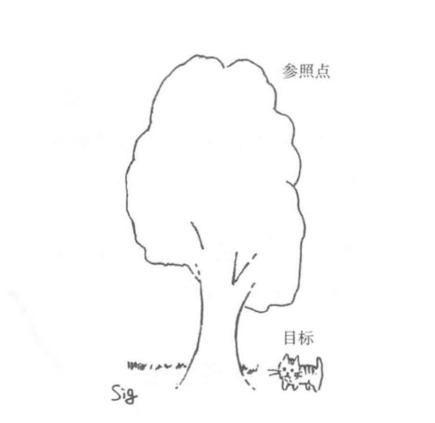

西村：没错。认知语言学认为，转喻的存在是以人类所具有的一般认知能力为基础的。而兰盖克所说的参照点能力，就是其中的一种认知能力。

兰盖克认为，人类具有参照点能力，而转喻就是参照点能力的一个体现。比如，远处有一只猫，你希望你旁边的人能注意到这只猫,但因为对方一下子很难捕捉到猫的位置，所以你就会指着猫旁边的树说：“那儿不是有一棵树吗？那下边有一只猫，看到了吗？ ”此时,作为线索最先关注到的是参照点，而经由参照点最终指向的则是靶子（target）。刚才的例子里，大树是参照点,猫是靶子。

野矢：说“猫是靶子”好像有点儿火药味（笑）。我们还是说“目标”吧。

西村：好吧。通过“参照点”寻找“目标”，其实这件事我们经常在做。而兰盖克认为，“小红帽”这样的转喻现象之所以会产生，正是基于此。具体来说，就是借由小红帽指称戴着小红帽的小女孩，此时小红帽是参照点，小女孩是目标。而“我最近又开始读村上春树了”这句话中，村上春树这个人是参照点，他的作品是目标。基本的分析就是这样。

### 领属结构的分析

野矢：参照点理论，一听就是认知语言学式的分析方法。那它比单纯说“邻近性”的优越之处在于……？

西村：首先，在参照点理论中，“邻近性”可以被更加准确地界定为“参照点和可以经由参照点被激活的对象之间的关系”。其次，参照点理论不仅可以用于分析转喻，在分析其他语言现象的时候也很有效。

野矢：其他语言现象，比如说？

西村：比如，分析领属结构的时候就很有效。

野矢：哦，这个问题您在第一讲简单介绍过。以日语为例的话，比如「太郎の車（太郎的车）」「花子の母親（花子的妈妈）」「タマのしっぽ（小猫的尾巴）」「漱石の小説（漱石的小说）」这些都用到了领属结构。……嗯，不过可能还是用英语的例子去说明更清楚一点，因为英语会像"Taro's car"、"Hanako's mother”这样使用所有格。英语的所有格，固然也有像“太郎的车”这样只表示领属关系的时候，但也有不表示领属关系的时候，就像我之前举的其他例子那样，有表示亲属关系的，也有表示整体局部的，还有表示作者与作品的，等等。为什么这些关系都可以用所有格来表达呢？这就是问题所在，对吧？

西村：对于认识太郎的人来说，太郎本人比他拥有的车更容易被识别。因此把太郎作为参照点，应该是很自然的。同理，说"Hanako's mother”的时候,也应该是说话人对花子比对花子的妈妈更熟悉才可以。即，以自己熟悉的花子为参照点，间接地指向与其有特定亲属关系的人。关于猫和猫的尾巴，也可以做相同的解释。我们对于一只特定的猫可能知道得很多，但对于这只猫的尾巴，则往往知之甚少。

野矢：分析得漂亮！所有格不是用来表达“领属”的，而是用来指明参照点的。先不论这样的分析到底能否全面充分地解释所有的领属结构，但至少，我觉得它提供了一个把握领属结构时的敏锐视角。

西村：我也是这么想的。在此之前的研究，都只是说“领属结构表示亲属关系和整体部分关系的用法，是从原有的表达领属关系的用法通过隐喻扩展而来的”，但却没有指出这种扩展到底是基于什么样的隐喻。所以，我读完他们的分析并没有一种豁然开朗的感觉。而恰在此时，兰盖克另辟蹊径地把这样一种全新的分析呈现在了我们面前。

### 转喻的单向性和参照点理论

野矢：我们还是回到转喻上来吧。我觉得参照点理论还有一个优点，就是可以解释转喻的“单向性”。可以这么说吧？比如，转喻可以像「鍋が煮えてる（锅里的东西煮熟了）」一样，用锅指代锅里的东西，却不能用锅里的东西来指代锅。还有，可以像“正在读村上春树” 一样，用村上春树指代村上春树的小说，却不能用村上春树的小说来指代村上春树这个人。这些例子都体现了转喻的单向性。但这种单向性，用传统的“邻近性”是解释不了的。因为如果A邻近B的话，那么反过来也可以说B邻近A,由此无法推导出单向性这个结论。与之相对，参照点理论说的是借由显眼的东西指向不显眼的东西，这样就很好地解释了转喻的单向性。

西村：是啊。不过关于参照点理论的这个优点，我其实并没有好好思考过。

野矢：啊？这样啊。是不是因为，对您来说在理解转喻时单向性这个特征不是很重要？

西村：可以这么说。

野矢：那我可要听一听您的想法了。刚才讨论过的「歯がしみる（牙齿渗痛）」，您还是觉得它是转喻，对吧？

西村：对。

野矢：如果「歯がしみる（牙齿渗痛）」是转喻的话，它不就没法用参照点理论来解释了吗？因为，说「歯がしみる（牙齿渗痛）」的时候，说不清楚什么是参照点，什么是目标，找不到说「鍋が煮えてる（锅里的东西煮熟了）」时的那种单向性。还有，“按警报器”和“警报器响了”的关系也是一样的。您之前说它们是“互为转喻关系”的，它们的关系确实不是单向的，而是一种双向的关系。

西村：所以我认为，单向性并不是转喻的本质。像「歯がしみる（牙齿渗痛）」和「歯にしみる（渗牙）」这样，二者互为转喻关系的现象才更为重要。

野矢：这样啊。看来，西村先生您喜欢的原来都是对您的想法有利的例子。也就是那些非单向性的、不能用参照点理论去解释的例子。您可被我识破了。

西村：算是被识破了吧。

野矢：当然啦（笑）。那好，您就给我讲讲您的观点吧。

### 框架和焦点

西村：我认为，要想全面地分析转喻现象，比起参照点能力，反而是另一种认知能力更重要。这种能力我暂且叫它“激活并操作百科知识的能力”。

野矢：第三讲我们讲过百科知识语义观，您现在说的就是这个百科知识吧？

西村：是的。一般来说，制约语义的，不仅仅是辞典性的、语言内的因素，还有语言外的因素。比如，要想理解“鸟”这个词的语义，就要知道有关鸟和鸟的生态等的一系列知识。

野矢：就是有关鸟的常识，或者说是凡是会使用这个词的人都了解的事实，对吧。比如会下蛋、有喙、一般来说会飞，等等。

西村：是的，我们把这些称作“百科知识”。认知语言学认为，百科知识对于语义的理解来说非常必要。同时，百科知识也是转喻这种语言现象得以产生的基础。也就是说，我们在使用或者理解转喻的时候，需要用到激活并操作百科知识的能力。这就是我的观点。

野矢：语义的理解需要百科知识的帮助，这应该是语言的普遍特征，并不只限于转喻吧。

西村：是的。使用转喻时，是将百科知识中某个特定的部分锁定为焦点，因此我们可以把转喻理解为焦点的移动。而相对于“焦点”的百科知识的集合，我们称之为“框架”。这是美国语言学家菲尔墨(Charles Fillmore)提出的术语。基于此，我曾经提出可以把转喻定义为“一个语言形式所拥有的几个用法，在共同唤起了同一个框架的同时，聚焦该框架的不同部分或阶段的语言现象。”

野矢：对不起，我听一遍还理解不了。您提出了什么来着？（笑）

西村：想想“电话响了”和“拿起电话”这个例子吧。这里说的是电话机和听筒可以分家的那种老式的固定电话。“电话响了”和“拿起电话”唤起了这样一些知识，有一个人转动了号码盘……

野矢：还“转”呢！这都什么时代了（笑）。

西村：那就是按下了电话号码，然后想要和某个人通话。这些被唤起的知识，就是有关“电话”的框架。无论是“电话响了”还是“拿起电话”都共同唤起了这个框架。

野矢：明白了。到这儿为止是您刚才讲的定义的前半部分——“一个语言形式所拥有的几个用法，共同唤起了同一个框架”。

西村：是的。框架是共通的，但聚焦的是哪个部分却有所不同。“电话响了”聚焦的是响铃的部分，还有电话机本体的部分，而“拿起电话”聚焦的则是听筒的部分。我想就像这样，通过聚焦共同框架的不同部分、不同侧面，才形成了互为转喻关系的多种用法。

野矢：我们再举一个别的例子来验证一下吧。「冷たい水が歯にしみる（凉水渗牙）」和「歯がしみる（牙齿渗痛）」，应该怎么分析呢？

西村：这两个「しみる（渗）」的用法，共同唤起了 “水或烟雾等的刺激作用于身体，导致身体产生疼痛的感觉”这个框架，但聚焦的部分不同。「冷たい水が歯にしみる（凉水渗牙）」聚焦的是前半部分，也就是对凉水的刺激这个原因聚焦；而「歯がしみる（牙齿渗痛）」聚焦的是后半部分，也就是对疼痛这个结果聚焦。

野矢：那我也来一个。就举“冲厕所”的例子吧。厕所的故事，这个我可不想说得太详细（笑）。首先，我们对典型的厕所应该都有共识。如果是家庭用的厕所的话，应该是一间独立的房间，里面有坐便器之类的。还有，厕所是方便的地方，方便后要冲水。之所以要冲水，是为了保持厕所的清洁。这些就是厕所"一具体来说，是可冲水的厕所——唤起的框架。那现在，我不说“冲水”，却故意说“冲厕所”，是因为在上述框架中，我关注的是厕所的状态，所以要对整个厕所聚焦。大概就是这样吧。

西村：给您打满分。

野矢：真的？ ！

### 谁能说出“巴门尼德”指的是什么

野矢：我一开始还有点疑问，觉得是不是可以把转喻看成一种单纯的省略。可听了您的这番分析后，我觉得我那个想法很肤浅，忽视了转喻具有的重要功能。

西村：您能这么想我很欣慰。

野矢：接下来，我想站在您的立场，从您的观点出发，去向兰盖克的参照点理论提出异议。比如，“正在读村上春树”这个句子，如果用参照点理论分析，就是先指称村上春树这个人，然后再借此去指称村上春树的作品。是这样吧。可这样一来就等于发生了两次指称，我总觉得这样有些不太自然。可能因为对象是村上春树所以觉得还能接受吧，可如果是“我正在读巴门尼德”的话，这个巴门尼德<sup>40</sup>到底指什么可就说不清了。

西村：嗯嗯。

野矢：巴门尼德这个人，要论名气的话可不是很大。

西村：有道理。

野矢：一般说起巴门尼德，我们想到的都是他写的东西。所以，分析“我正在读巴门尼德”这个句子的时候，我觉得参照点理论不管用。

西村：真有意思。

野矢：还有一个是刚才您举过的例子。说「長野は楽しかったな（长野真开心啊）」的时候，我们真的在指长野县吗？长野县有那么有名吗？我连长野县在地图上的形状都不知道。那“长野”这个词指称的到底是什么呢？或者，说「信州は楽しかったな（信州<sup>41</sup>真开心啊）」的时候呢？地名的指称问题真的很难。

西村：确实很难。

野矢：我个人认为，地名指称的对象应是较为抽象的。如果用您刚才教给我的方法分析的话，就是地名会唤起一个与它有关的框架。比如，“信州”这个地名会唤起一个与信州有关的框架——即有关信州的百科知识。我觉得，这才是地名更为主要的功能，指定地图上的一块小小的空间区域并不是地名的主要功能。

西村：我觉得这么想没什么问题。

野矢：进一步说，我觉得不只是参照点理论，认知语言学在整体上还是太依赖指称这个概念，您觉得呢？“指称”这个概念，在以弗雷格(Gottlob Frege )为开端的传统语言哲学中也是一个具有核心地位的关键词。它在语言学中固然也很重要，但我觉得认知语言学不妨和这个概念稍微保持一点距离。最典型的指称，就是“村上春树”这种专有名词。但“村上春树”这个名字，与其说是在指称某个具体的对象，不如说是起到了唤起有关村上春树的常识(框架)的作用。这样去理解专有名词是不是更好呢？说“去见村上春树”的时候，我们激活的是框架中的人物这个侧面；说“读村上春树”的时候，我们激活的是作品这个侧面；而说“研究村上春树”的时候，则是一方面聚焦作品，一方面也一定程度地激活了人物这个侧面。即使不是名人，我们也可以这样分析。比如关于我，野矢茂树，大学生会说“还是不选野矢了”、“野矢把我给挂了，什么的。他们说“野矢挺没意思的”的时候，是不是一方面聚焦了野矢的课堂，一方面也一定程度地激活了野矢这个人物的侧面呢？

西村：哈哈哈。

野矢：而且这么一想的话，就会发现专有名词也是有原型的。比如，“这个作品不像村上春树”。还有，您平时两三公里的路肯定会步行，可如果有一天您突然打车从御茶水到本乡<sup>42</sup>，我们也可以说“这一点都不像西村老师”。要是只认为专有名词是用来指称特定对象的，就不能解释为什么对专有名词也可以说“像与不像”。可如果认为专有名词激活的是一个框架的话，那被激活的故事当中自然会有原型性的故事，也就是很能代表那个人物的典型故事。我觉得可以顺着这个思路思考下去。

西村：的确可以这么想。不过在这一点上，我想帮兰盖克说句话。他把“指称”叫作“profile”，而不是"reference"。为什么叫"profile"呢？举一个简单的例子。比如“斜边”这个词，脱离了〈直角三角形＞是无法理解它的意思的，对吧。按兰盖克的说法就是，〈直角三角形＞是“斜边”的基底。他先设定了 “基底（base）”这样一个概念，然后又把以〈直角三角形〉为基底的〈斜边〉称作“侧面（profile）”。之所以不用“reference” 一词，是因为他认为指称的本质，不是单纯去指定一个特定的对象，而是去凸显基底中的某个特定的部分。比如，要想理解“父亲”、“母亲”这样的亲属称谓，就要先建立整个亲属关系——也就是家庭关系图——这样一个基底，而“父亲”、“母亲”就是其中被凸显的部分。

野矢：那“村上春树”这种专有名词怎么办？

西村：基底是关于村上春树的一般常识，侧面则要看使用“村上春树”这个专有名词时的语境和上下文。如果是“和村上春树见面”的话，侧面就是村上春树这个人物。

野矢：就好比，以整个舞台为基底，然后把聚光灯打在其中一部分上，对吧？

西村：对。因此兰盖克对指称的理解和百科知识语义观并不冲突。

野矢：如果他是这么想的话，那我也赞成。

### tough结构

西村：接下来，我想介绍一些以转喻为基础的语法现象。这是我个人特别感兴趣的课题，特别是从语义和语法的关系这个角度来看的话。具体来说，比如“tough结构”就是一个很好的例子。因为这种结构在日语里很难成立，所以只能用英语的例句了。我写两个句子，咱们比较一下。

It is difficult to read this book.

This book is difficult to read.

后者，即“This book is difficult to read”这个句子，一般被称作“tough结构”。

野矢：日语呢，如果只就上面的例子而言的话，可以说「この本を読むのはたいへんだ（读这本书很难）」和「この本は読むのがたいへんだ（这本书很难读）」，对吧。能不能用日语考虑这个问题呢？

西村：也可以，但总体上说，日语里“tough结构”不太容易成立。

野矢：因为既没有“to”不定式，也没有“that”从句？

西村：到底是为什么，我也说不好。不是在所有的语言里"tough结构”都能成立的。当然，如果去掉“to read",只说“这本书很难”，句子肯定是成立的。

野矢：那还是用英语的例子吧。我忍一忍（笑）。

### 早期的分析

西村：从二十世纪六十年代起，如何分析这两个句子的关系就成了语言学的一个重要课题。

野矢：也就是说，这种语言现象早在认知语言学问世前就已经受到关注了。哦，那这么说来，认知语言学就是要从转喻的角度去破解长期以来的难题喽？

西村：是的。"It is difficult to read this book."和"This book is difficult to read."这两个句子，如果一方为真，则另一方也为真，这意味着二者在真值条件上相同。因此，早期的生成语法，认为二者拥有一个共通的抽象结构——早前叫“深层结构”——,而这两个句子就是通过对深层结构施加语法操作而得到的。

这里所说的操作，以当前这两个句子为例的话，指的是以下这几步。

①设想二者具有一个共通的抽象结构（深层结构）,大概相当于“To read this book is difficult”。

②接下来，把"to read this book”移到句末。

③这样一来，如“□ is difficult to read this book”所示，主语的位置为空。

英语是不能主语为空的语言，所以要在“□”的部分加入某种成分，这时有两个办法。

④第一个办法，是加入“it”这样一个形式主语,于是就有了 "It is difficult to read this book."。

⑤第二个办法，是把不定式中的宾语“this book”放入主语位置，于是就有了 "This book is difficult to read."。

当时的生成语法，认为句子的语义是由深层结构决定的。因此上述分析已经自动保证了这两个句子在语义上是等同的。

野矢：这种分析本身有漏洞吗？出现了什么问题吗？

西村：上述分析在生成语法的框架内已经被指出有很多问题，但即使脱离了生成语法这个特定的语言理论，上述分析也存在问题。最大的问题应该就是，无法解释为什么"tough结构”的谓语，只局限于"tough"、“difficult”、“hard”、“easy”这样的形容词或者“fim”这样的名词。生成语法只能说这是偶然的结果，但真的是这样吗？具体一点说，“tough结构”的谓语之所以多为表示难易或愉快不愉快的形容词，是不是其实和这个句式的语法特性有关？带着这样的疑问，认知语言学（特别是其中的认知语法理论）登场，并试图从正面去阐释这两个句子之间的关系。

### 认知语言学提出的新方案

野矢：明白了。那，认知语言学是怎样分析的呢？

西村：首先，说说兰盖克的分析。我想您应该也能想到，他的分析是，“This book is difficult to read”中，参照点是〈这本书〉，目标是〈读这本书这件事》。

野矢：在“小红帽”这个例子里，我们以小女孩身上最突出的部分（即小红帽）为参照点，借由参照点来指向小女孩。同样，读书这个行为中最突出的是作为具体事物的书，因此我们就可以以书为参照点来指向读书这个行为，也就是目标。与之相对，"It is difficult to read this book"这句话中，则没有设定参照点。他是这么想的吧？

西村：没错。

野矢：可是，这个分析我不太敢苟同。如果“This book is difficult to read"的主语"this book"其实转指的是<to read this book〉的话，把它直接还原到句子里去就成了“*To read this book is difficult to read”。谓语部分明显多了一个“to read"。所以啊，我觉得“This book is difficult to read"的主语"this book",指的应该还是字面的意思，就是一本书。这么想是不是更自然些？

西村：对您刚才提出的疑问，兰盖克也准备了答案。他的分析是这样的：谓语的“to read”在语义上确实是冗余的，但正因为有了 “to read"，我们才能明确“this book"的目标是<to read this book>o如果多出来的部分是“to buy”的话，那么“this book”的目标就是<to buy this book>0也就是说，这个"to read"起到的是指定目标的作用。

但就我个人而言，就像野矢老师您刚才说的那样，我也认为这个“this book”指的就是一本书。另外，我认为这两个句子中的“difficult”是互为转喻关系的。也就是说，这两个“difficult”虽然噢起的是同一个框架，但聚焦的是这个框架的不同侧面。二者的这种不同，也反映在了它们所出现的句式结构的不同上。

野矢：对不起，我还没弄明白。为什么您说，“It is difficult to read this book"和"This book is difficult to read”的两个“difficult”互为转喻关系？……在这里，它们唤起的共通的框架又是什么呢？

西村：这里的框架，指的是〈实施不同的动作行为时，存在难度上的差异，而这种难度取决于与该动作行为有关的事物（受事、共事者、处所等）的特征＞。

野矢：什么是“受事”呢？

西村：就是像“读书”的“书” 一样，是实施行为动作时的对象。

野矢：那么，以“骑自行车很简单”为例，这句话的受事是自行车，难易度是简单。还有，“在东京站等人很难”这句话，行为的处所是东京站，难易度是难。大概是这么分析吗？

西村：没错，就是这样。这样一来，“It is difficultto read this book"的"difficult”聚焦的是动作行为的难易度，而“This book is difficult to read"的"difficult”则聚焦的是作为受事的“这本书”的特征。觉得一本书特别难读的原因，有可能是专业术语太多，有可能是题材不太熟悉，也有可能是书的文笔不太好。总之，很多情况下是书的特性决定了读这本书时的难度。我们也可以以共事者为例，因为根据共事者的不同，我们跟这个人一起进行某种动作行为时的难度也会有所不同。总而言之，我的观点就是，当你聚焦的是受事、共事者、处所等侧面的时候，"tough结构”就可以成立。

野矢：原来如此。看来，“tough结构”也能从框架和焦点的角度，也就是您说的转喻的角度进行分析。嗯，确实是您的分析让我觉得更自然。

### “管子堵住了”

西村：“tough结构”以外的语言现象，比如之前我们举过的「パイプが詰まる（管子堵住了）」，其实也可以用同样的方法去分析。请对比下面的这两个句子。

パイプにゴミが詰まる。（垃圾堵住了管子）

パイプが詰まっている。（管子堵住了）

这两个「詰まる（堵住）」唤起的是同一个框架，即管子本来是为了让物体从中通过而存在的，但因为物体在其中停止了移动，导致管子丧失了使物体从中通过的功能。

接下来，我认为可以这样分析，「パイプにゴミが詰まる（垃圾堵住了管子）」这个句子，聚焦的是上述框架中物体在其中停止移动这个部分；而与之相对,「パイプが詰まる（管子堵住了）」这个句子，聚焦的则是管子的状态，即上述框架中管子无法正常发挥功能这个部分。

野矢：那您的意思是，这也是基于转喻的语法现象，是吧？

西村：是的。对框架聚焦的部分不同，所使用的句型也会不同。最典型的就是改变主语，即什么是焦点，什么就做主语。

野矢：哦，还真是。有道理。可是，说「パイプにゴミが詰まる（垃圾堵住了管子）」的时候，我觉得我也挺关注管子的啊。

西村：我们也可以只说「ゴミが詰まる（垃圾堵住了）」，这时焦点很明显只在垃圾上。而加上“管子”以后，我觉得是指明了垃圾在哪里停止了移动，也就是指明了处所。

野矢：那，「このパイプはゴミが詰まっている（这个管子垃圾堵住了）」呢？能说吗？

西村：能说。

野矢：我也这么觉得。那这个句子里管子也是焦点，对吧？

西村：这个问题啊，非常有意思。嗯，怎么说呢。这里的「パイプは」的「は」，有很多种功能，不过最常见的应该是主题（topic）。所谓主题，大概就相当于“说起管子啊”、“关于管子现在的情况啊"什么的。

野矢：日语里应该叫「話題」，对吧？

西村：是的。「は」的作用，就是标识话题的中心在哪里、最关注的地方在哪里。所以，「このパイプはゴミが詰まっている（这个管子垃圾堵住了）」，说的就是有关这个管子，发生了垃圾堵塞这样一件事。

野矢：那「このパイプはゴミが詰まっている（这个管子垃圾堵住了）」是有两个焦点吗？还是说，在整个框架中，先把话题或关注点限定在管子的状态上，然后在描述管子的状态的同时，又把焦点移到了垃圾上？不过，这两种解释实质上都差不多。

西村：应该是以管子为主题的同时，又在谓语「詰まる（堵住）」唤起的框架中聚焦垃圾停止移动这个部分。也就是说，这个句子表示的是“关于管子，发生了垃圾在其中停止移动这么一件事”。

### 句式语义和转喻性的一词多义

野矢：我能不能这样概括一下？认知语言学认为,语法项本身就包含语义。也就是说，只要做了主语，就自然拥有了主语所包含的语义——即图式性语义。在上述例子中，主语的这种图式性语义就是焦点化。主语这个语法项，具有告诉大家一句话的焦点在哪儿，最关注的地方在哪儿的功能。「パイプが詰まる（管子堵住了）」、“tough结构”这些句式，都是把在唤起的框架中聚焦的部分放在了句子主语的位置。对吗？

西村：您说得没错。

野矢：那么，还回到tough结构上。"It is difficult to read this book"和"This book is difficult to read"的关系，是不是很像主动句和被动句呢？

西村：在“大卫杀死了歌利亚”这个句子里大卫是主角，与此相对，在“歌利亚被大卫杀死了”这个句子里的焦点则是歌利亚。所以，从焦点的移动带来句式的变化这一点来看，它们确实是共通的。

野矢：这样一来的话，主动-被动之间的关系也是转喻性的了？可，这有点儿不太对劲吧？

西村：嗯，这个嘛……其实，就我个人而言，我觉得它们也是互为转喻关系的。

野矢：可是，您想啊，“大卫杀死了歌利亚”和“歌利亚被大卫杀死了”之间并没有发生转喻性的语义变化啊。「パイプが詰まる（管子堵住了）」和「ゴミが詰まる（垃圾堵住了）」中，「詰まっている（堵住了）」的语义发生了变化。（前者是“滞塞不通”，后者是“大量沉积”的意思。）"It is difficult to read this book"和"This book is difficult to read"中,"difficult”的语义也发生了变化。（前者说的是读书这个行为很难，后者说的是这本书本身的特征是难读）。可是，“大卫杀死了歌利亚”和“歌利亚被大卫杀死了”之间，“杀死”的意思并没有发生变化吧。所以把这个也称为转喻是不是有点儿... 。

西村：嗯，是的。问题就在于，句式之间所呈现出的有规则的对应关系，比如主动句和被动句，与转喻性的一词多义之间，在什么情况下存在联系、存在怎样程度的密切联系。我其实从很早以前就注意到，这里面很微妙。

比如，假设有这样一个语言，主动和被动只靠语序来区分（具体有没有这样的语言我不知道）。我们虚构几个例子，比如表示“大卫杀死了歌利亚”的时候，这个语言说“大卫•杀•歌利亚”；而表示“歌利亚被大卫杀死了”的时候，就把“歌利亚”放到句首，说“歌利亚•大卫•杀”。就这个语言而言，可以说“杀”这个词发生了转喻性的一词多义（前者表示杀死，后者表示被杀死）。那么像这样只用语序来区别主动-被动的语言，和英语日语这样还并用其他手段的语言，真的有那么大的差异吗？

野矢：有道理。如果从您的角度来看的话，当然没有那么大的差异。尤其是对于不愿把语法和语义截然分开的语言理论来说，既然语义的变化和句式的变化都可以用“同一个框架中的焦点移动”这个原理来解释，那也就没有必要特别把二者区分开了。

西村：没错。

野矢：果然是认知语言学特有的浑然一体的语言观啊。

### 受害被动

西村：从上述观点来看的话，之前我们提到过的受害（间接）被动的例子就非常有研究价值了。

野矢：您是说「太郎は花子に泣かれた（太郎被花子哭了）」<sup>43</sup>这样的例子，是吧？

西村：是的。这个例子，就是句式的变化和语义的变化都同时发生了。也就是说，首先在使用被动句的时候发生了句式的变化；同时原本是不及物动词的「泣く（哭）」，因为出现在被动句中而获取了一种及物义。

野矢：这个句子里，什么是框架，什么是焦点呢？

西村：唤起的框架应该是和发生“哭”有关的各种场景，而在这些场景中，应该有一种场景是因为某个人在哭，其他人感到很烦、定不下心来。受害被动聚焦的就是这个侧面，特别是因为哭而感到烦心的那个人。

野矢：再来看「雨に降られた（被雨下了）」。首先，框架是有关下雨的各种场景，而其中也包含了因为没有带伞而被淋得湿漉漉的、束手无策的场景6这时，如果我们聚焦在束手无策这个侧面上，就有了「雨に降られた（被雨下了）」。对吗？

西村：就是这样。

野矢：受害被动在日语里很常见，可英语里好像很少见，是吧？

西村：「花子に泣かれた（被花子哭了）」，在英语里恐怕很难……。

野矢：那也就是说，「泣く（哭）」和“cry”各自唤起的框架不一样，是吗？

西村：应该是这样的。

野矢：说英语的人，肯定看着别人哭也不会觉得烦或者定不下心来吧。

西村：哈哈。说英语的人肯定也会有这种心情的时候，只是一般不会将其特意表现在语言中。我想这么说可能更客观一点。

说到这里，我想起了英语的动结结构。我觉得英语的动结结构和日语的受害被动在一些重要的地方有共通之处。比如，"She cried her eyes out."这个句子,字面的意思是“她因为一直哭，结果眼珠子都跟着流出来了”，这个句子就属于动结结构。“眼珠子流出来了”是一种夸张，实际上就是对“她没完没了地哭”的一种惯用表达，可以说是一种惯用语。在这个例子里，一般做不及物动词的“cry”，变成了表示对眼睛施加作用力的及物动词。这种动结结构，和受害被动一样，大多是在动词所表示的动作行为造成了负面结果的时候才使用。我觉得这是非常有研究价值的语言现象。

1. 此句字面意思为“锅煮熟了”。
2. 长野县是47个都道府县中的一个县，位于本州岛中部。
3. 此句字面意思为“灯泡断了”。
4. 此句字面意思为“转洗衣机”。
5. 日语的「こぐ」，不仅可用于「自転車をこぐ（蹬自行车）」，也可用于「ボートをこぐ（划船）」「ぶらんこをこぐ（荡秋千）」等，因此其语义更广泛，不仅限于汉语的“蹬”。
6. 此句字面意思为“录像断了”。
7. 此句字面意思是“房间散放”。
8. 日语的「流れる」有“流”和“漂”这两个义项，且这两个义项都很常用。固然这两个义项在历时上是有先后的，但现代日语的母语者已经很难意识到哪个才是它的本义。也正因为如此，野矢老师才会把“漂”误认为是「流れる」的本义。
9. 巴门尼德，公元前5世纪古希腊哲学家，主要著作有《论自然》。
10. 信州.是对长野县的旧称。
11. 东京大学位于日本文京区本乡，从御茶水车站步行到本乡的距离大约是1.5公里。
12. 前文中出现的例子是「彼女に泣かれた（被女朋友哭了）」，与此例略有不同，但二者都是受害被动的例子。

## 第六讲从隐喻到新的语言观

### 隐喻的事例

野矢：虽然按理来说应该先解决“什么是隐喻”这个问题，可这个问题本身就很难回答，所以咱们还是先举几个隐喻的具体例子吧。可虽说是举例，这当中其实也同样有很多问题。现在就先顾不了这么多了。语言学上一般认为，什么样的例子是典型的隐喻呢？

西村：比较容易想到的例子，比如“朱丽叶是太阳”什么的。

野矢：怎么还是这种老掉牙的例子……

西村：嗯，也不知道为什么，反正举例的时候还是挺常见的。

野矢：还有“男人是狼”什么的？应该已经没有人这么说了吧。相比之下，我觉得还是「目が釘付けになる（目不转睛）」<sup>44</sup>、「頭の回転が速い（脑子转得很快）」这样的例子更好些吧。还有比如《雪国》开头的那句「夜の底が白くなった（夜色深处一片白茫茫）」<sup>45</sup>。还有一个例子，准备一会儿跟您探讨的，我们说“成绩上升”的时候，应该一般都意识不到它是隐喻吧。语言学家怎么看这个例子呢？

西村：这个例子，是把成绩变好比作了空间上的上升。这个例子，在认同雷可夫&约翰逊（George Lakoff& Mark Johnson ）的隐喻理论的学者们看来，是隐喻；但对于其他语言理论来说，就不是隐喻了。

野矢：我也不太想把“成绩上升”看成隐喻。不过，这里其实隐藏着一个很重要的问题，我们一会儿再讨论吧。我们再重新回到“朱丽叶是太阳”和“男人是狼”吧。一听到这样的例子，我就会马上有一种感觉，好像隐喻只是明喻的一种省略。

“朱丽叶像太阳”和“男人像狼”这样的比喻句，因为把相似性这一点很直接明确地标识出来了，所以被叫作明喻。而“朱丽叶是太阳”和“男人是狼”这样的例子,有人说它们只是省略了明喻句里的“像:可是，比如像「夜の底が白くなった（夜色深处一片白茫茫）」这样的比喻句，是根本不可能改写成明喻句的。所以，隐喻有不能改写成明喻的例子，也有明喻代替不了的功能。

西村：是的。

野矢：我们这次的主题是隐喻，所以我只在这里说两句，之后就不再讲明喻了。我想说，其实明喻更吸引人。

西村：是的是的。佐藤信夫先生就说过这样的话（《修辞感觉》，原书名『レトリック感覚』，1978年）。因为明喻会有“好像”、“似的”这样的标记<sup>46</sup>，形式上一目了然，所以极其新颖大胆的比喻往往也能成立。

野矢：村上春树的明喻不就很大胆吗？

西村：他确实很大胆。比如，被问到可爱到什么程度的时候，他会说“可爱到山崩地裂海枯石烂的地步”;被问到喜欢到什么程度的时候，他会说“像春天的熊一样喜欢”。

野矢：哈哈。这些明喻，简直像让被塞进鹿鼠洞的黄鼠狼抓蚯蚓一样荒唐（笑）。

### “我们赖以生存的隐喻”

野矢：言归正传。刚才我们提到了雷可夫和约翰逊这两个人的名字，其实我最先接触到认知语言学，也是缘于这两个人的隐喻理论。估计很多外行都是以这种方式开始了解认知语言学的。我先看的是We Live By （ 1980 ）的日译本《修辞与人生》（日译本原书名为『レトリックと人生』。该书有中译本，《我们赖以生存的隐喻》，何文忠译，浙江大学出版社）。

西村：您说那本书啊，日译本的书名总给人一种好像在讨论人生的感觉。

野矢：直译过来应该是“我们赖以生存的隐喻”吧。雷可夫和约翰逊做了很多这方面的研究，而您呢,则一直在以兰盖克的视角研究认知语言学。所以我想您应该并没有直接继承雷可夫和约翰逊的学说，对吧？

西村：我的确没有继承。因为我觉得自己无法在他们的隐喻理论基础上增加我自身的新观点。另外，也因为我不愿追随雷可夫后期的隐喻理论的发展方向。所以，隐喻理论对我来说，就不太……

野矢：虽然如此，不过在您刚开始做研究的时候，差不多是您做学生的时候吧，这本书应该还是一本很重要的、至少是很有影响力的书吧？

西村：那是毫无疑问的。

野矢：那就麻烦您给我讲讲吧。

西村：好的。在第一讲我讲到过，生成语义学是脱离乔姆斯基的生成语法后形成的，乔治•雷可夫是生成语义学的先驱者。但生成语义学最终败给了乔姆斯基那一派的生成语法，退出了历史舞台。后来，乔治•雷可夫在1980年和哲学家马克•约翰逊一起写了一本书。当时我虽然知道这件事，但心想“反正是雷可夫写的书，肯定没什么意思”，所以就没去读它。

野矢：真的？您当时是这么想的啊。

西村：当时在我心里他已经是过气的人了。当时在日本有这种想法的语言学者应该不在少数，大家都觉得他虽然曾经所向披靡，但已经江郎才尽了。所以我就没有读这本书。我周围应该也没有人读这本书。就连池上嘉彦老师都没读呢。但后来我在翻看一本翻译家写的翻译理论著作的时候，发现里面介绍了雷可夫和约翰逊的这本书和其中的很多有趣片段，一下子被吸引了，心想一定要读一读。结果一读，发现这本书果然很有意思，感觉雷可夫和生成语义学时期相比简直判若两人。但后来我重读的时候（我反复读了很多次），发现书里面有很多内容其实是重复的。

野矢：我看了一半就腻了（笑）。

西村：不管怎么说，重要的是，书中对语义的看法，与生成语义学以及整个生成语法相比，都发生了很大的变化。比如，在生成语法看来，隐喻没有什么重要的，不过是一种很边缘化的语言现象。生成语法认为，应该先研究日常的语言，也就是语言的字面义，至于隐喻和转喻这样的语言现象，之后再去解决就好了。然而，雷可夫和约翰逊却主张，“不，其实隐喻是一种关乎语言本质的、无处不在的语言现象。进一步说，隐喻不只是语言的问题，它还存在于语言使用者的概念体系中。可以说，人类概念体系的很大一部分都是基于隐喻（或者说隐喻性的概念）建立起来的”。他们认为，隐喻（或者说隐喻性的表达方式）直接反映了语言使用者看待或识解世界的方式。在这个意义上，他们的观点可以说是具有开创性的。

野矢：在此之前，语言学认为隐喻只是一种修辞，而修辞在他们看来是很廉价的。当然我们也可以把修辞讲得很高端，但就一般人的印象来说，修辞不过是对语言的一种装饰。可以用隐喻去表达的，一般也都可以用更直白的方式去表达，我们用隐喻的方式只是为了给别人留下更深刻的印象，或者把话说得更风趣幽默。正因为这样，隐喻在语言学里才不受重视的吧。

西村：正是如此。

野矢：在语言哲学里，隐喻也同样受到了冷遇。您想啊，就连分析“波奇是一只狗”这样的最基本的主谓句，语言哲学家们都不知道要费多少口舌。所以对他们来说，隐喻可就太遥远了。在语言哲学这边最先开始讨论“隐喻理论”的，是马克斯•布莱克(Max Black)写的那篇叫"Metaphor” ( 1954 )的论文。可是直到现在，隐喻在语言哲学中还是处于边缘地位。比如有个叫莱肯(W.G.Lycan)的人，出了一本从初级到中级讲授语言哲学的课本(4, 2000 )o 书的最后一部分是专门介绍隐喻的，可它的标题竟然是“The dark side"，意思是语言哲学的黑暗面。而雷可夫和约翰逊正是在这样的背景下把隐喻提到了研究的最核心位置上来。

### 概念隐喻

西村：我想这和他们提出了 “概念隐喻”这个观点关系很大一一他们认为隐喻是概念层面的问题。在雷可夫和约翰逊看来，隐喻不仅仅是语言层面的问题，之所以我们能在语言层面上看到隐喻，是因为我们的概念体系是建立在隐喻基础上的。

野矢：可这也是容易让人产生误解的地方。因为一般说到隐喻，我们想到的都是具体的语言表达。比如「目が釘付けになる（目不转睛）」「夜の底が白くなった（夜色深处一片白茫茫）」什么的，还有“朱丽叶是太阳”。可雷可夫和约翰逊最想讨论的，并不是语言表达层面上的隐喻，而是概念层面上的隐喻。对了，我有一个问题，可能太基本了您反而不好回答。如果我问您“概念”是什么，您会怎么回答？

西村：嗯，这确实是个问题。如果有人问“认知语言学是怎么看待语义的”，我们只能回答“认知语言学认为语义是概念的一种"。但这样一来，肯定会被接着追问“那什么是概念呢”。约翰•泰勒(John R. Taylor)给出了一种回答：“概念，简而言之，就是范畴化的原理”，我觉得这个回答其实就可以。

野矢：“范畴化的原理”，这么说恐怕还是很难懂。是不是可以理解成我们识解事物的方式呢？比如，对西村老师这个人进行范畴化可以有很多方式：作为人的西村老师、作为动物的西村老师、作为语言学家的西村老师，等等。诸如“作为人”、“作为动物”、“作为语言学家”这样的识解事物的方式就是范畴化，也就是概念。是这个意思吗？

西村：可以这么说。在雷可夫和约翰逊看来，隐喻就是在这样一种概念层面上发挥作用的。比如，雷可夫和约翰逊的书里有一个有名的例子：ARGUMENT IS WAR,意思是“辩论是战争"。我们确实经常把辩论比作战争，比如，辩论会有输赢、会有攻防、会有敌我、也会有优势劣势。我们就是这样借助战争的隐喻来理解辩论的。像这种构建我们识解事物方式的概念层面上的隐喻，就被称为“概念隐喻”。(之所以用大写字母,是为了表明ARGUMENT IS WAR是存在于概念层面上的）。我觉得，正是因为有“概念隐喻”的存在，我们平时才会说出“我和他辩论从来没赢过” “我在辩论中把他击得粉碎”这样的隐喻句。

野矢：是不是MORE IS UP更能帮助我们理解雷可夫和约翰逊的观点呢？我们平时会说“成绩上升”。但成绩的上升，和气球飞上天的时候还不一样，并不是空间上的上升。我们之所以可以说“成绩上升”，是因为我们都有这样一个认知模式，即通过UP （上升）这个隐喻来理解MORE （增加）。他们是这么分析的吧？

西村：他们举MORE IS UP这个例子，其实主要是因为它有助于证明隐喻存在经验基础，他们称之为“经验主义”。也就是说，就像往杯子里倒水水面就会升高一样，物体聚积起来后往往就会呈现逐渐升高的趋势。当我们积累了很多这样的经验后，我们就会很自然地去通过〈上升〉来识解〈增加〉。

### 是语言学还是哲学

野矢：那么，概念隐喻最首要的作用，应该是揭示了我们识解事物的方式，也就是认知方式。比如，“通过战争去理解辩论”、“把事物的增加看成是空间的上升”，等等。通过列举无数个这样的概念隐喻，他们非常有说服力地指出，我们对事物的识解方式有很多都是依赖隐喻而存在的。

西村：是的。

野矢：嗯，不过，这可不太像“语言学”的观点啊。

西村：不像语言学的话，那像……

野矢：哲学（笑）。

西村：哦。

野矢：也可以说像心理学，但还是说像哲学吧。为什么这么说呢？因为雷可夫，哦不，可能主要还是约翰逊这个人吧，他给我的感觉很像康德。康德认为，我们是透过各种各样的范畴来理解事物的。比如，我们可以透过“因果”这个范畴，把事物间的关系理解为原因和结果。而雷可夫和约翰逊不仅提出了很多类似的认知模型，还从中捕捉到了隐喻结构的存在。因此在这个意义上，我觉得可以说他们的隐喻理论是康德式的。

西村：有道理。我觉得可以这么理解。

野矢：如果有人试图通过观察或实验来验证《纯粹理性批判》（蓝公武译，商务印书馆），这种想法是很荒唐的，对吧。同理，概念隐喻这个理论也是无法验证的，而且其实也没有必要去验证它，对吧？可我要是这样断言的话，那些坚信概念隐喻是一门实证科学的学者们肯定该骂我了。

西村：其实，我也觉得概念隐喻是没有可验证性的。

野矢：如果关于MORE IS UP真的存在某种法则或规则，比如“我们一定会把增加识解为上升”或者“我们一定会用表达上升的词语来表达增加”，那反例还不得一大堆吗？不能被识解为上升的增加比比皆是，比如说疼痛。疼痛增加的时候，就不能说“疼痛在上升”。

西村：有道理。

野矢：甜味也是。感觉越来越甜的时候，不能说“甜味在上升”。水平方向的扩展，比如领土扩大的时候，也不能说“领土在上升”。风雨越来越大的时候，同样不能说“上升”。总之，虽然程度或量增加了，但却不能说成是“上升”的例子是数不胜数的。那这样一来，还有必要强调“我们会通过上升来理解增加”吗？您怎么看？

西村：我没考虑过您刚才说的反例，但想想确实有很多反例啊。其中有的例子或许可以用别的原理去分析，但有的例子就没办法了。尽管如此，还要强调MORE IS UP这个概念隐喻的存在，到底有什么意义呢？我觉得可能只能这么回答：如果假设这个概念隐喻存在，那么对于很多例子（比如“成绩上升”、“物价上升”等），我们都会有一种“原来如此，所以才会这样说啊”的豁然开朗的感觉。

野矢：没错，我也是这么想的。关于一个句子为什么能成立，我们确实需要给出一定的分析，但这些分析其实只不过是“事后诸葛亮”，绝非什么普遍原理或法则。所以，概念隐喻解释不了为什么在日语里「雨が上がる」<sup>47</sup>指的是“雨停了”，而不是“雨越下越大”。如果是自然科学的话，我们可以通过分析可观察到的现象来预测未知的新现象。可概念隐喻是不具备这种预测能力的。不过，我觉得也不能因此就说它不好，还不如说这就是它的属性。

西村：我觉得，您刚才说的不仅适用于概念隐喻,也几乎适用于整个语言学。我举几个例子吧。首先是一词多义。日语里的「甘い（甜）」，不仅可以形容味觉，比如「まんじゅうが甘い（豆包很甜）」，也可以像「君の考えは甘い（你的想法太天真了）」<sup>48</sup>这样用。但很多时候，我们找不到这样一个法则：如果一个词有这个义项，那它一定也会有那个义项。一词多义的各个义项间固然是有着自然的联系的，但它们之间并不存在严格意义上的可预测性。换句话说，一词多义的各个义项，说到底，大多数情况下还是只能一个个记。

上一讲提到的基于转喻的一词多义也是如此。比如，日语「冷たい水が歯にしみる（冷水渗牙）」中的「しみる（渗）」。即使其他语言有语义和用法与之类似的动词，也无法保证这个动词同时也拥有「しみる（渗）」在「歯がしみる（牙齿渗痛）」中的语义和用法。

另外，间接被动也是如此。有的语言有间接被动，有的语言没有。一个语言会不会产生间接被动，是无法预测的。不是有被动，就一定也会有间接被动，事实上没有间接被动的语言更多。而有间接被动的语言，什么样的动词可以出现在间接被动中也有差异。即便是同一个语言，根据时代的不同，情况也会有所变化。

对于上述这些语言现象，我觉得就没有必要去追求严格意义上的可预测性。

野矢：语言学是否是一门实证科学，这本身就是一个大问题。语言学有它实证科学的一面，但又肯定不是彻头彻尾的实证科学。而我个人倒认为，正是在它不可实证的那一面里，隐藏着语言学，至少是认知语言学的很大一部分魅力。这个魅力就是，能够在我们分析语言现象时为我们提供新的视角。比如，上一讲的转喻，就是通过框架与焦点的观点，对「歯がしみる（牙齿渗痛）」和「パイプが詰まる（管子堵住了）」做出了统一的解释，从而把二者归为了同一类语言现象。总之，通过从新的角度对语言现象进行范畴化，认知语言学可以为我们提供看待语言现象的新的视角。在这一点上，我觉得认知语言学和哲学有共通的魅力。还有，像MORE IS UP、ARGUMENT IS WAR这些概念隐喻，不也正是我们对语言现象进行范畴化时的一种方式吗？

西村：有道理。这么一想，很多事情都豁然开朗了，而且感觉轻松了很多。雷可夫认为，自己提出的概念隐喻应该可以和心理学的实验成果以及脑科学的研究成果有机地联系起来。而事实上，沿着这个方向也确实涌现了一些有趣的研究成果。但也有心理学和神经科学方面的研究指出，雷可夫的概念隐喻理论有做过头的地方。而我个人，之所以比起雷可夫的隐喻理论，更倾向于去研究上一讲提到的转喻，是因为我觉得转喻即使没有心理学实验的佐证（当然有的话自然再好不过），也可以做出很有说服力的分析。

野矢：如果说自然科学是为了弄清自然现象的机制而存在的，那么语言学自然就是为了弄清语言的机制而存在的。即便不是所有的语言学家，估计大部分的语言学家也是这么想的吧。具体来说，搞语义学的人，会想要弄清某个语言表达拥有某种特定语义的机制是什么；搞句法学的人，会想要弄清生成一个合法句子的机制是什么；生成语法的人，会建立一大堆规则；而认知语言学的人，则会想要弄清与人的认知有关的心理机制或人脑机制。总之，就是用破解机器的机关的方式去研究语言学，这种研究方式可以说是很“工科式”的。语言学家是不是就是这样来研究语言的？

西村：基本上所有的生成语法专家应该都会回答“是”吧。生成语法把自身的研究范围限定得很窄，认为只要是他们限定的范围之内的语言现象，都具有可预测性，可以严格论证。但其实倒不如说，只有确认了该语言现象是具有可预测性的，他们才会把它划归到语言研究的范畴中来。

野矢：那认知语言学的学者呢？

西村：认知语言学的学者，我想很多人也会回答“是”吧。但我个人认为，很多认知语言学的研究，其实都不属于“探明语言机制的科学”。对于用“破解机器机关一样的工科式的”思维去研究语言学，我是非常抵触的。我这么说，也算是一种自我提醒吧。当然啦,研究也不能毫无规范，所以也需要在一定程度上具有“可验证性”。在这个意义上，我觉得语言学和历史学很相似，都是对于已经发生过的事情，站在后人的角度为其推理出一个更合理的路径。

### 无规则的创造性

野矢：很多研究概念隐喻的人，之所以会去假定概念隐喻的存在，也是因为他们想要弄清“成绩上升”“在辩论中输了/赢了”这些语言现象得以产生的机制吧。也因此，他们举的隐喻的例子，都是一些一般人已经意识不到是隐喻的、完全成为惯用语的表达。而这些句子在量上比文学性强的句子要多得多，估计这一点也正是他们引以为豪的地方。相比之下，概念隐喻之前人们一般对隐喻的看法是：像「夜の底が白くなった（夜色深处一片白茫茫）」这样没有惯用语化的句子才是隐喻的典型；而像「目が釘付けになる（目不转睛）」、「頭の回転が速い（脑子转得很快）」这样已经收入词典的隐喻是“死了的隐喻”；至于“成绩上升”这样的句子，则连隐喻都算不上。而我本人呢，在这一点上还是支持过去的隐喻观的。

西村：是因为您认为隐喻的本质是它的创造性吗？

野矢：没错。隐喻句并不是遵从某种规则或法则就能造出来的，它的创造性就体现在这里。举个简单的例子，要想分析出川端康成写「夜の底が白くなった（夜色深处一片白茫茫）」这句话时“依据的是哪个特定的概念隐喻”，肯定是不太可能的。

西村：雷可夫的隐喻研究确实很少涉及「夜の底が白くなった（夜色深处一片白茫茫）」这样的例子。不过雷可夫在出版 *Metaphors We Live By* 之后，同马克•特纳(Mark Turner)又合作了一本分析文学作品中的隐喻的书（*More than Cool Reason*，1989），书中涉及了诗歌和莎士比亚的戏剧台词等。但即便如此，在他们看来，文学作品中的隐喻和日常惯用语化的隐喻所依据的原理仍然是一样的。

野矢：概念隐喻的分析，肯定不是对所有文学性隐喻都不适用，但肯定也不是对所有的文学性隐喻都行得通。在这一点上，惯用语化的隐喻也是一样的，只是个程度问题罢了。惯用语化的隐喻，固然更容易从概念隐喻的角度进行分析，可就像刚才我在MORE IS UP的例子时指出的那样，也不是所有量的增加都能说成是“上升”。其实所有语言现象都有规则性、法则性的一面和创造性的一面。就隐喻而言，“成绩上升”这种惯用语化的句子，在规则性、法则性这方面更突出。而「夜の底が白くなった（夜色深处一片白茫茫）」这种文学性强的句子，则创造性更突出，就看你关注的是哪一面。如果认为语言学是一门科学的话，我们当然会更注重规则性、法则性这一面。可就隐喻而言，我觉得起决定作用的应该是创造性这一面。

西村：同感。我之所以对雷可夫他们的隐喻理论不满意，也是因为他们的理论，让我无法见证隐喻是如何产生的。

### 隐喻的诞生和消亡

野矢：所以说，研究隐喻的时候，不能只注意那些已经固化的隐喻，还要同时考察那些新生的鲜活的隐喻，这样才真正有意义。比如「夜の底が白くなった（夜色深处一片白茫茫）」啦，还有，我们在日常生活中的很多灵感，也会激发我们造出很多新鲜的隐喻。不过，这种鲜活的隐喻，还真不好拿来举例。……“她是地雷”算一个吧，不过这个可能已经有点儿惯用语化了。

西村：是一踩就爆吗？

野矢：对，一踩就爆。要是惹恼了她，会说“坏了，踩着地雷了”。这个以后可能会被收进词典里去吧（笑）。

总之，有数不清的没有惯用语化的、临时性的隐喻。这当中，如果有的隐喻被反复使用，进而惯用语化，就会被称为“死了的隐喻”。「目が釘付けになる（目不转睛）」就是一个例子。不过，如果有人说「目が釘付けになる（目不转睛）」，我们尚且还能意识到它是隐喻；可如果是「君の考えは甘い（你的想法太天真了）」的话，我想我们恐怕就意识不到它是隐喻了。这样一来，「甘い」就成了一词多义。这种演变其实都是渐进性的，所以隐喻和一词多义的界限其实是很模糊的吧。

西村：是啊，确实很模糊。

野矢：隐喻就是像这样诞生后又逐渐走向消亡的。而「目が釘付けになる（目不转睛）」这种死了的隐喻之所以还被称作“隐喻”，是因为我们能够很容易地想象出它作为一个新鲜的隐喻刚刚诞生时带给人们的那种强烈的冲突感：眼睛并没有真的被钉子钉住，却要说「目が釘付けになる（目不转睛）」。

西村：您说得没错。

野矢：所以，我们说「目が釘付けになる（目不转睛）」是隐喻，并不是因为它现在还在作为隐喻使用。实际上，就算我们不知道它是隐喻，也能够正确地使用它。「打ち合わせ（事先碰头）」，本来说的是雅乐演奏前的调音，可现在谁也不会觉得「イベントの打ち合わせ（活动前的碰头）」这个表达方式有什么别扭的。对于这类句子，如果坚持叫它“隐喻”的话，那应该是考虑到了它的历史由来：它们当初都是作为隐喻诞生的。

从这个角度上讲，我觉得如果要给语言现象进行分类的话，那些死了的隐喻其实和“成语典故”是很类似的。像“矛盾”这样的词，我们之所以认为它是成语典故，是因为它的历史由来。“成语典故”这个概念，说到底就是个历时的概念。而死了的隐喻还能被称作“隐喻”，也是因为它的历史由来，这同样也是出于历时角度的考虑。

西村：您在《言说那些无法言说之物》一书里好像也提到过这一点吧。我当时读了以后特别有同感。兰盖克在上世纪七十年代中期发表的一篇论文里曾指出“很多惯用语都是frozen metaphors （冻结的隐喻）”。现在想想，他估计也是跟您一样的观点吧。

### 隐喻和转喻

野矢：从根本上讲，我觉得转喻也和隐喻一样，更重要的是创造性的那一面。可与隐喻相比，转喻的规则性、法则性更强一些，对吧？

西村：应该是这样的。概括地说，隐喻至少需要涉及两种经验域或者知识域。当我们把一种东西比作另一种东西，即把属于经验域A的经验看作属于经验域B的经验时，如果A和B本来就是同一种经验，那就没有打比方的必要了。所以才说隐喻至少需要两种不同的经验域。

野矢：比如“大海在生气”这句话，这两个经验域就是〈大海＞和＜生气我们有关于大海的经验，也有关于生气的经验。但在隐喻产生之前，二者只是两种互不相干的经验而已。

西村：是的。因为在此之前还没有人意识到B和A之间的相似性，因此新的隐喻产生，就意味着创造性。举例来说，正是因为有人第一次把「夜（夜晚）」和「底（底部）」这二者联系在了一起，才有了「夜の底（夜色深处）」这样的表达方式。

与此相对，转喻一般是指在一个领域内部（即同一个框架内部）的焦点切换。对于新生的转喻，这一点也依然适用：框架还是原来的框架，不同之处在于聚焦了之前没有聚焦之处。因为框架是不变的，在创造性这一点上转喻自然是不能和隐喻相提并论的。毕竟后者是把两个一直被认为毫无关系的领域第一次联结在了一起。

野矢：您说的对。不过为了避免误解，谨慎起见，请允许我重新定义一下“创造性”。一说到“创造性”，可能有很多人以为我们要讨论隐喻和转喻哪个更能产。当然这也很重要，可我们现在要讲的不是这个。我们现在要讨论的“创造性”，是指句子的生成不依靠规则或法则。就像文学作品的创作那样，“创造性”的表达方式是需要凭借灵感、悟性或偶然的机遇才能得到的。从这个意义上讲，如果只是用词典里已有的词汇并完全按照语法规则去造句的话，那就一点创造性也没有了。当然，利用现成的词汇和语法规则也可以写出在内容上有创造性的文章，可我们现在关心的不是内容上有没有创造性，而是文章的结构以及其中所使用的词汇和形式有没有创造性。我们不妨把二者分别叫作“内容上的创造性”和“形式上的创造性”。

西村：既然您是这么定义创造性的，那我觉得，新生的转喻中有一些其实也是具有“形式上的创造性”的，至少在它们最开始出现的时候。

野矢：新生的转喻也不见得就有创造性吧。比如「このまえの長野、楽しかったね（上次的长野，真开心啊）」里的“长野”指的是长野之旅，可这并不需要什么灵感或悟性。对它的分析可以非常按部就班地遵循特定的规则：即先通过该语言形式唤起某个特定的框架，然后把焦点放在最为关注的部分上。而参照点理论，可以说同样也是在尝试更规则性地去解释转喻现象。而这些尝试在一定程度上是成功的。这就说明在创造性——形式上的创造性——这一点上，至少转喻是弱于隐喻的，对不对？正因为如此，转喻更适合脚踏实地的语言学研究。相反，哲学家一般是不会去讨论转喻的，对吧。

西村：有道理。

### 语言无时无刻不在“震荡”

野矢：乔姆斯基认为，分析语言的创造性是自己最重要的课题。可他说的创造性，和我们正在讨论的创造性是不一样的，是吧？

西村：是的，不一样。生成语法所关注的“语言的创造性”，用乔姆斯基自己的话说，就是“受规则支配的创造性”。就是说，虽然词汇和语法规则在数量上都是有限的，但通过组合它们可以创造的句子是无限的。这就是乔姆斯基关注的地方。

野矢：“受规则支配的创造性”，他是这么说的吗？我真想想问问他，都被规则支配了，哪还有什么创造性可言呢？

西村：所以，他的创造性不是“句子的生成不依靠规则或法则”这个意义上的创造性。

野矢：随便举一个和我有关的例子吧。比如，「桜を見ながら歩いていたら寝ていた学生を踏んづけた（我一边看樱花一边走路，踢到了正在睡觉的学生）」。这句话说不定是日语历史上第一次出现的句子，可它是按照日语的词汇和语法规则造出来的，听的人也可以按照日语的词汇和语法规则去理解它的意思。从这个意义上说，这句话的创造性并没有超出日语既有的范围，只是一个语言体系内部的创造性罢了。

与之相对，像「夜の底が白くなった（夜色深处一片白茫茫）」这样的隐喻句所具有的创造性，是不能用日语既有的词汇和语法规则去解释的。从这个意义上说，它已经超出了日语既有的范围。也就是说，隐喻的创造性，是发生在那些超出了语言体系的固有范围的语言变化中的。

前面我说过，死了的隐喻之所以还会被认为是隐喻，是因为它的历史由来。由此可知，不管是死了的隐喻还是新鲜的隐喻，只局限在共时的某个单一语言的内部，是无法把握好的。对隐喻的理解，一定要站在历时的角度上。

西村：我同意。自从读了您的《言说那些无法言说之物》以后，我也非常认同您的这个观点。

野矢：我觉得这正是生成语法忽视隐喻的最主要的原因。乔姆斯基还是非常忠实于索绪尔的精神的。甚至可以说，他完全是在索绪尔的理论框架下创造的生成语法。可以这么说吧？说到底，他认为比起历时（语言从古至今的变化）,我们更应该研究共时（同一时期的语言体系）。

西村：生成语法的学者里也有人在关注语言的变化，但总体来说，生成语法的研究对象仍然是在共时层面上构建语言时的各种规则。我们刚才提到过，生成语法借鉴自然科学的研究方法，试图只去研究那些可预测性的部分。但这样一来，语言为什么会变化这个问题就成了一个不可思议的谜，因为语言的变化基本上都是不可预测的。

野矢：还记得您在第一讲里讲过：索绪尔之前的研究，主要是以弄清各个语言在历史上的系统对应关系为主；而索绪尔的出现，使这种研究方向发生了变化，从对历时的研究转变为对语言共时形态——即一个语言体系内部的结构与规则——的研究。是这样吧？

西村：是这样的。

野矢：可事实上，语言并不是一个固定不变的体系。语言一直在变化。要想把握住这种变化，就得打破索绪尔的思想，去关注语言的历时形态。不过，这里的历时，指的不是以前探寻古梵语和欧洲各语言之间关系时的那种历时（虽然这也是非常重要的研究），而是能让我们把握住眼前正在发生的语言变化这个意义上的历时。如果把过去的历时研究叫作“宏观性历时”的话,那现在我们说的这种历时就是“微观性历时” 了。

西村：您这么一说，我想起了由佐藤信夫先生提出的“语义的弹性”这个观点。佐藤先生在他的同名著作（《语义的弹性》，原书名『意味の弾性』，1986年。1996年重新以文库本的形式出版之际，改名为《修辞的语义学》，原书名『レトリックの意味論』）里曾指出，“语义，它的每一个存在状态，都是有弹性的，都是在伸缩、震荡中的。”在他看来，包括隐喻在内的各种修辞现象，都可以看作是语义的弹性的必然结果。

野矢：语言无时无刻不在“震荡”，常常偏离、脱离或超出既有的语言体系。这种偏离、脱离、超出，大多都是临时性的。但有时，这种变化也会因为某种原因，比如刚好反映了那个时代的社会风气，而在很多语言使用者中广泛传播、流通，甚至成为一种惯用语。最后，便作为一个新的表达方式固化在了这个语言里。这就好像是遗传基因的变异促进了生物进化一样。

前面我曾说过“隐喻存在于语言的变化中”，现在想想，这种观点应该依据的是传统的语言观。传统的语言哲学或生成语法的语言观认为：语义和句法规则的变化就是语言体系的变化。只要词汇的语义一有变化，或是语法规则一有变化，语言体系相应的部分就会跟着被更新重建。在这个意义上，可以说隐喻就是“语言体系的变化”。但是，语言说到底就是流动性的，所以我们不如干脆承认，像这样不断地变化才是语言应有的状态。这样想更合理吧？

西村：确实更合理。

野矢：这样一来，何谓“一个语言”，就更加说不清了。不断变化的同时，却还是同一个语言。

西村：认为语言是可塑性的、流动性的、必然变化的，您想说的应该就是这样一种语言观吧。那进一步是不是可以这样想？这种可塑性的、流动性的一面才是语言的本质特征，而可以通过固定规则生成无限句子的这一面，则不如说是一种附带产品。

野矢：这种观点，在索绪尔之后的语言学中应该是很有革新性的吧？

西村：没错。说实话，我觉得如果认知语言学要想存活下去，就只有在这里做文章了。

1. 此句字面意思为“眼睛被钉住了”。
2. 此句字面意思为“夜的底部一片白茫茫”。
3. 日语里明喻的标记有「みたいだ」「ようだ」等。
4. 此句字面意思为“雨上升。”
5. 此句字面意思为“你的想法太甜了”。

## 后记

这本对谈形式的书得以问世，多亏了野矢老师（姑且让我在这儿聊表胸臆吧）。野矢老师在前言里提到了这本书诞生的契机，还记得当时野矢老师来向我提议的时候，我真是喜出望外，还以为是在做梦，特别兴奋，想都没想就立即答复说“请您一定要给我这个（合作的）机会”。至于我为什么会这么兴奋，也没有什么好隐瞒的，其实自从1996年读了野矢老师的《哲学之谜》以后，我就是野矢哲学的铁杆粉丝了。只要是野矢老师的书，我都会像对待我官方（？）的专业领域——语义学和认知语言学——里那些让人高山仰止的大家（比如池上嘉彦老师和兰盖克老师）的著作那样，反复研读、细细咀嚼。

还有一个与此相关的原因，就是对于我来说，专攻认知语言学和学习野矢哲学,其实是表里一体的，这绝非夸大其词。读过这本书后，我想各位读者大概已经明白这第二点原因具体指的是什么了。总之，如果没有深人体味过野矢哲学，就不可能有如今作为认知语言学者的我。如果在阅读本书的过程中，各位读者对于我提出的认知语言学的观点产生了哪怕只是一点点兴趣，这都毫无疑问是野矢老师的功劳。当然，对于野矢老师本人来说，这不过是无心插柳柳成荫罢了。（如果第四讲的讨论成立，那上述情况一定可以用以“野矢老师”为主语的、表示“没有预料到的结果”的致使句来记述。）

鉴于此，之前说我是老师、野矢老师是学生，其实仅仅是从表面上看如此而已，说我是靠野矢老师的帮助训练自己的专业水平才更贴近实际情况。事实上，在讨论中有很多次，我都因为一些自以为理所当然的认知语言学的观点或分析（也包括一些从野矢老师本人的著作中学到的观点）被批得体无完肤、进退维谷。但奇怪的是，无论对我的批驳有多不留情面，只要是从野矢老师嘴里说出来的，我不仅不会有什么受到打击的消极情绪，反而还会有一种视野愈来愈开阔的畅快感。我甚至还能从中感受到一种希望，就是自己还会继续成长。说一个人有人格魅力，大概指的就是野矢老师这样的人吧。

如果不是中央公论新社的松本佳代子女士在一个不起眼的地方读到了我关于认知语言学的文章，还对此特别感兴趣，这本书根本就不可能有成书的机会。松本女士还列席了我们每一次的对谈，从录音誉写、多次校对，直到最后的成书，周到严谨的工作态度真不愧为一名专业编辑。同为中央公论新社的藤吉亮平先生，也在最后阶段为我们提供了宝贵的意见和建议。

野矢老师提出这次的出书构想，我推测契机应该是在2010年5月我作为嘉宾与野矢老师一起参加日本法语学会的研讨会“法语语言学与语义上的他者”时，面对野矢老师出人意料的咄咄逼问，我带着有些破罐破摔的心情举出了（也是本书第一讲里提到的）日语间接被动的例子。因此，可以说策划了这次研讨会的跳见学园女子大学的酒井智宏先生也是本书得以成书的功臣之一。

东京大学大学院人文社会系研究科博士课程（语言学专业）的长谷川明香女土，也为本书做出了不可或缺的贡献：她不仅列席了每一次的对谈，和松本女士交替完成了录音誉写，还编写了本书的文献导读部分。相信我和长谷川女士日常化的（且常常是白热化的）论辩状态，也一定在本书中有了相当程度的体现。

本书第二讲中，为说服野矢老师接受我的一个主要观点，「てくる（“来”）」的例子起了很大作用，这其实是借鉴了庆应义塾大学的古贺裕章先生出色的研究成果。第三讲中，为说明原型的地域差别而举出的“土豆炖肉”的例子，是由东京外国语大学的长屋尚典先生提供的（他的专业不是做菜，而是研究菲律宾和印度尼西亚的语言）。第四讲中引用的堀田善卫的追悼文，是大约15年前东京大学（驹场）的坪井荣治郎先生（认知语言学专业）告诉我的。

在这里，对以上诸位表示由衷的感谢。

二〇一三年五月

西村义树